# Capstone Project - Detection of User Churn @ Sparkify.org

[figure not shown]

This workspace contains a tiny subset (128MB) of the full dataset available (12GB). Feel free to use this workspace to build your project, or to explore a smaller subset with Spark before deploying your cluster on the cloud. Instructions for setting up your Spark cluster is included in the last lesson of the Extracurricular Spark Course content.

You can follow the steps below to guide your data analysis and model building portion of this project.

```python
import pandas as pd
import numpy as np
import re
%matplotlib inline
import matplotlib.pyplot as plt
import seaborn as sns
import datetime
import time

# import os
# os.environ["JAVA_HOME"] = "/usr/lib/jvm/java-11-openjdk-amd64"  # Adjust this path according to your Java installation
```

```python
# Initial Spark Libraries
import pyspark
from pyspark import SparkConf
from pyspark.sql import SparkSession
from pyspark.sql.functions import udf
from pyspark.sql.types import StringType
from pyspark.sql.types import IntegerType
from pyspark.sql.functions import isnan, count, when, col, desc, udf, col, sort_array, asc, avg
from pyspark.sql.functions import sum as Fsum
from pyspark.sql.window import Window
from pyspark.sql import Row
from pyspark.sql import functions as F
from pyspark.sql.functions import *
```

**Source: https://spark.apache.org/sql/**

```python
# create a Spark session
spark = SparkSession \
    .builder \
    .appName("Sparkify-org") \
    .getOrCreate()
```

```python
spark.sparkContext.getConf().getAll()
```

```
[('spark.app.name', 'Sparkify-org'),
 ('spark.app.id', 'local-1730276812685'),
 ('spark.rdd.compress', 'True'),
 ('spark.driver.port', '45935'),
 ('spark.serializer.objectStreamReset', '100'),
 ('spark.master', 'local[*]'),
 ('spark.executor.id', 'driver'),
 ('spark.submit.deployMode', 'client'),
 ('spark.ui.showConsoleProgress', 'true'),
 ('spark.driver.host',
  '8ddd7bf581fab7a08d14f2ec27dbc83e1620ef74-68bf688655-htbjs')]
```

# Load and Clean Dataset

In this workspace, the mini-dataset file is `mini_sparkify_event_data.json`. Load and clean the dataset, checking for invalid or missing data - for example, records without userids or sessionids.

```python
spark
```

**SparkSession - in-memory**

**SparkContext**

[Spark UI](http://8ddd7bf581fab7a08d14f2ec27dbc83e1620ef74-68bf688655-htbjs:4040)

**Version**

`v2.4.3`

**Master**

`local[*]`

**AppName**

`Sparkify-org`

```python
data = 'mini_sparkify_event_data.json'
data
```

```
'mini_sparkify_event_data.json'
```

```python
df = spark.read.json(data)
df
```

```
DataFrame[artist: string, auth: string, firstName: string, gender: string, itemInSession: bigint, lastName: string, length: double, level: string, location: string, method: string, page: string, registration: bigint, sessionId: bigint, song: string, status: bigint, ts: bigint, userAgent: string, use…
```

```python
print(df)
```

```
DataFrame[artist: string, auth: string, firstName: string, gender: string, itemInSession: bigint, lastName: string, length: double, level: string, location: string, method: string, page: string, registration: bigint, sessionId: bigint, song: string, status: bigint, ts: bigint, userAgent: string, use…
```

```python
df.count() # no of rows
```

```
286500
```

```python
df.columns, len(df.columns) # no of cols
```

```
(['artist',
  'auth',
  'firstName',
  'gender',
  'itemInSession',
  'lastName',
  'length',
  'level',
  'location',
  'method',
  'page',
  'registration',
  'sessionId',
  'song',
  'status',
  'ts',
  'userAgent',
  'userId'],
 18)
```

```python
df.printSchema()
```

```
root
 |-- artist: string (nullable = true)
 |-- auth: string (nullable = true)
 |-- firstName: string (nullable = true)
 |-- gender: string (nullable = true)
 |-- itemInSession: long (nullable = true)
 |-- lastName: string (nullable = true)
 |-- length: double (nullable = true)
 |-- level: string (nullable = true)
 |-- location: string (nullable = true)
 |-- method: string (nullable = true)
 |-- page: string (nullable = true)
 |-- registration: long (nullable = true)
 |-- sessionId: long (nullable = true)
 |-- song: string (nullable = true)
 |-- status: long (nullable = true)
 |-- ts: long (nullable = true)
 |-- userAgent: string (nullable = true)
 |-- userId: string (nullable = true)
```

```python
df.show() # top 20 rows
```

```
+--------------------+---------+---------+------+-------------+--------+---------+-----+--------------------+------+---------------+-------------+---------+--------------------+------+-------------+--------------------+------+
|              artist|     auth|firstName|gender|itemInSession|lastName|   length|level|            location|method|           page| registration|sessionId|                song|status|           ts|           userAgent|userId|
+--------------------+---------+---------+------+-------------+--------+---------+-----+--------------------+------+---------------+-------------+---------+--------------------+------+-------------+--------------------+------+
|      Martha Tilston|Logged In|    Colin|     M|           50| Freeman|277.89016| paid|     Bakersfield, CA|   PUT|       NextSong|1538173362000|       29|           Rockpools|   200|1538352117000|Mozilla/5.0 (Wind...|    30|
|    Five Iron Frenzy|Logged In|    Micah|     M|           79|    Long|236.09424| free|Boston-Cambridge-...|   PUT|       NextSong|1538331630000|        8|              Canada|   200|1538352180000|"Mozilla/5.0 (Win...|     9|
|        Adam Lambert|Logged In|    Colin|     M|           51| Freeman| 282.8273| paid|     Bakersfield, CA|   PUT|       NextSong|1538173362000|       29|   Time For Miracles|   200|1538352394000|Mozilla/5.0 (Wind...|    30|
|              Enigma|Logged In|    Micah|     M|           80|    Long|262.71302| free|Boston-Cambridge-...|   PUT|       NextSong|1538331630000|        8|Knocking On Forbi...|   200|1538352416000|"Mozilla/5.0 (Win...|     9|
|           Daft Punk|Logged In|    Colin|     M|           52| Freeman|223.60771| paid|     Bakersfield, CA|   PUT|       NextSong|1538173362000|       29|Harder Better Fas...|   200|1538352676000|Mozilla/5.0 (Wind...|    30|
|The All-American ...|Logged In|    Micah|     M|           81|    Long|208.29995| free|Boston-Cambridge-...|   PUT|       NextSong|1538331630000|        8|      Don't Leave Me|   200|1538352678000|"Mozilla/5.0 (Win...|     9|
|The Velvet Underg...|Logged In|    Micah|     M|           82|    Long|260.46649| free|Boston-Cambridge-...|   PUT|       NextSong|1538331630000|        8|         Run Run Run|   200|1538352886000|"Mozilla/5.0 (Win...|     9|
|        Starflyer 59|Logged In|    Colin|     M|           53| Freeman|185.44281| paid|     Bakersfield, CA|   PUT|       NextSong|1538173362000|       29|Passengers (Old A...|   200|1538352899000|Mozilla/5.0 (Wind...|    30|
|                null|Logged In|    Colin|     M|           54| Freeman|     null| paid|     Bakersfield, CA|   PUT|Add to Playlist|1538173362000|       29|                null|   200|1538352905000|Mozilla/5.0 (Wind...|    30|
|            Frumpies|Logged In|    Colin|     M|           55| Freeman|134.47791| paid|     Bakersfield, CA|   PUT|       NextSong|1538173362000|       29|          Fuck Kitty|   200|1538353084000|Mozilla/5.0 (Wind...|    30|
|        Britt Nicole|Logged In|    Micah|     M|           83|    Long| 229.8771| free|Boston-Cambridge-...|   PUT|       NextSong|1538331630000|        8|   Walk On The Water|   200|1538353146000|"Mozilla/5.0 (Win...|     9|
|                null|Logged In|    Micah|     M|           84|    Long|     null| free|Boston-Cambridge-...|   GET|    Roll Advert|1538331630000|        8|                null|   200|1538353150000|"Mozilla/5.0 (Win...|     9|
|Edward Sharpe & T...|Logged In|    Colin|     M|           56| Freeman|223.58159| paid|     Bakersfield, CA|   PUT|       NextSong|1538173362000|       29|                Jade|   200|1538353218000|Mozilla/5.0 (Wind...|    30|
|               Tesla|Logged In|    Micah|     M|           85|    Long|201.06404| free|Boston-Cambridge-...|   PUT|       NextSong|1538331630000|        8|      Gettin' Better|   200|1538353375000|"Mozilla/5.0 (Win...|     9|
|                null|Logged In|    Micah|     M|           86|    Long|     null| free|Boston-Cambridge-...|   PUT|      Thumbs Up|1538331630000|        8|                null|   307|1538353376000|"Mozilla/5.0 (Win...|     9|
|         Stan Mosley|Logged In|    Colin|     M|           57| Freeman|246.69995| paid|     Bakersfield, CA|   PUT|       NextSong|1538173362000|       29|   So-Called Friends|   200|1538353441000|Mozilla/5.0 (Wind...|    30|
|Florence + The Ma...|Logged In|    Micah|     M|           87|    Long|168.64608| free|Boston-Cambridge-...|   PUT|       NextSong|1538331630000|        8| You've Got The Love|   200|1538353576000|"Mozilla/5.0 (Win...|     9|
|   Tokyo Police Club|Logged In|  Ashlynn|     F|            0|Williams| 166.1122| free|     Tallahassee, FL|   PUT|       NextSong|1537365219000|      217|Citizens Of Tomorrow|   200|1538353668000|"Mozilla/5.0 (Mac...|    74|
|             Orishas|Logged In|    Colin|     M|           58| Freeman|222.22322| paid|     Bakersfield, CA|   PUT|       NextSong|1538173362000|       29|           Represent|   200|1538353687000|Mozilla/5.0 (Wind...|    30|
|             Ratatat|Logged In|    Micah|     M|           88|    Long|229.77261| free|Boston-Cambridge-...|   PUT|       NextSong|1538331630000|        8|              Swisha|   200|1538353744000|"Mozilla/5.0 (Win...|     9|
+--------------------+---------+---------+------+-------------+--------+---------+-----+--------------------+------+---------------+-------------+---------+--------------------+------+-------------+--------------------+------+
only showing top 20 rows
```

```python
df.show(1)
```

```
+--------------+---------+---------+------+-------------+--------+---------+-----+---------------+------+--------+-------------+---------+---------+------+-------------+--------------------+------+
|        artist|     auth|firstName|gender|itemInSession|lastName|   length|level|       location|method|    page| registration|sessionId|     song|status|           ts|           userAgent|userId|
+--------------+---------+---------+------+-------------+--------+---------+-----+---------------+------+--------+-------------+---------+---------+------+-------------+--------------------+------+
|Martha Tilston|Logged In|    Colin|     M|           50| Freeman|277.89016| paid|Bakersfield, CA|   PUT|NextSong|1538173362000|       29|Rockpools|   200|1538352117000|Mozilla/5.0 (Wind...|    30|
+--------------+---------+---------+------+-------------+--------+---------+-----+---------------+------+--------+-------------+---------+---------+------+-------------+--------------------+------+
only showing top 1 row
```

```python
# Sampleing 10 rows out of main df
df10 = df.take(10)
df10
```

```
[Row(artist='Martha Tilston', auth='Logged In', firstName='Colin', gender='M', itemInSession=50, lastName='Freeman', length=277.89016, level='paid', location='Bakersfield, CA', method='PUT', page='NextSong', registration=1538173362000, sessionId=29, song='Rockpools', status=200, ts=1538352117000, us…
 Row(artist='Five Iron Frenzy', auth='Logged In', firstName='Micah', gender='M', itemInSession=79, lastName='Long', length=236.09424, level='free', location='Boston-Cambridge-Newton, MA-NH', method='PUT', page='NextSong', registration=1538331630000, sessionId=8, song='Canada', status=200, ts=1538352…
 Row(artist='Adam Lambert', auth='Logged In', firstName='Colin', gender='M', itemInSession=51, lastName='Freeman', length=282.8273, level='paid', location='Bakersfield, CA', method='PUT', page='NextSong', registration=1538173362000, sessionId=29, song='Time For Miracles', status=200, ts=153835239400…
 Row(artist='Enigma', auth='Logged In', firstName='Micah', gender='M', itemInSession=80, lastName='Long', length=262.71302, level='free', location='Boston-Cambridge-Newton, MA-NH', method='PUT', page='NextSong', registration=1538331630000, sessionId=8, song='Knocking On Forbidden Doors', status=200,…
 Row(artist='Daft Punk', auth='Logged In', firstName='Colin', gender='M', itemInSession=52, lastName='Freeman', length=223.60771, level='paid', location='Bakersfield, CA', method='PUT', page='NextSong', registration=1538173362000, sessionId=29, song='Harder Better Faster Stronger', status=200, ts=15…
 Row(artist='The All-American Rejects', auth='Logged In', firstName='Micah', gender='M', itemInSession=81, lastName='Long', length=208.29995, level='free', location='Boston-Cambridge-Newton, MA-NH', method='PUT', page='NextSong', registration=1538331630000, sessionId=8, song="Don't Leave Me", status…
 Row(artist='The Velvet Underground / Nico', auth='Logged In', firstName='Micah', gender='M', itemInSession=82, lastName='Long', length=260.46649, level='free', location='Boston-Cambridge-Newton, MA-NH', method='PUT', page='NextSong', registration=1538331630000, sessionId=8, song='Run Run Run', stat…
 Row(artist='Starflyer 59', auth='Logged In', firstName='Colin', gender='M', itemInSession=53, lastName='Freeman', length=185.44281, level='paid', location='Bakersfield, CA', method='PUT', page='NextSong', registration=1538173362000, sessionId=29, song='Passengers (Old Album Version)', status=200, t…
 Row(artist=None, auth='Logged In', firstName='Colin', gender='M', itemInSession=54, lastName='Freeman', length=None, level='paid', location='Bakersfield, CA', method='PUT', page='Add to Playlist', registration=1538173362000, sessionId=29, song=None, status=200, ts=1538352905000, userAgent='Mozilla/…
 Row(artist='Frumpies', auth='Logged In', firstName='Colin', gender='M', itemInSession=55, lastName='Freeman', length=134.47791, level='paid', location='Bakersfield, CA', method='PUT', page='NextSong', registration=1538173362000, sessionId=29, song='Fuck Kitty', status=200, ts=1538353084000, userAge…
```

```python
# Converting df10 to pd.DataFrame for more familiar understanding
df10 = pd.DataFrame(df10, columns=df.columns)
df10
```

|  | artist | auth | firstName | gender | itemInSession | lastName | length | level | location | method | page | registration | sessionId | song | status | ts | userAgent | userId |
| --- | --- | --- | --- | --- | --- | --- | --- | --- | --- | --- | --- | --- | --- | --- | --- | --- | --- | --- |
| 0 | Martha Tilston | Logged In | Colin | M | 50 | Freeman | 277.89016 | paid | Bakersfield, CA | PUT | NextSong | 1538173362000 | 29 | Rockpools | 200 | 1538352117000 | Mozilla/5.0 (Windows NT 6.1; WOW64; rv:31.0) G... | 30 |
| 1 | Five Iron Frenzy | Logged In | Micah | M | 79 | Long | 236.09424 | free | Boston-Cambridge-Newton, MA-NH | PUT | NextSong | 1538331630000 | 8 | Canada | 200 | 1538352180000 | "Mozilla/5.0 (Windows NT 6.1; WOW64) AppleWebK... | 9 |
| 2 | Adam Lambert | Logged In | Colin | M | 51 | Freeman | 282.82730 | paid | Bakersfield, CA | PUT | NextSong | 1538173362000 | 29 | Time For Miracles | 200 | 1538352394000 | Mozilla/5.0 (Windows NT 6.1; WOW64; rv:31.0) G... | 30 |
| 3 | Enigma | Logged In | Micah | M | 80 | Long | 262.71302 | free | Boston-Cambridge-Newton, MA-NH | PUT | NextSong | 1538331630000 | 8 | Knocking On Forbidden Doors | 200 | 1538352416000 | "Mozilla/5.0 (Windows NT 6.1; WOW64) AppleWebK... | 9 |
| 4 | Daft Punk | Logged In | Colin | M | 52 | Freeman | 223.60771 | paid | Bakersfield, CA | PUT | NextSong | 1538173362000 | 29 | Harder Better Faster Stronger | 200 | 1538352676000 | Mozilla/5.0 (Windows NT 6.1; WOW64; rv:31.0) G... | 30 |
| 5 | The All-American Rejects | Logged In | Micah | M | 81 | Long | 208.29995 | free | Boston-Cambridge-Newton, MA-NH | PUT | NextSong | 1538331630000 | 8 | Don't Leave Me | 200 | 1538352678000 | "Mozilla/5.0 (Windows NT 6.1; WOW64) AppleWebK... | 9 |
| 6 | The Velvet Underground / Nico | Logged In | Micah | M | 82 | Long | 260.46649 | free | Boston-Cambridge-Newton, MA-NH | PUT | NextSong | 1538331630000 | 8 | Run Run Run | 200 | 1538352886000 | "Mozilla/5.0 (Windows NT 6.1; WOW64) AppleWebK... | 9 |
| 7 | Starflyer 59 | Logged In | Colin | M | 53 | Freeman | 185.44281 | paid | Bakersfield, CA | PUT | NextSong | 1538173362000 | 29 | Passengers (Old Album Version) | 200 | 1538352899000 | Mozilla/5.0 (Windows NT 6.1; WOW64; rv:31.0) G... | 30 |
| 8 | None | Logged In | Colin | M | 54 | Freeman | NaN | paid | Bakersfield, CA | PUT | Add to Playlist | 1538173362000 | 29 | None | 200 | 1538352905000 | Mozilla/5.0 (Windows NT 6.1; WOW64; rv:31.0) G... | 30 |
| 9 | Frumpies | Logged In | Colin | M | 55 | Freeman | 134.47791 | paid | Bakersfield, CA | PUT | NextSong | 1538173362000 | 29 | Fuck Kitty | 200 | 1538353084000 | Mozilla/5.0 (Windows NT 6.1; WOW64; rv:31.0) G... | 30 |

#### Based on the above sample view of the df10 it appears that df has some redudnacy and duplication e.g. `userId` and `sessionId`

```python
df10['userId'] # Duplicate userids detected, should have been unique
```

```
0    30
1     9
2    30
3     9
4    30
5     9
6     9
7    30
8    30
9    30
Name: userId, dtype: object
```

```python
df10['sessionId'] # Duplicate sessionds detected, should have been unique
```

```
0    29
1     8
2    29
3     8
4    29
5     8
6     8
7    29
8    29
9    29
Name: sessionId, dtype: int64
```

#### Let's check for null values

```python
cols_null = {col:df.filter(df[col].isNull()).count() for col in df.columns}
cols_null # key: column name and value: isNull values in that column
```

```
{'artist': 58392,
 'auth': 0,
 'firstName': 8346,
 'gender': 8346,
 'itemInSession': 0,
 'lastName': 8346,
 'length': 58392,
 'level': 0,
 'location': 8346,
 'method': 0,
 'page': 0,
 'registration': 8346,
 'sessionId': 0,
 'song': 58392,
 'status': 0,
 'ts': 0,
 'userAgent': 8346,
 'userId': 0}
```

#### It apeears that there are no nulls in the `userId` or `sessionId` columns. However, there are a significant number of nulls in other columns.

```python
print(f"# of null-rows is {df.filter(df['userId']=='').count()}")
```

```
# of null-rows is 8346
```

```python
print(f"# of null-rows is {df.filter(df['sessionId']=='').count()}")
```

```
# of null-rows is 0
```

```python
# Now we clean the dataframe further. starting with removing all the records without a non-null userId
df_clean = df.filter(df['userId']!='')
df_clean
```

```
DataFrame[artist: string, auth: string, firstName: string, gender: string, itemInSession: bigint, lastName: string, length: double, level: string, location: string, method: string, page: string, registration: bigint, sessionId: bigint, song: string, status: bigint, ts: bigint, userAgent: string, use…
```

```python
cols_null = {col:df_clean.filter(df_clean[col].isNull()).count() for col in df_clean.columns}
cols_null
```

```
{'artist': 50046,
 'auth': 0,
 'firstName': 0,
 'gender': 0,
 'itemInSession': 0,
 'lastName': 0,
 'length': 50046,
 'level': 0,
 'location': 0,
 'method': 0,
 'page': 0,
 'registration': 0,
 'sessionId': 0,
 'song': 50046,
 'status': 0,
 'ts': 0,
 'userAgent': 0,
 'userId': 0}
```

Following the cleaning process, the quantity of nulls markedly decreased across all rows without a valid userId. The cleaning process for 15 of the 18 variables in the Spark DataFrame is now complete. Nonetheless, the variables `artists`, `length,` and `song` continue to exhibit a significant amount (i.e., 50046) of nulls. It is pissible to eliminate all rows containing nulls in the Spark DataFrame; however, this may result in the loss of significant information which could is problematic.

Let's examine the records that display nulls in the variables `artists`, `length`, & `song`.

```python
# Taking a temporary snap of df_clean ad checking the nulls in artist col
df_temp = pd.DataFrame(df_clean.where("artist is null").take(50046), columns=df_clean.columns)
df_temp
```

|  | artist | auth | firstName | gender | itemInSession | lastName | length | level | location | method | page | registration | sessionId | song | status | ts | userAgent | userId |
| --- | --- | --- | --- | --- | --- | --- | --- | --- | --- | --- | --- | --- | --- | --- | --- | --- | --- | --- |
| 0 | None | Logged In | Colin | M | 54 | Freeman | None | paid | Bakersfield, CA | PUT | Add to Playlist | 1538173362000 | 29 | None | 200 | 1538352905000 | Mozilla/5.0 (Windows NT 6.1; WOW64; rv:31.0) G... | 30 |
| 1 | None | Logged In | Micah | M | 84 | Long | None | free | Boston-Cambridge-Newton, MA-NH | GET | Roll Advert | 1538331630000 | 8 | None | 200 | 1538353150000 | "Mozilla/5.0 (Windows NT 6.1; WOW64) AppleWebK... | 9 |
| 2 | None | Logged In | Micah | M | 86 | Long | None | free | Boston-Cambridge-Newton, MA-NH | PUT | Thumbs Up | 1538331630000 | 8 | None | 307 | 1538353376000 | "Mozilla/5.0 (Windows NT 6.1; WOW64) AppleWebK... | 9 |
| 3 | None | Logged In | Alexi | F | 4 | Warren | None | paid | Spokane-Spokane Valley, WA | GET | Downgrade | 1532482662000 | 53 | None | 200 | 1538354749000 | Mozilla/5.0 (Windows NT 6.1; WOW64; rv:32.0) G... | 54 |
| 4 | None | Logged In | Alexi | F | 7 | Warren | None | paid | Spokane-Spokane Valley, WA | PUT | Thumbs Up | 1532482662000 | 53 | None | 307 | 1538355255000 | Mozilla/5.0 (Windows NT 6.1; WOW64; rv:32.0) G... | 54 |
| 5 | None | Logged In | Micah | M | 95 | Long | None | free | Boston-Cambridge-Newton, MA-NH | PUT | Thumbs Down | 1538331630000 | 8 | None | 307 | 1538355306000 | "Mozilla/5.0 (Windows NT 6.1; WOW64) AppleWebK... | 9 |
| 6 | None | Logged In | Micah | M | 97 | Long | None | free | Boston-Cambridge-Newton, MA-NH | GET | Home | 1538331630000 | 8 | None | 200 | 1538355504000 | "Mozilla/5.0 (Windows NT 6.1; WOW64) AppleWebK... | 9 |
| 7 | None | Logged In | Micah | M | 99 | Long | None | free | Boston-Cambridge-Newton, MA-NH | PUT | Logout | 1538331630000 | 8 | None | 307 | 1538355687000 | "Mozilla/5.0 (Windows NT 6.1; WOW64) AppleWebK... | 9 |
| 8 | None | Logged In | Ashlynn | F | 9 | Williams | None | free | Tallahassee, FL | PUT | Thumbs Up | 1537365219000 | 217 | None | 307 | 1538355711000 | "Mozilla/5.0 (Macintosh; Intel Mac OS X 10_9_4... | 74 |
| 9 | None | Logged In | Micah | M | 104 | Long | None | free | Boston-Cambridge-Newton, MA-NH | GET | Home | 1538331630000 | 8 | None | 200 | 1538355855000 | "Mozilla/5.0 (Windows NT 6.1; WOW64) AppleWebK... | 9 |
| 10 | None | Logged In | Colin | M | 71 | Freeman | None | paid | Bakersfield, CA | PUT | Thumbs Down | 1538173362000 | 29 | None | 307 | 1538356524000 | Mozilla/5.0 (Windows NT 6.1; WOW64; rv:31.0) G... | 30 |
| 11 | None | Logged In | Warren | M | 1 | Miller | None | free | Baltimore-Columbia-Towson, MD | PUT | Logout | 1538169823000 | 240 | None | 307 | 1538356651000 | Mozilla/5.0 (Windows NT 6.0; rv:31.0) Gecko/20... | 4 |
| 12 | None | Logged In | Warren | M | 4 | Miller | None | free | Baltimore-Columbia-Towson, MD | GET | Home | 1538169823000 | 240 | None | 200 | 1538356686000 | Mozilla/5.0 (Windows NT 6.0; rv:31.0) Gecko/20... | 4 |
| 13 | None | Logged In | Ashlynn | F | 15 | Williams | None | free | Tallahassee, FL | PUT | Add to Playlist | 1537365219000 | 217 | None | 200 | 1538356816000 | "Mozilla/5.0 (Macintosh; Intel Mac OS X 10_9_4... | 74 |
| 14 | None | Logged In | Warren | M | 6 | Miller | None | free | Baltimore-Columbia-Towson, MD | GET | Home | 1538169823000 | 240 | None | 200 | 1538356954000 | Mozilla/5.0 (Windows NT 6.0; rv:31.0) Gecko/20... | 4 |
| 15 | None | Logged In | Ashlynn | F | 18 | Williams | None | free | Tallahassee, FL | PUT | Thumbs Up | 1537365219000 | 217 | None | 307 | 1538357104000 | "Mozilla/5.0 (Macintosh; Intel Mac OS X 10_9_4... | 74 |
| 16 | None | Logged In | Micah | M | 111 | Long | None | free | Boston-Cambridge-Newton, MA-NH | PUT | Thumbs Up | 1538331630000 | 8 | None | 307 | 1538357160000 | "Mozilla/5.0 (Windows NT 6.1; WOW64) AppleWebK... | 9 |
| 17 | None | Logged In | Colin | M | 77 | Freeman | None | paid | Bakersfield, CA | PUT | Thumbs Up | 1538173362000 | 29 | None | 307 | 1538357649000 | Mozilla/5.0 (Windows NT 6.1; WOW64; rv:31.0) G... | 30 |
| 18 | None | Logged In | Ashlynn | F | 22 | Williams | None | free | Tallahassee, FL | PUT | Thumbs Up | 1537365219000 | 217 | None | 307 | 1538357916000 | "Mozilla/5.0 (Macintosh; Intel Mac OS X 10_9_4... | 74 |
| 19 | None | Logged In | Colin | M | 79 | Freeman | None | paid | Bakersfield, CA | PUT | Thumbs Up | 1538173362000 | 29 | None | 307 | 1538357991000 | Mozilla/5.0 (Windows NT 6.1; WOW64; rv:31.0) G... | 30 |
| 20 | None | Logged In | Ashlynn | F | 24 | Williams | None | free | Tallahassee, FL | PUT | Thumbs Down | 1537365219000 | 217 | None | 307 | 1538358192000 | "Mozilla/5.0 (Macintosh; Intel Mac OS X 10_9_4... | 74 |
| 21 | None | Logged In | Alex | M | 1 | Hogan | None | free | Denver-Aurora-Lakewood, CO | GET | Home | 1535066380000 | 100 | None | 200 | 1538358605000 | Mozilla/5.0 (Windows NT 6.2; WOW64; rv:31.0) G... | 101 |
| 22 | None | Logged In | Micah | M | 119 | Long | None | free | Boston-Cambridge-Newton, MA-NH | GET | Roll Advert | 1538331630000 | 8 | None | 200 | 1538358779000 | "Mozilla/5.0 (Windows NT 6.1; WOW64) AppleWebK... | 9 |
| 23 | None | Logged In | Ainsley | F | 0 | Farley | None | free | McAllen-Edinburg-Mission, TX | GET | Home | 1538304455000 | 187 | None | 200 | 1538359181000 | "Mozilla/5.0 (Windows NT 6.1; WOW64) AppleWebK... | 78 |
| 24 | None | Logged In | Micah | M | 122 | Long | None | free | Boston-Cambridge-Newton, MA-NH | PUT | Add to Playlist | 1538331630000 | 8 | None | 200 | 1538359261000 | "Mozilla/5.0 (Windows NT 6.1; WOW64) AppleWebK... | 9 |
| 25 | None | Logged In | Alex | M | 7 | Hogan | None | free | Denver-Aurora-Lakewood, CO | GET | Help | 1535066380000 | 100 | None | 200 | 1538359923000 | Mozilla/5.0 (Windows NT 6.2; WOW64; rv:31.0) G... | 101 |
| 26 | None | Logged In | Micah | M | 124 | Long | None | free | Boston-Cambridge-Newton, MA-NH | GET | Upgrade | 1538331630000 | 8 | None | 200 | 1538360042000 | "Mozilla/5.0 (Windows NT 6.1; WOW64) AppleWebK... | 9 |
| 27 | None | Logged In | Micah | M | 125 | Long | None | free | Boston-Cambridge-Newton, MA-NH | GET | Upgrade | 1538331630000 | 8 | None | 200 | 1538360044000 | "Mozilla/5.0 (Windows NT 6.1; WOW64) AppleWebK... | 9 |
| 28 | None | Logged In | Zyonna | F | 1 | Bird | None | free | Columbus, GA-AL | GET | Home | 1536663902000 | 241 | None | 200 | 1538360138000 | Mozilla/5.0 (Windows NT 6.1; WOW64; rv:31.0) G... | 88 |
| 29 | None | Logged In | Micah | M | 127 | Long | None | free | Boston-Cambridge-Newton, MA-NH | GET | Roll Advert | 1538331630000 | 8 | None | 200 | 1538360228000 | "Mozilla/5.0 (Windows NT 6.1; WOW64) AppleWebK... | 9 |
| ... | ... | ... | ... | ... | ... | ... | ... | ... | ... | ... | ... | ... | ... | ... | ... | ... | ... | ... |
| 50016 | None | Logged In | Joshua | M | 375 | White | None | paid | San Antonio-New Braunfels, TX | PUT | Thumbs Up | 1528780738000 | 492 | None | 307 | 1543593541000 | "Mozilla/5.0 (iPhone; CPU iPhone OS 7_1_2 like... | 300015 |
| 50017 | None | Logged In | Emilia | F | 8 | House | None | paid | New York-Newark-Jersey City, NY-NJ-PA | GET | Settings | 1538336771000 | 496 | None | 200 | 1543594576000 | Mozilla/5.0 (compatible; MSIE 9.0; Windows NT ... | 300011 |
| 50018 | None | Logged In | Joshua | M | 382 | White | None | paid | San Antonio-New Braunfels, TX | PUT | Thumbs Up | 1528780738000 | 492 | None | 307 | 1543594794000 | "Mozilla/5.0 (iPhone; CPU iPhone OS 7_1_2 like... | 300015 |
| 50019 | None | Logged In | Joshua | M | 389 | White | None | paid | San Antonio-New Braunfels, TX | PUT | Add Friend | 1528780738000 | 492 | None | 307 | 1543596785000 | "Mozilla/5.0 (iPhone; CPU iPhone OS 7_1_2 like... | 300015 |
| 50020 | None | Logged In | Joshua | M | 390 | White | None | paid | San Antonio-New Braunfels, TX | PUT | Add Friend | 1528780738000 | 492 | None | 307 | 1543596786000 | "Mozilla/5.0 (iPhone; CPU iPhone OS 7_1_2 like... | 300015 |
| 50021 | None | Logged In | Lauren | F | 12 | Boone | None | paid | St. Louis, MO-IL | PUT | Thumbs Up | 1534859694000 | 485 | None | 307 | 1543600395000 | "Mozilla/5.0 (Windows NT 6.1; WOW64) AppleWebK... | 300009 |
| 50022 | None | Logged In | Lauren | F | 17 | Boone | None | paid | St. Louis, MO-IL | PUT | Thumbs Up | 1534859694000 | 485 | None | 307 | 1543601677000 | "Mozilla/5.0 (Windows NT 6.1; WOW64) AppleWebK... | 300009 |
| 50023 | None | Logged In | Lauren | F | 18 | Boone | None | paid | St. Louis, MO-IL | PUT | Add to Playlist | 1534859694000 | 485 | None | 200 | 1543601693000 | "Mozilla/5.0 (Windows NT 6.1; WOW64) AppleWebK... | 300009 |
| 50024 | None | Logged In | Lauren | F | 22 | Boone | None | paid | St. Louis, MO-IL | PUT | Thumbs Up | 1534859694000 | 485 | None | 307 | 1543602458000 | "Mozilla/5.0 (Windows NT 6.1; WOW64) AppleWebK... | 300009 |
| 50025 | None | Logged In | Lauren | F | 26 | Boone | None | paid | St. Louis, MO-IL | PUT | Thumbs Up | 1534859694000 | 485 | None | 307 | 1543603099000 | "Mozilla/5.0 (Windows NT 6.1; WOW64) AppleWebK... | 300009 |
| 50026 | None | Logged In | Lauren | F | 31 | Boone | None | paid | St. Louis, MO-IL | PUT | Logout | 1534859694000 | 485 | None | 307 | 1543604084000 | "Mozilla/5.0 (Windows NT 6.1; WOW64) AppleWebK... | 300009 |
| 50027 | None | Logged In | Lauren | F | 35 | Boone | None | paid | St. Louis, MO-IL | GET | Home | 1534859694000 | 485 | None | 200 | 1543604239000 | "Mozilla/5.0 (Windows NT 6.1; WOW64) AppleWebK... | 300009 |
| 50028 | None | Logged In | Lauren | F | 36 | Boone | None | paid | St. Louis, MO-IL | PUT | Add Friend | 1534859694000 | 485 | None | 307 | 1543604240000 | "Mozilla/5.0 (Windows NT 6.1; WOW64) AppleWebK... | 300009 |
| 50029 | None | Logged In | Emma | F | 3 | Allen | None | paid | Wilson, NC | PUT | Logout | 1537611935000 | 498 | None | 307 | 1543604493000 | "Mozilla/5.0 (Macintosh; Intel Mac OS X 10_9_4... | 300021 |
| 50030 | None | Logged In | Emma | F | 7 | Allen | None | paid | Wilson, NC | GET | Home | 1537611935000 | 498 | None | 200 | 1543604786000 | "Mozilla/5.0 (Macintosh; Intel Mac OS X 10_9_4... | 300021 |
| 50031 | None | Logged In | Lauren | F | 41 | Boone | None | paid | St. Louis, MO-IL | PUT | Thumbs Up | 1534859694000 | 485 | None | 307 | 1543605019000 | "Mozilla/5.0 (Windows NT 6.1; WOW64) AppleWebK... | 300009 |
| 50032 | None | Logged In | Lauren | F | 43 | Boone | None | paid | St. Louis, MO-IL | GET | Home | 1534859694000 | 485 | None | 200 | 1543605457000 | "Mozilla/5.0 (Windows NT 6.1; WOW64) AppleWebK... | 300009 |
| 50033 | None | Logged In | Emma | F | 23 | Allen | None | paid | Wilson, NC | PUT | Thumbs Down | 1537611935000 | 498 | None | 307 | 1543608481000 | "Mozilla/5.0 (Macintosh; Intel Mac OS X 10_9_4... | 300021 |
| 50034 | None | Logged In | Emma | F | 27 | Allen | None | paid | Wilson, NC | GET | Home | 1537611935000 | 498 | None | 200 | 1543609421000 | "Mozilla/5.0 (Macintosh; Intel Mac OS X 10_9_4... | 300021 |
| 50035 | None | Logged In | Emma | F | 29 | Allen | None | paid | Wilson, NC | GET | Home | 1537611935000 | 498 | None | 200 | 1543609683000 | "Mozilla/5.0 (Macintosh; Intel Mac OS X 10_9_4... | 300021 |
| 50036 | None | Logged In | Emilia | F | 2 | House | None | paid | New York-Newark-Jersey City, NY-NJ-PA | PUT | Thumbs Up | 1538336771000 | 500 | None | 307 | 1543614016000 | Mozilla/5.0 (compatible; MSIE 9.0; Windows NT ... | 300011 |
| 50037 | None | Logged In | Emilia | F | 5 | House | None | paid | New York-Newark-Jersey City, NY-NJ-PA | PUT | Thumbs Down | 1538336771000 | 500 | None | 307 | 1543614528000 | Mozilla/5.0 (compatible; MSIE 9.0; Windows NT ... | 300011 |
| 50038 | None | Logged In | Emilia | F | 15 | House | None | paid | New York-Newark-Jersey City, NY-NJ-PA | GET | Home | 1538336771000 | 500 | None | 200 | 1543617317000 | Mozilla/5.0 (compatible; MSIE 9.0; Windows NT ... | 300011 |
| 50039 | None | Logged In | Emilia | F | 21 | House | None | paid | New York-Newark-Jersey City, NY-NJ-PA | PUT | Thumbs Up | 1538336771000 | 500 | None | 307 | 1543618270000 | Mozilla/5.0 (compatible; MSIE 9.0; Windows NT ... | 300011 |
| 50040 | None | Logged In | Emilia | F | 25 | House | None | paid | New York-Newark-Jersey City, NY-NJ-PA | PUT | Add Friend | 1538336771000 | 500 | None | 307 | 1543618841000 | Mozilla/5.0 (compatible; MSIE 9.0; Windows NT ... | 300011 |
| 50041 | None | Logged In | Emilia | F | 28 | House | None | paid | New York-Newark-Jersey City, NY-NJ-PA | GET | Home | 1538336771000 | 500 | None | 200 | 1543619556000 | Mozilla/5.0 (compatible; MSIE 9.0; Windows NT ... | 300011 |
| 50042 | None | Logged In | Emilia | F | 36 | House | None | paid | New York-Newark-Jersey City, NY-NJ-PA | GET | Home | 1538336771000 | 500 | None | 200 | 1543621485000 | Mozilla/5.0 (compatible; MSIE 9.0; Windows NT ... | 300011 |
| 50043 | None | Logged In | Emilia | F | 39 | House | None | paid | New York-Newark-Jersey City, NY-NJ-PA | PUT | Logout | 1538336771000 | 500 | None | 307 | 1543622122000 | Mozilla/5.0 (compatible; MSIE 9.0; Windows NT ... | 300011 |
| 50044 | None | Logged In | Emilia | F | 43 | House | None | paid | New York-Newark-Jersey City, NY-NJ-PA | GET | Home | 1538336771000 | 500 | None | 200 | 1543622248000 | Mozilla/5.0 (compatible; MSIE 9.0; Windows NT ... | 300011 |
| 50045 | None | Logged In | Emilia | F | 44 | House | None | paid | New York-Newark-Jersey City, NY-NJ-PA | GET | About | 1538336771000 | 500 | None | 200 | 1543622398000 | Mozilla/5.0 (compatible; MSIE 9.0; Windows NT ... | 300011 |

50046 rows × 18 columns

```python
df_temp.describe()
```

|  | itemInSession | registration | sessionId | status | ts |
| --- | --- | --- | --- | --- | --- |
| count | 50046.000000 | 5.004600e+04 | 50046.000000 | 50046.000000 | 5.004600e+04 |
| mean | 106.747133 | 1.535378e+12 | 990.635735 | 250.595372 | 1.540903e+12 |
| std | 126.021515 | 3.250983e+09 | 732.177529 | 54.346223 | 1.526515e+09 |
| min | 0.000000 | 1.521381e+12 | 1.000000 | 200.000000 | 1.538353e+12 |
| 25% | 24.000000 | 1.533671e+12 | 297.000000 | 200.000000 | 1.539615e+12 |
| 50% | 63.000000 | 1.536664e+12 | 899.000000 | 200.000000 | 1.540874e+12 |
| 75% | 144.000000 | 1.537672e+12 | 1623.000000 | 307.000000 | 1.542224e+12 |
| max | 1321.000000 | 1.543247e+12 | 2474.000000 | 404.000000 | 1.543622e+12 |

```python
df_temp.info()
```

```
<class 'pandas.core.frame.DataFrame'>
RangeIndex: 50046 entries, 0 to 50045
Data columns (total 18 columns):
artist           0 non-null object
auth             50046 non-null object
firstName        50046 non-null object
gender           50046 non-null object
itemInSession    50046 non-null int64
lastName         50046 non-null object
length           0 non-null object
level            50046 non-null object
location         50046 non-null object
method           50046 non-null object
page             50046 non-null object
registration     50046 non-null int64
sessionId        50046 non-null int64
song             0 non-null object
status           50046 non-null int64
ts               50046 non-null int64
userAgent        50046 non-null object
userId           50046 non-null object
dtypes: int64(5), object(13)
memory usage: 6.9+ MB
```

#### All of the nulls in the variables `artists`, `length`and `song` appear in the same records. Therefore, these records might correspond to user-interactions without the user playing a song.

```python
# distinct elements  in df_temp
df_temp.nunique()
```

```
artist               0
auth                 2
firstName          189
gender               2
itemInSession      859
lastName           173
length               0
level                2
location           114
method               2
page                18
registration       224
sessionId         2292
song                 0
status               3
ts               49696
userAgent           56
userId             224
dtype: int64
```

The records containing nulls in the variables artists, length, and song are associated with a significant number of separate users engaging with our service at various periods. Consequently, we ought to retain those data as they constitute legitimate observations of user interactions, despite the absence of music playback by the user.

So next, we aim to convert the timestamp variable `ts` and the `registration` variable in the Spark DataFrame, into two new variables: `timeStamp` and `registration_timeStamp`, respectively. Both should display the time and date in a human readable format.

### Introducing new variable - `timeStamp` (valid string representing date-time )

```python
# convert datetime objects to its equivalent string
get_timeStamp = udf(lambda x: datetime.datetime.fromtimestamp(x / 1000.0).strftime("%Y-%m-%d %H:%M:%S"))

# Apply to the ts variable
df_clean = df_clean.withColumn("timeStamp", get_timeStamp(df_clean.ts))
```

```python
df_clean.describe('timeStamp').show()
```

```
+-------+-------------------+
|summary|          timeStamp|
+-------+-------------------+
|  count|             278154|
|   mean|               null|
| stddev|               null|
|    min|2018-10-01 00:01:57|
|    max|2018-12-03 01:11:16|
+-------+-------------------+
```

### Introducing new variable - `registration_timeStamp`

```python
df_clean = df_clean.withColumn("registration_timeStamp", get_timeStamp(df_clean.registration))
```

```python
df_clean.describe('registration_timeStamp').show()
```

```
+-------+----------------------+
|summary|registration_timeStamp|
+-------+----------------------+
|  count|                278154|
|   mean|                  null|
| stddev|                  null|
|    min|   2018-03-18 13:44:35|
|    max|   2018-11-26 15:49:14|
+-------+----------------------+
```

### Introducing new variable - `memberSince`

```python
get_membership = udf(lambda x,y: float((x-y)/(1000*60*60*24)))

df_clean = df_clean.withColumn("memberSince", get_membership(df_clean.ts, df.registration))
df_clean = df_clean.withColumn("memberSince", df_clean["memberSince"].cast(IntegerType()))
```

```python
df_clean.describe('memberSince').show()
```

```
+-------+-----------------+
|summary|      memberSince|
+-------+-----------------+
|  count|           278154|
|   mean|64.32194755423255|
| stddev|41.99207633803533|
|    min|               -2|
|    max|              256|
+-------+-----------------+
```

```python
df_clean.columns
```

```
['artist',
 'auth',
 'firstName',
 'gender',
 'itemInSession',
 'lastName',
 'length',
 'level',
 'location',
 'method',
 'page',
 'registration',
 'sessionId',
 'song',
 'status',
 'ts',
 'userAgent',
 'userId',
 'timeStamp',
 'registration_timeStamp',
 'memberSince']
```

```python
df_clean.count()
```

```
278154
```

```python
df_clean.dtypes
```

```
[('artist', 'string'),
 ('auth', 'string'),
 ('firstName', 'string'),
 ('gender', 'string'),
 ('itemInSession', 'bigint'),
 ('lastName', 'string'),
 ('length', 'double'),
 ('level', 'string'),
 ('location', 'string'),
 ('method', 'string'),
 ('page', 'string'),
 ('registration', 'bigint'),
 ('sessionId', 'bigint'),
 ('song', 'string'),
 ('status', 'bigint'),
 ('ts', 'bigint'),
 ('userAgent', 'string'),
 ('userId', 'string'),
 ('timeStamp', 'string'),
 ('registration_timeStamp', 'string'),
 ('memberSince', 'int')]
```

```python
# Creating temporary view 'user_log_tables'
df_clean.createOrReplaceTempView("user_log_table")
```

```python
spark.sql('''
        SELECT DISTINCT(*)
        FROM user_log_table
''').show()
```

```
+--------------------+---------+---------+------+-------------+--------+---------+-----+--------------------+------+---------------+-------------+---------+--------------------+------+-------------+--------------------+------+-------------------+----------------------+-----------+
|              artist|     auth|firstName|gender|itemInSession|lastName|   length|level|            location|method|           page| registration|sessionId|                song|status|           ts|           userAgent|userId|          timeStamp|registration_timeStamp|memberSince|
+--------------------+---------+---------+------+-------------+--------+---------+-----+--------------------+------+---------------+-------------+---------+--------------------+------+-------------+--------------------+------+-------------------+----------------------+-----------+
|                null|Logged In|     Alex|     M|           46|   Hogan|     null| free|Denver-Aurora-Lak...|   PUT|         Logout|1535066380000|      100|                null|   307|1538370563000|Mozilla/5.0 (Wind...|   101|2018-10-01 05:09:23|   2018-08-23 23:19:40|         38|
|         Booka Shade|Logged In|   Payton|     F|           81|Campbell| 256.9922| free|Los Angeles-Long ...|   PUT|       NextSong|1529027541000|      267|           Karma Car|   200|1538390472000|"Mozilla/5.0 (Win...|    39|2018-10-01 10:41:12|   2018-06-15 01:52:21|        108|
|      Denis Naidanow|Logged In|   Daelin|     M|           28|  Turner|490.60526| free|New York-Newark-J...|   PUT|       NextSong|1538227408000|      125|           Ascension|   200|1538395587000|"Mozilla/5.0 (Win...|   126|2018-10-01 12:06:27|   2018-09-29 13:23:28|          1|
|       Dwight Yoakam|Logged In|    Ethan|     M|           70| Raymond| 239.3073| free|Hartford-West Har...|   PUT|       NextSong|1534245996000|       26|      You're The One|   200|1538411507000|"Mozilla/5.0 (Win...|    27|2018-10-01 16:31:47|   2018-08-14 11:26:36|         48|
|         Leona Lewis|Logged In|   Nicole|     F|           30|    Beck|252.26404| paid|Vineland-Bridgeto...|   PUT|       NextSong|1532224335000|      123|            My Hands|   200|1538412254000|"Mozilla/5.0 (Mac...|   124|2018-10-01 16:44:14|   2018-07-22 01:52:15|         71|
|             Gyptian|Logged In|   Oliver|     M|            4| Gilbert|216.00608| paid|Philadelphia-Camd...|   PUT|       NextSong|1535093367000|      225|  World Is Caving In|   200|1538412413000|"Mozilla/5.0 (Mac...|    81|2018-10-01 16:46:53|   2018-08-24 06:49:27|         38|
|        Zeca Baleiro|Logged In|   Lucero|     F|           30|    Reed|238.47138| free|Louisville/Jeffer...|   PUT|       NextSong|1536642109000|      139|          Quase Nada|   200|1538412415000|"Mozilla/5.0 (Win...|   140|2018-10-01 16:46:55|   2018-09-11 05:01:49|         20|
|Willie Nelson and...|Logged In|    Ellen|     F|           24|  Romero|185.25995| free|Omaha-Council Blu...|   PUT|       NextSong|1531350022000|      192|Better Left Forgo...|   200|1538416395000|"Mozilla/5.0 (Win...|    94|2018-10-01 17:53:15|   2018-07-11 23:00:22|         81|
|       Sheena Easton|Logged In|  Madelyn|     F|           41|  Henson|239.62077| free|Charlotte-Concord...|   PUT|       NextSong|1532920994000|      112|Strut (1993 Digit...|   200|1538421667000|"Mozilla/5.0 (Mac...|   113|2018-10-01 19:21:07|   2018-07-30 03:23:14|         63|
|     Escape The Fate|Logged In|     Kael|     M|          200|   Baker| 220.9171| paid|Kingsport-Bristol...|   PUT|       NextSong|1533102330000|      249|   Reverse the Curse|   200|1538426527000|"Mozilla/5.0 (Mac...|   131|2018-10-01 20:42:07|   2018-08-01 05:45:30|         61|
|                Cher|Logged In|  Spencer|     M|           63|Gonzalez|167.41832| free|         Concord, NH|   PUT|       NextSong|1537347211000|       64|              Milord|   200|1538428603000|Mozilla/5.0 (X11;...|    65|2018-10-01 21:16:43|   2018-09-19 08:53:31|         12|
|           Antibalas|Logged In|    Grant|     M|          296|  Flores|496.43057| paid|New York-Newark-J...|   PUT|       NextSong|1538120859000|      141|              I.C.E.|   200|1538430076000|"Mozilla/5.0 (Mac...|   142|2018-10-01 21:41:16|   2018-09-28 07:47:39|          3|
|                null|Logged In|    Ethan|     M|          160| Johnson|     null| paid|Lexington-Fayette...|   PUT|Add to Playlist|1538080987000|      236|                null|   200|1538430336000|"Mozilla/5.0 (Win...|    51|2018-10-01 21:45:36|   2018-09-27 20:43:07|          4|
```

[output cut: 9 more lines]

```python
# Counting the number of records `user_log_table` (alternative - df_clean.distinct().count())
spark.sql('''
          SELECT COUNT(*)
          FROM user_log_table
          '''
          ).show()
```

```
+--------+
|count(1)|
+--------+
|  278154|
+--------+
```

```python
# Statistics of the numerical variables in the dataset.
num_vars = spark.sql('''
        SELECT itemInSession, length, sessionId ,  status
        FROM user_log_table
        ''').describe().show()
```

```
+-------+------------------+------------------+------------------+------------------+
|summary|     itemInSession|            length|         sessionId|            status|
+-------+------------------+------------------+------------------+------------------+
|  count|            278154|            228108|            278154|            278154|
|   mean|114.89918174824018|249.11718197783375|1042.5616241362698|209.10321620397335|
| stddev| 129.8517293994901| 99.23517921058324| 726.5010362219824|30.151388851327788|
|    min|                 0|           0.78322|                 1|               200|
|    max|              1321|        3024.66567|              2474|               404|
+-------+------------------+------------------+------------------+------------------+
```

### Distribution of the variable `sessionId`

```python
sessionId = spark.sql('''
        SELECT (sessionId)
        FROM user_log_table
        ''')
```

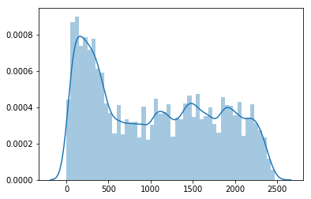

```python
sns.distplot(sessionId.toPandas().dropna());
```

```python
sessionId.describe()
```

```
DataFrame[summary: string, sessionId: string]
```

```python
sessionId.toPandas().dropna().describe()
```

|  | sessionId |
| --- | --- |
| count | 278154.000000 |
| mean | 1042.561624 |
| std | 726.501036 |
| min | 1.000000 |
| 25% | 338.000000 |
| 50% | 1017.000000 |
| 75% | 1675.000000 |
| max | 2474.000000 |

### Distribution of the variable `length`

```python
length = spark.sql('''
        SELECT length
        FROM user_log_table
        ''')
```

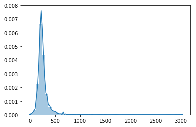

```python
sns.distplot(length.toPandas().dropna());
```

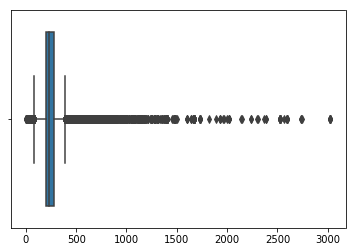

```python
sns.boxplot(length.toPandas().dropna());
```

**Let's find out the start date and the end date of the data records?**

- **Answer** - The dataset has about two months of data from 01st October to 3rd December in the year of 2018.

```python
spark.sql('''
          SELECT min(timeStamp) AS start, max(timeStamp) AS end
          FROM user_log_table
          '''
          ).collect()
```

```
[Row(start='2018-10-01 00:01:57', end='2018-12-03 01:11:16')]
```

#### All data records for the user 77

```python
user77 = spark.sql('''
          SELECT firstname, lastname, page, timeStamp, itemInSession, registration, length, status
          FROM user_log_table
          WHERE userID == '77'
          ORDER BY timeStamp ASC
          '''
          ).collect()
```

```python
user77
```

```
[Row(firstname='Autumn', lastname='Martin', page='Home', timeStamp='2018-10-01 21:02:30', itemInSession=0, registration=1537749786000, length=None, status=200),
 Row(firstname='Autumn', lastname='Martin', page='Home', timeStamp='2018-10-02 06:29:28', itemInSession=0, registration=1537749786000, length=None, status=200),
 Row(firstname='Autumn', lastname='Martin', page='NextSong', timeStamp='2018-10-02 06:30:48', itemInSession=1, registration=1537749786000, length=695.37914, status=200),
 Row(firstname='Autumn', lastname='Martin', page='NextSong', timeStamp='2018-10-02 06:42:23', itemInSession=2, registration=1537749786000, length=236.64281, status=200),
 Row(firstname='Autumn', lastname='Martin', page='NextSong', timeStamp='2018-10-02 06:46:19', itemInSession=3, registration=1537749786000, length=23.2224, status=200),
 Row(firstname='Autumn', lastname='Martin', page='NextSong', timeStamp='2018-10-02 06:46:42', itemInSession=4, registration=1537749786000, length=260.30975, status=200),
 Row(firstname='Autumn', lastname='Martin', page='Home', timeStamp='2018-10-02 06:47:36', itemInSession=5, registration=1537749786000, length=None, status=200),
 Row(firstname='Autumn', lastname='Martin', page='NextSong', timeStamp='2018-10-02 06:51:02', itemInSession=6, registration=1537749786000, length=209.37098, status=200),
 Row(firstname='Autumn', lastname='Martin', page='NextSong', timeStamp='2018-10-02 06:54:31', itemInSession=7, registration=1537749786000, length=221.09995, status=200),
 Row(firstname='Autumn', lastname='Martin', page='Thumbs Up', timeStamp='2018-10-02 06:54:32', itemInSession=8, registration=1537749786000, length=None, status=307),
 Row(firstname='Autumn', lastname='Martin', page='NextSong', timeStamp='2018-10-02 06:58:12', itemInSession=9, registration=1537749786000, length=123.48036, status=200),
 Row(firstname='Autumn', lastname='Martin', page='NextSong', timeStamp='2018-10-02 07:00:15', itemInSession=10, registration=1537749786000, length=255.65995, status=200),
 Row(firstname='Autumn', lastname='Martin', page='NextSong', timeStamp='2018-10-02 07:04:30', itemInSession=11, registration=1537749786000, length=250.27873, status=200),
 Row(firstname='Autumn', lastname='Martin', page='NextSong', timeStamp='2018-10-02 07:08:40', itemInSession=12, registration=1537749786000, length=212.50567, status=200),
 Row(firstname='Autumn', lastname='Martin', page='NextSong', timeStamp='2018-10-02 07:12:12', itemInSession=13, registration=1537749786000, length=277.10649, status=200),
 Row(firstname='Autumn', lastname='Martin', page='NextSong', timeStamp='2018-10-02 07:16:49', itemInSession=14, registration=1537749786000, length=205.19138, status=200),
 Row(firstname='Autumn', lastname='Martin', page='NextSong', timeStamp='2018-10-02 07:20:14', itemInSession=15, registration=1537749786000, length=224.54812, status=200),
 Row(firstname='Autumn', lastname='Martin', page='NextSong', timeStamp='2018-10-02 07:23:58', itemInSession=16, registration=1537749786000, length=242.18077, status=200),
 Row(firstname='Autumn', lastname='Martin', page='NextSong', timeStamp='2018-10-02 07:28:00', itemInSession=17, registration=1537749786000, length=220.89098, status=200),
 Row(firstname='Autumn', lastname='Martin', page='NextSong', timeStamp='2018-10-02 07:31:40', itemInSession=18, registration=1537749786000, length=262.79138, status=200),
 Row(firstname='Autumn', lastname='Martin', page='NextSong', timeStamp='2018-10-02 07:36:02', itemInSession=19, registration=1537749786000, length=294.37342, status=200),
 Row(firstname='Autumn', lastname='Martin', page='Thumbs Up', timeStamp='2018-10-02 07:36:03', itemInSession=20, registration=1537749786000, length=None, status=307),
 Row(firstname='Autumn', lastname='Martin', page='NextSong', timeStamp='2018-10-02 07:40:56', itemInSession=21, registration=1537749786000, length=227.36934, status=200),
 Row(firstname='Autumn', lastname='Martin', page='NextSong', timeStamp='2018-10-02 07:44:43', itemInSession=22, registration=1537749786000, length=245.36771, status=200),
 Row(firstname='Autumn', lastname='Martin', page='NextSong', timeStamp='2018-10-02 07:48:48', itemInSession=23, registration=1537749786000, length=233.74322, status=200),
 Row(firstname='Autumn', lastname='Martin', page='NextSong', timeStamp='2018-10-02 07:52:41', itemInSession=24, registration=1537749786000, length=294.97424, status=200),
```

[output cut: 975 more lines]

```python
# Pages visited by the users at Sparkify.org
spark.sql('''
          SELECT DISTINCT page
          FROM user_log_table
          ORDER BY page ASC
          '''
          ).show()
```

```
+--------------------+
|                page|
+--------------------+
|               About|
|          Add Friend|
|     Add to Playlist|
|              Cancel|
|Cancellation Conf...|
|           Downgrade|
|               Error|
|                Help|
|                Home|
|              Logout|
|            NextSong|
|         Roll Advert|
|       Save Settings|
|            Settings|
|    Submit Downgrade|
|      Submit Upgrade|
|         Thumbs Down|
|           Thumbs Up|
|             Upgrade|
+--------------------+
```

```python
# Similarly using dataframe
df_clean.select("page").dropDuplicates().sort("page").show()
```

```
+--------------------+
|                page|
+--------------------+
|               About|
|          Add Friend|
|     Add to Playlist|
|              Cancel|
|Cancellation Conf...|
|           Downgrade|
|               Error|
|                Help|
|                Home|
|              Logout|
|            NextSong|
|         Roll Advert|
|       Save Settings|
|            Settings|
|    Submit Downgrade|
|      Submit Upgrade|
|         Thumbs Down|
|           Thumbs Up|
|             Upgrade|
+--------------------+
```

```python
# Pages visited by the users at Sparkify.org
spark.sql('''
          SELECT DISTINCT page
          FROM user_log_table
          ORDER BY page ASC
          '''
          ).show()
```

```
+--------------------+
|                page|
+--------------------+
|               About|
|          Add Friend|
|     Add to Playlist|
|              Cancel|
|Cancellation Conf...|
|           Downgrade|
|               Error|
|                Help|
|                Home|
|              Logout|
|            NextSong|
|         Roll Advert|
|       Save Settings|
|            Settings|
|    Submit Downgrade|
|      Submit Upgrade|
|         Thumbs Down|
|           Thumbs Up|
|             Upgrade|
+--------------------+
```

The `Cancellation Confirmation` page is where a user is directed after they have confirmed their decision to cancel their service which makes it essential to identify the churn.

```python
# Let's check how many users have cancelled the service or not

spark.sql('''
        SELECT auth, COUNT(userId) AS No_of_Users
        FROM user_log_table
        GROUP BY auth
        ORDER BY No_of_Users DESC
        '''
         ).show()
```

```
+---------+-----------+
|     auth|No_of_Users|
+---------+-----------+
|Logged In|     278102|
|Cancelled|         52|
+---------+-----------+
```

```python
df_clean.select(["userId", "page"]).where(df_clean.page == "Cancellation Confirmation").count() # Num of users got churned
```

```
52
```

So, out of total **278,154** records in this dataset, and the variable auth flags **52** thus cancelled.

How many records show that the user have visited the page `Cancellation Confirmation` ?

```python
spark.sql('''
        SELECT page,COUNT(userId) AS No_of_Users
        FROM user_log_table
        GROUP BY page
        ORDER BY No_of_Users ASC
''').show()
```

```
+--------------------+-----------+
|                page|No_of_Users|
+--------------------+-----------+
|Cancellation Conf...|         52|
|              Cancel|         52|
|    Submit Downgrade|         63|
|      Submit Upgrade|        159|
|               Error|        252|
|       Save Settings|        310|
|               About|        495|
|             Upgrade|        499|
|                Help|       1454|
|            Settings|       1514|
|           Downgrade|       2055|
|         Thumbs Down|       2546|
|              Logout|       3226|
|         Roll Advert|       3933|
|          Add Friend|       4277|
|     Add to Playlist|       6526|
|                Home|      10082|
|           Thumbs Up|      12551|
|            NextSong|     228108|
+--------------------+-----------+
```

```python
spark.sql('''
        SELECT page,COUNT(userId) AS No_of_Users
        FROM user_log_table
        GROUP BY page
        ORDER BY No_of_Users ASC
''').show()
```

```
+--------------------+-----------+
|                page|No_of_Users|
+--------------------+-----------+
|Cancellation Conf...|         52|
|              Cancel|         52|
|    Submit Downgrade|         63|
|      Submit Upgrade|        159|
|               Error|        252|
|       Save Settings|        310|
|               About|        495|
|             Upgrade|        499|
|                Help|       1454|
|            Settings|       1514|
|           Downgrade|       2055|
|         Thumbs Down|       2546|
|              Logout|       3226|
|         Roll Advert|       3933|
|          Add Friend|       4277|
|     Add to Playlist|       6526|
|                Home|      10082|
|           Thumbs Up|      12551|
|            NextSong|     228108|
+--------------------+-----------+
```

Let us examine the 52 records in which the variable page indicates a `Cancellation Confirmation`. Does the variable `auth` indicate **cancelled** for those records?

```python
df_cancelled = spark.sql('''
          SELECT userId, firstname, lastname, page, timeStamp, auth, level, memberSince
          FROM user_log_table
          WHERE page == 'Cancellation Confirmation'
          ORDER BY  memberSince DESC
          '''
         ).toPandas()
```

```python
df_cancelled
```

|  | userId | firstname | lastname | page | timeStamp | auth | level | memberSince |
| --- | --- | --- | --- | --- | --- | --- | --- | --- |
| 0 | 300001 | Antonina | Kennedy | Cancellation Confirmation | 2018-11-23 21:42:24 | Cancelled | paid | 188 |
| 1 | 70 | Chayse | Keller | Cancellation Confirmation | 2018-11-14 22:34:27 | Cancelled | paid | 145 |
| 2 | 121 | Nikolas | Olsen | Cancellation Confirmation | 2018-10-17 07:02:29 | Cancelled | paid | 131 |
| 3 | 100007 | Piper | Cook | Cancellation Confirmation | 2018-11-29 11:45:09 | Cancelled | paid | 115 |
| 4 | 54 | Alexi | Warren | Cancellation Confirmation | 2018-11-12 19:40:08 | Cancelled | paid | 110 |
| 5 | 200011 | Charles | Harper | Cancellation Confirmation | 2018-11-02 01:09:24 | Cancelled | free | 109 |
| 6 | 100025 | London | Diaz | Cancellation Confirmation | 2018-10-23 12:52:32 | Cancelled | free | 88 |
| 7 | 200015 | Connor | Mendoza | Cancellation Confirmation | 2018-11-09 07:01:03 | Cancelled | free | 87 |
| 8 | 100005 | Cason | Smith | Cancellation Confirmation | 2018-10-19 17:57:05 | Cancelled | free | 85 |
| 9 | 100014 | Rodrigo | Carey | Cancellation Confirmation | 2018-11-20 19:04:09 | Cancelled | paid | 85 |
| 10 | 3 | Jeffery | Wheeler | Cancellation Confirmation | 2018-10-30 04:59:03 | Cancelled | paid | 80 |
| 11 | 100017 | James | Mann | Cancellation Confirmation | 2018-10-20 19:14:07 | Cancelled | free | 78 |
| 12 | 200020 | Keegan | Rivera | Cancellation Confirmation | 2018-11-17 16:40:42 | Cancelled | free | 75 |
| 13 | 12 | Sophia | Perry | Cancellation Confirmation | 2018-10-22 07:29:34 | Cancelled | paid | 73 |
| 14 | 125 | Mason | Hart | Cancellation Confirmation | 2018-10-12 04:35:18 | Cancelled | free | 71 |
| 15 | 200021 | Liliana | Owen | Cancellation Confirmation | 2018-11-02 05:58:53 | Cancelled | paid | 70 |
| 16 | 100015 | Tina | Thompson | Cancellation Confirmation | 2018-11-24 15:35:53 | Cancelled | paid | 67 |
| 17 | 100021 | Rayden | Phillips | Cancellation Confirmation | 2018-11-25 11:03:02 | Cancelled | free | 64 |
| 18 | 143 | Molly | Harrison | Cancellation Confirmation | 2018-10-15 07:34:14 | Cancelled | free | 61 |
| 19 | 29 | Kaleb | Thompson | Cancellation Confirmation | 2018-11-14 07:37:11 | Cancelled | paid | 60 |
| 20 | 200017 | James | Dickerson | Cancellation Confirmation | 2018-11-15 20:16:43 | Cancelled | paid | 60 |
| 21 | 87 | Christian | Robinson | Cancellation Confirmation | 2018-10-20 15:49:16 | Cancelled | paid | 59 |
| 22 | 200016 | Charlotte | Frazier | Cancellation Confirmation | 2018-11-16 08:17:58 | Cancelled | free | 55 |
| 23 | 101 | Alex | Hogan | Cancellation Confirmation | 2018-10-16 22:30:37 | Cancelled | paid | 53 |
| 24 | 53 | Sebastian | Wang | Cancellation Confirmation | 2018-11-19 12:34:56 | Cancelled | paid | 53 |
| 25 | 122 | Molly | Patterson | Cancellation Confirmation | 2018-10-20 19:01:08 | Cancelled | paid | 52 |
| 26 | 73 | Rachel | Bailey | Cancellation Confirmation | 2018-10-24 17:33:07 | Cancelled | paid | 49 |
| 27 | 200018 | Saulo | Burgess | Cancellation Confirmation | 2018-11-02 10:07:54 | Cancelled | free | 48 |
| 28 | 100022 | Mahi | Robinson | Cancellation Confirmation | 2018-11-12 16:04:05 | Cancelled | free | 47 |
| 29 | 28 | Teagan | Roberts | Cancellation Confirmation | 2018-11-06 00:20:32 | Cancelled | paid | 44 |
| 30 | 100001 | Delaney | Perez | Cancellation Confirmation | 2018-10-02 16:36:45 | Cancelled | free | 44 |
| 31 | 100013 | Cali | Brown | Cancellation Confirmation | 2018-11-02 18:53:36 | Cancelled | paid | 44 |
| 32 | 100012 | Daniel | Marks | Cancellation Confirmation | 2018-11-01 19:35:00 | Cancelled | free | 43 |
| 33 | 103 | Piper | Nielsen | Cancellation Confirmation | 2018-11-04 14:01:31 | Cancelled | paid | 42 |
| 34 | 106 | Sophia | Key | Cancellation Confirmation | 2018-11-02 13:47:04 | Cancelled | paid | 40 |
| 35 | 18 | Adriel | Mendoza | Cancellation Confirmation | 2018-10-07 20:26:30 | Cancelled | paid | 38 |
| 36 | 100009 | Troy | Mathis | Cancellation Confirmation | 2018-10-27 03:31:44 | Cancelled | free | 37 |
| 37 | 100023 | Sawyer | Nelson | Cancellation Confirmation | 2018-10-14 00:00:37 | Cancelled | paid | 32 |
| 38 | 100019 | Angel | Jacobs | Cancellation Confirmation | 2018-10-07 22:57:51 | Cancelled | free | 31 |
| 39 | 105 | Alexander | Garcia | Cancellation Confirmation | 2018-10-12 20:17:21 | Cancelled | paid | 29 |
| 40 | 200024 | Isaiah | Gomez | Cancellation Confirmation | 2018-10-24 03:59:37 | Cancelled | paid | 28 |
| 41 | 100024 | Jonathon | Miller | Cancellation Confirmation | 2018-10-04 23:17:18 | Cancelled | free | 27 |
| 42 | 58 | Erick | Brooks | Cancellation Confirmation | 2018-10-22 15:43:26 | Cancelled | paid | 26 |
| 43 | 100003 | Nevaeh | Jones | Cancellation Confirmation | 2018-10-11 16:19:41 | Cancelled | free | 22 |
| 44 | 32 | Diego | Mckee | Cancellation Confirmation | 2018-10-08 21:10:46 | Cancelled | paid | 21 |
| 45 | 51 | Ethan | Johnson | Cancellation Confirmation | 2018-10-17 07:39:32 | Cancelled | paid | 19 |
| 46 | 129 | Davis | Wang | Cancellation Confirmation | 2018-10-17 00:29:21 | Cancelled | paid | 16 |
| 47 | 200001 | Reece | Moore | Cancellation Confirmation | 2018-10-15 18:55:20 | Cancelled | free | 15 |
| 48 | 17 | Kayla | Johnson | Cancellation Confirmation | 2018-10-13 21:19:44 | Cancelled | paid | 13 |
| 49 | 300007 | Lucas | Franklin | Cancellation Confirmation | 2018-10-05 02:08:58 | Cancelled | paid | 11 |
| 50 | 100006 | Leyla | Barnes | Cancellation Confirmation | 2018-10-05 15:24:30 | Cancelled | free | 9 |
| 51 | 100011 | Sebastian | Ball | Cancellation Confirmation | 2018-10-01 18:04:45 | Cancelled | free | 5 |

```python
df_cancelled["memberSince"] = pd.to_numeric(df_cancelled["memberSince"])
```

```python
df_cancelled["memberSince"].describe()
```

```
count     52.000000
mean      56.807692
std       36.602817
min        5.000000
25%       30.500000
50%       50.500000
75%       73.500000
max      188.000000
Name: memberSince, dtype: float64
```

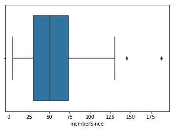

```python
sns.boxplot(df_cancelled["memberSince"]);
```

# Exploratory Data Analysis (EDA)

When you're working with the full dataset, perform EDA by loading a small subset of the data and doing basic manipulations within Spark. In this workspace, you are already provided a small subset of data you can explore.

### Define Churn

Once you've done some preliminary analysis, create a column `Churn` to use as the label for your model. I suggest using the `Cancellation Confirmation` events to define your churn, which happen for both paid and free users. As a bonus task, you can also look into the `Downgrade` events.

```python
df_clean_backup = df_clean
df_clean_backup
```

```
DataFrame[artist: string, auth: string, firstName: string, gender: string, itemInSession: bigint, lastName: string, length: double, level: string, location: string, method: string, page: string, registration: bigint, sessionId: bigint, song: string, status: bigint, ts: bigint, userAgent: string, use…
```

```python
df_clean = df_clean_backup
```

```python
# Creating a flag where if users get churned then 1 else 0
churnEvent = udf(lambda page: 1 if page == "Cancellation Confirmation" else 0, IntegerType())
```

```python
# Adding coloumn `isChurn` to df_clean
df_clean = df_clean.withColumn("isChurn", churnEvent("page"))
```

```python
df_clean.dtypes
```

```
[('artist', 'string'),
 ('auth', 'string'),
 ('firstName', 'string'),
 ('gender', 'string'),
 ('itemInSession', 'bigint'),
 ('lastName', 'string'),
 ('length', 'double'),
 ('level', 'string'),
 ('location', 'string'),
 ('method', 'string'),
 ('page', 'string'),
 ('registration', 'bigint'),
 ('sessionId', 'bigint'),
 ('song', 'string'),
 ('status', 'bigint'),
 ('ts', 'bigint'),
 ('userAgent', 'string'),
 ('userId', 'string'),
 ('timeStamp', 'string'),
 ('registration_timeStamp', 'string'),
 ('memberSince', 'int'),
 ('isChurn', 'int')]
```

```python
# show summary statistics for the new variable
df_clean.describe('isChurn').show()
```

```
+-------+--------------------+
|summary|             isChurn|
+-------+--------------------+
|  count|              278154|
|   mean|1.869467992550889E-4|
| stddev|0.013671595449116171|
|    min|                   0|
|    max|                   1|
+-------+--------------------+
```

```python
df_clean.dtypes
```

```
[('artist', 'string'),
 ('auth', 'string'),
 ('firstName', 'string'),
 ('gender', 'string'),
 ('itemInSession', 'bigint'),
 ('lastName', 'string'),
 ('length', 'double'),
 ('level', 'string'),
 ('location', 'string'),
 ('method', 'string'),
 ('page', 'string'),
 ('registration', 'bigint'),
 ('sessionId', 'bigint'),
 ('song', 'string'),
 ('status', 'bigint'),
 ('ts', 'bigint'),
 ('userAgent', 'string'),
 ('userId', 'string'),
 ('timeStamp', 'string'),
 ('registration_timeStamp', 'string'),
 ('memberSince', 'int'),
 ('isChurn', 'int')]
```

```python
df_usr_churn = df_clean.select(['userId', 'isChurn']).dropDuplicates().groupBy('isChurn').count()
df_usr_churn
```

```
DataFrame[isChurn: int, count: bigint]
```

```python
# Good Old Pandas Dataframe
df_usr_churn = df_usr_churn.toPandas()
df_usr_churn
```

|  | isChurn | count |
| --- | --- | --- |
| 0 | 1 | 52 |
| 1 | 0 | 225 |

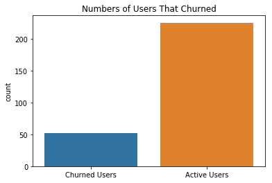

```python
churn_sorted  = df_usr_churn.sort_values(by='count')
churn_sorted.index = ["Churned Users", "Active Users"]
sns.barplot(churn_sorted.index, data = df_usr_churn, y='count')
plt.title("Numbers of Users That Churned");
```

```python
# Updating temporary view
df_clean.createOrReplaceTempView("user_log_table")
```

```python
df_clean
```

```
DataFrame[artist: string, auth: string, firstName: string, gender: string, itemInSession: bigint, lastName: string, length: double, level: string, location: string, method: string, page: string, registration: bigint, sessionId: bigint, song: string, status: bigint, ts: bigint, userAgent: string, use…
```

```python
# Looking at the churned users
spark.sql('''
          SELECT userId, firstname, lastname, page, timeStamp, auth, level, isChurn
          FROM user_log_table
          WHERE isChurn == 1
          ORDER BY  timeStamp DESC
          '''
         ).show()
```

```
+------+---------+---------+--------------------+-------------------+---------+-----+-------+
|userId|firstname| lastname|                page|          timeStamp|     auth|level|isChurn|
+------+---------+---------+--------------------+-------------------+---------+-----+-------+
|100007|    Piper|     Cook|Cancellation Conf...|2018-11-29 11:45:09|Cancelled| paid|      1|
|100021|   Rayden| Phillips|Cancellation Conf...|2018-11-25 11:03:02|Cancelled| free|      1|
|100015|     Tina| Thompson|Cancellation Conf...|2018-11-24 15:35:53|Cancelled| paid|      1|
|300001| Antonina|  Kennedy|Cancellation Conf...|2018-11-23 21:42:24|Cancelled| paid|      1|
|100014|  Rodrigo|    Carey|Cancellation Conf...|2018-11-20 19:04:09|Cancelled| paid|      1|
|    53|Sebastian|     Wang|Cancellation Conf...|2018-11-19 12:34:56|Cancelled| paid|      1|
|200020|   Keegan|   Rivera|Cancellation Conf...|2018-11-17 16:40:42|Cancelled| free|      1|
|200016|Charlotte|  Frazier|Cancellation Conf...|2018-11-16 08:17:58|Cancelled| free|      1|
|200017|    James|Dickerson|Cancellation Conf...|2018-11-15 20:16:43|Cancelled| paid|      1|
|    70|   Chayse|   Keller|Cancellation Conf...|2018-11-14 22:34:27|Cancelled| paid|      1|
|    29|    Kaleb| Thompson|Cancellation Conf...|2018-11-14 07:37:11|Cancelled| paid|      1|
|    54|    Alexi|   Warren|Cancellation Conf...|2018-11-12 19:40:08|Cancelled| paid|      1|
|100022|     Mahi| Robinson|Cancellation Conf...|2018-11-12 16:04:05|Cancelled| free|      1|
|200015|   Connor|  Mendoza|Cancellation Conf...|2018-11-09 07:01:03|Cancelled| free|      1|
|    28|   Teagan|  Roberts|Cancellation Conf...|2018-11-06 00:20:32|Cancelled| paid|      1|
|   103|    Piper|  Nielsen|Cancellation Conf...|2018-11-04 14:01:31|Cancelled| paid|      1|
|100013|     Cali|    Brown|Cancellation Conf...|2018-11-02 18:53:36|Cancelled| paid|      1|
|   106|   Sophia|      Key|Cancellation Conf...|2018-11-02 13:47:04|Cancelled| paid|      1|
|200018|    Saulo|  Burgess|Cancellation Conf...|2018-11-02 10:07:54|Cancelled| free|      1|
|200021|  Liliana|     Owen|Cancellation Conf...|2018-11-02 05:58:53|Cancelled| paid|      1|
+------+---------+---------+--------------------+-------------------+---------+-----+-------+
only showing top 20 rows
```

Now we'll define a new variable `Churn` that contains all of the records of users who later cancel the service. We may use a SQL windows function to find the maximum value of the `isChurn` variable for each `userId`

```python
# SQL query with a Windows function enabled
spark.sql('''
          SELECT userId, max(isChurn)
          OVER (PARTITION BY userId)
          FROM user_log_table
          ORDER BY  timeStamp
          '''
         ).show()
```

```
+------+------------------------------------------------------------------------------------------------+
|userId|max(isChurn) OVER (PARTITION BY userId ROWS BETWEEN UNBOUNDED PRECEDING AND UNBOUNDED FOLLOWING)|
+------+------------------------------------------------------------------------------------------------+
|    30|                                                                                               0|
|     9|                                                                                               0|
|    30|                                                                                               0|
|     9|                                                                                               0|
|    30|                                                                                               0|
|     9|                                                                                               0|
|     9|                                                                                               0|
|    30|                                                                                               0|
|    30|                                                                                               0|
|    30|                                                                                               0|
|     9|                                                                                               0|
|     9|                                                                                               0|
|    30|                                                                                               0|
|     9|                                                                                               0|
|     9|                                                                                               0|
|    30|                                                                                               0|
|     9|                                                                                               0|
|    74|                                                                                               0|
|    30|                                                                                               0|
|     9|                                                                                               0|
+------+------------------------------------------------------------------------------------------------+
only showing top 20 rows
```

```python
usrWindow = Window \
    .partitionBy('userId') \
    .orderBy(desc('ts')) \
    .rangeBetween(Window.unboundedPreceding, Window.unboundedFollowing)
```

```python
df_clean_backuo02 = df_clean
```

```python
df_clean = df_clean.withColumn('Churn', max('isChurn').over(usrWindow))
```

```python
df_clean.describe('Churn').show()
```

```
+-------+-------------------+
|summary|              Churn|
+-------+-------------------+
|  count|             278154|
|   mean|0.16129194618808287|
| stddev|0.36780068056308857|
|    min|                  0|
|    max|                  1|
+-------+-------------------+
```

Approx **16%** of the records in the given dataset belong to churned users

### Explore Data

Once you've defined churn, perform some exploratory data analysis to observe the behavior for users who stayed vs users who churned. You can start by exploring aggregates on these two groups of users, observing how much of a specific action they experienced per a certain time unit or number of songs played.

```python
df_clean.createOrReplaceTempView("user_log_table")
```

### Users who `downgrade` their accounts

```python
spark.sql('''
          SELECT COUNT(DISTINCT userId)
          FROM user_log_table
          WHERE page == 'Downgrade'

          '''
         ).show()
```

```
+----------------------+
|count(DISTINCT userId)|
+----------------------+
|                   154|
+----------------------+
```

```python
spark.sql('''
          SELECT COUNT(DISTINCT userId)
          FROM user_log_table
          '''
         ).show()
```

```
+----------------------+
|count(DISTINCT userId)|
+----------------------+
|                   225|
+----------------------+
```

**68%** (154/225) of users visit the downgrade page at some point.

**How many people submit the downgrade?**

```python
spark.sql('''
          SELECT COUNT(DISTINCT userId)
          FROM user_log_table
          WHERE page == 'Submit Downgrade'

          '''
         ).show()
```

```
+----------------------+
|count(DISTINCT userId)|
+----------------------+
|                    49|
+----------------------+
```

```python
225 - 154
```

```
71
```

**How many users downgrade and finally churn from the service?**

```python
spark.sql('''
          SELECT Churn, COUNT(DISTINCT userId) AS Submit_Downgrade
          FROM user_log_table
          WHERE page == 'Submit Downgrade'
          GROUP BY Churn

          '''
         ).show()
```

```
+-----+----------------+
|Churn|Submit_Downgrade|
+-----+----------------+
|    1|               9|
|    0|              40|
+-----+----------------+
```

```python
spark.sql('''
          SELECT DISTINCT userId, page, Churn, level
          FROM user_log_table
          WHERE page == 'Submit Downgrade' OR page == 'Cancellation Confirmation'
          ORDER BY userId

          '''
         ).show(50)
```

```
+------+--------------------+-----+-----+
|userId|                page|Churn|level|
+------+--------------------+-----+-----+
|   100|    Submit Downgrade|    0| paid|
|100001|Cancellation Conf...|    1| free|
|100003|Cancellation Conf...|    1| free|
|100004|    Submit Downgrade|    0| paid|
|100005|Cancellation Conf...|    1| free|
|100006|Cancellation Conf...|    1| free|
|100007|Cancellation Conf...|    1| paid|
|100008|    Submit Downgrade|    0| paid|
|100009|Cancellation Conf...|    1| free|
|100009|    Submit Downgrade|    1| paid|
|100011|Cancellation Conf...|    1| free|
|100012|    Submit Downgrade|    1| paid|
|100012|Cancellation Conf...|    1| free|
|100013|Cancellation Conf...|    1| paid|
|100014|Cancellation Conf...|    1| paid|
|100015|Cancellation Conf...|    1| paid|
|100015|    Submit Downgrade|    1| paid|
|100016|    Submit Downgrade|    0| paid|
|100017|Cancellation Conf...|    1| free|
|100018|    Submit Downgrade|    0| paid|
|100019|Cancellation Conf...|    1| free|
|100021|Cancellation Conf...|    1| free|
|100022|Cancellation Conf...|    1| free|
|100023|Cancellation Conf...|    1| paid|
|100024|Cancellation Conf...|    1| free|
|100025|Cancellation Conf...|    1| free|
|100025|    Submit Downgrade|    1| paid|
|   101|Cancellation Conf...|    1| paid|
|   103|Cancellation Conf...|    1| paid|
|   103|    Submit Downgrade|    1| paid|
|   105|Cancellation Conf...|    1| paid|
|   106|Cancellation Conf...|    1| paid|
|   109|    Submit Downgrade|    0| paid|
|    11|    Submit Downgrade|    0| paid|
|    12|Cancellation Conf...|    1| paid|
|    12|    Submit Downgrade|    1| paid|
|   121|Cancellation Conf...|    1| paid|
|   122|Cancellation Conf...|    1| paid|
|   125|Cancellation Conf...|    1| free|
|   129|Cancellation Conf...|    1| paid|
|    13|    Submit Downgrade|    0| paid|
|   131|    Submit Downgrade|    0| paid|
|   140|    Submit Downgrade|    0| paid|
|   141|    Submit Downgrade|    0| paid|
|   143|Cancellation Conf...|    1| free|
|    17|Cancellation Conf...|    1| paid|
|    18|Cancellation Conf...|    1| paid|
|    20|    Submit Downgrade|    0| paid|
|200001|Cancellation Conf...|    1| free|
|200003|    Submit Downgrade|    0| paid|
+------+--------------------+-----+-----+
only showing top 50 rows
```

```python
df_clean.filter("page = 'Submit Downgrade'").show()
```

```
+------+---------+----------+------+-------------+---------+------+-----+--------------------+------+----------------+-------------+---------+----+------+-------------+--------------------+------+-------------------+----------------------+-----------+-------+-----+
|artist|     auth| firstName|gender|itemInSession| lastName|length|level|            location|method|            page| registration|sessionId|song|status|           ts|           userAgent|userId|          timeStamp|registration_timeStamp|memberSince|isChurn|Churn|
+------+---------+----------+------+-------------+---------+------+-----+--------------------+------+----------------+-------------+---------+----+------+-------------+--------------------+------+-------------------+----------------------+-----------+-------+-----+
|  null|Logged In|     Alexi|     F|           41|   Warren|  null| paid|Spokane-Spokane V...|   PUT|Submit Downgrade|1532482662000|      859|null|   307|1539608060000|Mozilla/5.0 (Wind...|    54|2018-10-15 12:54:20|   2018-07-25 01:37:42|         82|      0|    1|
|  null|Logged In|       Zoe|     F|           23|    Patel|  null| paid|Providence-Warwic...|   PUT|Submit Downgrade|1532554781000|      487|null|   307|1539239742000|Mozilla/5.0 (Wind...|    11|2018-10-11 06:35:42|   2018-07-25 21:39:41|         77|      0|    0|
|  null|Logged In|     Colin|     M|          214|  Freeman|  null| paid|     Bakersfield, CA|   PUT|Submit Downgrade|1538173362000|      532|null|   307|1538995454000|Mozilla/5.0 (Wind...|    30|2018-10-08 10:44:14|   2018-09-28 22:22:42|          9|      0|    0|
|  null|Logged In|    Jaleel|     M|          180|Maldonado|  null| paid|         Boulder, CO|   PUT|Submit Downgrade|1537890437000|      510|null|   307|1539633167000|Mozilla/5.0 (Wind...|    59|2018-10-15 19:52:47|   2018-09-25 15:47:17|         20|      0|    0|
|  null|Logged In|   Brayden|     M|          105|   Thomas|  null| paid|Los Angeles-Long ...|   PUT|Submit Downgrade|1534133898000|     1183|null|   307|1540383285000|"Mozilla/5.0 (Mac...|    85|2018-10-24 12:14:45|   2018-08-13 04:18:18|         72|      0|    0|
|  null|Logged In|   Brayden|     M|          113|   Thomas|  null| paid|Los Angeles-Long ...|   PUT|Submit Downgrade|1534133898000|      734|null|   307|1539335599000|"Mozilla/5.0 (Mac...|    85|2018-10-12 09:13:19|   2018-08-13 04:18:18|         60|      0|    0|
|  null|Logged In|      Lily|     F|            7|  Barnett|  null| paid|Washington-Arling...|   PUT|Submit Downgrade|1537053412000|     1704|null|   307|1541619996000|"Mozilla/5.0 (Mac...|    35|2018-11-07 19:46:36|   2018-09-15 23:16:52|         52|      0|    0|
|  null|Logged In|      Lily|     F|           69|  Barnett|  null| paid|Washington-Arling...|   PUT|Submit Downgrade|1537053412000|      812|null|   307|1539467798000|"Mozilla/5.0 (Mac...|    35|2018-10-13 21:56:38|   2018-09-15 23:16:52|         27|      0|    0|
|  null|Logged In|   Bryanna|     F|          565|    Stone|  null| paid|Los Angeles-Long ...|   PUT|Submit Downgrade|1537440271000|      132|null|   307|1542748901000|Mozilla/5.0 (Maci...|100008|2018-11-20 21:21:41|   2018-09-20 10:44:31|         61|      0|    0|
|  null|Logged In|    London|     F|          224|     Diaz|  null| paid|New York-Newark-J...|   PUT|Submit Downgrade|1532625569000|      123|null|   307|1539968728000|"Mozilla/5.0 (Mac...|100025|2018-10-19 17:05:28|   2018-07-26 17:19:29|         84|      0|    1|
|  null|Logged In|    Lindyn|     F|           29|    Patel|  null| paid|Truckee-Grass Val...|   PUT|Submit Downgrade|1532589384000|      220|null|   307|1540236417000|Mozilla/5.0 (Maci...|300002|2018-10-22 19:26:57|   2018-07-26 07:16:24|         88|      0|    0|
|  null|Logged In|Alexandria|     F|           78|    Mills|  null| paid|Atlantic City-Ham...|   PUT|Submit Downgrade|1537149749000|     1689|null|   307|1541722970000|"Mozilla/5.0 (Mac...|    96|2018-11-09 00:22:50|   2018-09-17 02:02:29|         52|      0|    0|
|  null|Logged In|     Colin|     M|          203|   Larson|  null| paid|Dallas-Fort Worth...|   PUT|Submit Downgrade|1537982255000|     1590|null|   307|1541367880000|Mozilla/5.0 (Wind...|   100|2018-11-04 21:44:40|   2018-09-26 17:17:35|         39|      0|    0|
```

[output cut: 9 more lines]

```python
df_clean.select(["userId", "firstname", "page", "level", "song"]).where(df_clean.userId == "77").collect()
```

```
[Row(userId='77', firstname='Autumn', page='Home', level='paid', song=None),
 Row(userId='77', firstname='Autumn', page='Home', level='paid', song=None),
 Row(userId='77', firstname='Autumn', page='NextSong', level='paid', song="Wilton's Boogaloo (2005 Digital Remaster)"),
 Row(userId='77', firstname='Autumn', page='NextSong', level='paid', song='The Slow Descent Into Alcoholism'),
 Row(userId='77', firstname='Autumn', page='NextSong', level='paid', song='Planet of Women'),
 Row(userId='77', firstname='Autumn', page='NextSong', level='paid', song='Someday'),
 Row(userId='77', firstname='Autumn', page='Home', level='paid', song=None),
 Row(userId='77', firstname='Autumn', page='NextSong', level='paid', song='Rain'),
 Row(userId='77', firstname='Autumn', page='NextSong', level='paid', song='Jambalaya'),
 Row(userId='77', firstname='Autumn', page='Thumbs Up', level='paid', song=None),
 Row(userId='77', firstname='Autumn', page='NextSong', level='paid', song='Bye Bye Blues (1990 Digital Remaster)'),
 Row(userId='77', firstname='Autumn', page='NextSong', level='paid', song='Home'),
 Row(userId='77', firstname='Autumn', page='NextSong', level='paid', song='Up From Below'),
 Row(userId='77', firstname='Autumn', page='NextSong', level='paid', song="You're Easy On The Eyes"),
 Row(userId='77', firstname='Autumn', page='NextSong', level='paid', song='You'),
 Row(userId='77', firstname='Autumn', page='NextSong', level='paid', song='Lotus Flower'),
 Row(userId='77', firstname='Autumn', page='NextSong', level='paid', song='To My'),
 Row(userId='77', firstname='Autumn', page='NextSong', level='paid', song='Perdona'),
 Row(userId='77', firstname='Autumn', page='NextSong', level='paid', song='When You Were Young'),
 Row(userId='77', firstname='Autumn', page='NextSong', level='paid', song='My Immortal'),
 Row(userId='77', firstname='Autumn', page='NextSong', level='paid', song='Devotion And Desire'),
 Row(userId='77', firstname='Autumn', page='Thumbs Up', level='paid', song=None),
 Row(userId='77', firstname='Autumn', page='NextSong', level='paid', song='Under Pressure'),
 Row(userId='77', firstname='Autumn', page='NextSong', level='paid', song='Eye Of The Tiger'),
 Row(userId='77', firstname='Autumn', page='NextSong', level='paid', song='Kryptonite'),
 Row(userId='77', firstname='Autumn', page='NextSong', level='paid', song='The Headmaster Ritual'),
 Row(userId='77', firstname='Autumn', page='NextSong', level='paid', song="You're The One"),
 Row(userId='77', firstname='Autumn', page='NextSong', level='paid', song='Nightshift'),
 Row(userId='77', firstname='Autumn', page='NextSong', level='paid', song='Clenched Fist (Album Version)'),
 Row(userId='77', firstname='Autumn', page='NextSong', level='paid', song='Horn Concerto No. 4 in E flat K495: II. Romance (Andante cantabile)'),
 Row(userId='77', firstname='Autumn', page='NextSong', level='paid', song='Hey Ma'),
 Row(userId='77', firstname='Autumn', page='NextSong', level='paid', song='All We Have Broken Shines'),
 Row(userId='77', firstname='Autumn', page='NextSong', level='paid', song='El Toro Pesado'),
 Row(userId='77', firstname='Autumn', page='NextSong', level='paid', song='Boy In A Rock And Roll Band'),
 Row(userId='77', firstname='Autumn', page='NextSong', level='paid', song="If You're Gone (Remastered Version)"),
 Row(userId='77', firstname='Autumn', page='NextSong', level='paid', song='Catch You Baby (Steve Pitron & Max Sanna Radio Edit)'),
 Row(userId='77', firstname='Autumn', page='NextSong', level='paid', song="It's Been Awhile (Clean Edit)"),
 Row(userId='77', firstname='Autumn', page='NextSong', level='paid', song='Dizzy'),
 Row(userId='77', firstname='Autumn', page='NextSong', level='paid', song='For Once In My Life (Album Version)'),
 Row(userId='77', firstname='Autumn', page='NextSong', level='paid', song='It Had To Be You (Big Band and Vocals)'),
```

[output cut: 946 more lines]

```
 Row(userId='77', firstname='Autumn', page='NextSong', level='paid', song="Ain't Misbehavin"),
 Row(userId='77', firstname='Autumn', page='NextSong', level='paid', song='Creil City'),
 Row(userId='77', firstname='Autumn', page='NextSong', level='paid', song='Starlight'),
 Row(userId='77', firstname='Autumn', page='NextSong', level='paid', song='Feel That Fire'),
 Row(userId='77', firstname='Autumn', page='NextSong', level='paid', song='N A Whitemanzeyez'),
 Row(userId='77', firstname='Autumn', page='Thumbs Up', level='paid', song=None),
 Row(userId='77', firstname='Autumn', page='Add to Playlist', level='paid', song=None),
 Row(userId='77', firstname='Autumn', page='NextSong', level='paid', song='ReprÃ\x83Â©sente'),
 Row(userId='77', firstname='Autumn', page='NextSong', level='paid', song='Over My Head (Cable Car)'),
 Row(userId='77', firstname='Autumn', page='NextSong', level='paid', song='Blasphemous rumours'),
 Row(userId='77', firstname='Autumn', page='NextSong', level='paid', song='Human After All'),
 Row(userId='77', firstname='Autumn', page='NextSong', level='paid', song='Empire State Of Mind (Part II) Broken Down'),
 Row(userId='77', firstname='Autumn', page='NextSong', level='paid', song='Sur la route du presbytÃ\x83Â¨re'),
 Row(userId='77', firstname='Autumn', page='Home', level='paid', song=None),
 ...]
```

```python
flag_downgrade = udf(lambda y: 1 if y == "Submit Downgrade" else 0, IntegerType())
```

```python
df_clean = df_clean.withColumn("downgrade_event", flag_downgrade("page"))
```

```python
df_clean
```

```
DataFrame[artist: string, auth: string, firstName: string, gender: string, itemInSession: bigint, lastName: string, length: double, level: string, location: string, method: string, page: string, registration: bigint, sessionId: bigint, song: string, status: bigint, ts: bigint, userAgent: string, use…
```

### Introducing a new variable `downFreq`

This new var `downFreq` shows the frequency of a user downgrading the current service already. It has only one value for every user's records.

```python
df_clean  = df_clean.withColumn("downFreq", sum("downgrade_event").over(usrWindow))
```

```python
df_clean.select(["firstname","lastname", "timeStamp", "page", "level", "downgrade_event", "downFreq"])\
           .where(df_clean.userId == "77")\
           .sort("ts").collect()
```

```
[Row(firstname='Autumn', lastname='Martin', timeStamp='2018-10-01 21:02:30', page='Home', level='paid', downgrade_event=0, downFreq=1),
 Row(firstname='Autumn', lastname='Martin', timeStamp='2018-10-02 06:29:28', page='Home', level='paid', downgrade_event=0, downFreq=1),
 Row(firstname='Autumn', lastname='Martin', timeStamp='2018-10-02 06:30:48', page='NextSong', level='paid', downgrade_event=0, downFreq=1),
 Row(firstname='Autumn', lastname='Martin', timeStamp='2018-10-02 06:42:23', page='NextSong', level='paid', downgrade_event=0, downFreq=1),
 Row(firstname='Autumn', lastname='Martin', timeStamp='2018-10-02 06:46:19', page='NextSong', level='paid', downgrade_event=0, downFreq=1),
 Row(firstname='Autumn', lastname='Martin', timeStamp='2018-10-02 06:46:42', page='NextSong', level='paid', downgrade_event=0, downFreq=1),
 Row(firstname='Autumn', lastname='Martin', timeStamp='2018-10-02 06:47:36', page='Home', level='paid', downgrade_event=0, downFreq=1),
 Row(firstname='Autumn', lastname='Martin', timeStamp='2018-10-02 06:51:02', page='NextSong', level='paid', downgrade_event=0, downFreq=1),
 Row(firstname='Autumn', lastname='Martin', timeStamp='2018-10-02 06:54:31', page='NextSong', level='paid', downgrade_event=0, downFreq=1),
 Row(firstname='Autumn', lastname='Martin', timeStamp='2018-10-02 06:54:32', page='Thumbs Up', level='paid', downgrade_event=0, downFreq=1),
 Row(firstname='Autumn', lastname='Martin', timeStamp='2018-10-02 06:58:12', page='NextSong', level='paid', downgrade_event=0, downFreq=1),
 Row(firstname='Autumn', lastname='Martin', timeStamp='2018-10-02 07:00:15', page='NextSong', level='paid', downgrade_event=0, downFreq=1),
 Row(firstname='Autumn', lastname='Martin', timeStamp='2018-10-02 07:04:30', page='NextSong', level='paid', downgrade_event=0, downFreq=1),
 Row(firstname='Autumn', lastname='Martin', timeStamp='2018-10-02 07:08:40', page='NextSong', level='paid', downgrade_event=0, downFreq=1),
 Row(firstname='Autumn', lastname='Martin', timeStamp='2018-10-02 07:12:12', page='NextSong', level='paid', downgrade_event=0, downFreq=1),
 Row(firstname='Autumn', lastname='Martin', timeStamp='2018-10-02 07:16:49', page='NextSong', level='paid', downgrade_event=0, downFreq=1),
 Row(firstname='Autumn', lastname='Martin', timeStamp='2018-10-02 07:20:14', page='NextSong', level='paid', downgrade_event=0, downFreq=1),
 Row(firstname='Autumn', lastname='Martin', timeStamp='2018-10-02 07:23:58', page='NextSong', level='paid', downgrade_event=0, downFreq=1),
 Row(firstname='Autumn', lastname='Martin', timeStamp='2018-10-02 07:28:00', page='NextSong', level='paid', downgrade_event=0, downFreq=1),
 Row(firstname='Autumn', lastname='Martin', timeStamp='2018-10-02 07:31:40', page='NextSong', level='paid', downgrade_event=0, downFreq=1),
 Row(firstname='Autumn', lastname='Martin', timeStamp='2018-10-02 07:36:02', page='NextSong', level='paid', downgrade_event=0, downFreq=1),
 Row(firstname='Autumn', lastname='Martin', timeStamp='2018-10-02 07:36:03', page='Thumbs Up', level='paid', downgrade_event=0, downFreq=1),
 Row(firstname='Autumn', lastname='Martin', timeStamp='2018-10-02 07:40:56', page='NextSong', level='paid', downgrade_event=0, downFreq=1),
 Row(firstname='Autumn', lastname='Martin', timeStamp='2018-10-02 07:44:43', page='NextSong', level='paid', downgrade_event=0, downFreq=1),
 Row(firstname='Autumn', lastname='Martin', timeStamp='2018-10-02 07:48:48', page='NextSong', level='paid', downgrade_event=0, downFreq=1),
 Row(firstname='Autumn', lastname='Martin', timeStamp='2018-10-02 07:52:41', page='NextSong', level='paid', downgrade_event=0, downFreq=1),
 Row(firstname='Autumn', lastname='Martin', timeStamp='2018-10-02 07:57:35', page='NextSong', level='paid', downgrade_event=0, downFreq=1),
 Row(firstname='Autumn', lastname='Martin', timeStamp='2018-10-02 08:01:34', page='NextSong', level='paid', downgrade_event=0, downFreq=1),
 Row(firstname='Autumn', lastname='Martin', timeStamp='2018-10-02 08:06:38', page='NextSong', level='paid', downgrade_event=0, downFreq=1),
 Row(firstname='Autumn', lastname='Martin', timeStamp='2018-10-02 08:11:36', page='NextSong', level='paid', downgrade_event=0, downFreq=1),
 Row(firstname='Autumn', lastname='Martin', timeStamp='2018-10-02 08:16:13', page='NextSong', level='paid', downgrade_event=0, downFreq=1),
 Row(firstname='Autumn', lastname='Martin', timeStamp='2018-10-02 08:20:04', page='NextSong', level='paid', downgrade_event=0, downFreq=1),
 Row(firstname='Autumn', lastname='Martin', timeStamp='2018-10-02 08:25:12', page='NextSong', level='paid', downgrade_event=0, downFreq=1),
 Row(firstname='Autumn', lastname='Martin', timeStamp='2018-10-02 08:27:58', page='NextSong', level='paid', downgrade_event=0, downFreq=1),
 Row(firstname='Autumn', lastname='Martin', timeStamp='2018-10-02 08:31:35', page='NextSong', level='paid', downgrade_event=0, downFreq=1),
 Row(firstname='Autumn', lastname='Martin', timeStamp='2018-10-02 08:36:09', page='NextSong', level='paid', downgrade_event=0, downFreq=1),
 Row(firstname='Autumn', lastname='Martin', timeStamp='2018-10-02 08:39:10', page='NextSong', level='paid', downgrade_event=0, downFreq=1),
 Row(firstname='Autumn', lastname='Martin', timeStamp='2018-10-02 08:43:36', page='NextSong', level='paid', downgrade_event=0, downFreq=1),
 Row(firstname='Autumn', lastname='Martin', timeStamp='2018-10-02 08:47:20', page='NextSong', level='paid', downgrade_event=0, downFreq=1),
 Row(firstname='Autumn', lastname='Martin', timeStamp='2018-10-02 08:49:53', page='NextSong', level='paid', downgrade_event=0, downFreq=1),
```

[output cut: 946 more lines]

```
 Row(firstname='Autumn', lastname='Martin', timeStamp='2018-11-06 19:00:03', page='NextSong', level='paid', downgrade_event=0, downFreq=1),
 Row(firstname='Autumn', lastname='Martin', timeStamp='2018-11-06 19:02:05', page='NextSong', level='paid', downgrade_event=0, downFreq=1),
 Row(firstname='Autumn', lastname='Martin', timeStamp='2018-11-06 19:06:30', page='NextSong', level='paid', downgrade_event=0, downFreq=1),
 Row(firstname='Autumn', lastname='Martin', timeStamp='2018-11-06 19:11:37', page='NextSong', level='paid', downgrade_event=0, downFreq=1),
 Row(firstname='Autumn', lastname='Martin', timeStamp='2018-11-06 19:14:56', page='NextSong', level='paid', downgrade_event=0, downFreq=1),
 Row(firstname='Autumn', lastname='Martin', timeStamp='2018-11-06 19:14:57', page='Thumbs Up', level='paid', downgrade_event=0, downFreq=1),
 Row(firstname='Autumn', lastname='Martin', timeStamp='2018-11-06 19:17:04', page='Add to Playlist', level='paid', downgrade_event=0, downFreq=1),
 Row(firstname='Autumn', lastname='Martin', timeStamp='2018-11-06 19:20:03', page='NextSong', level='paid', downgrade_event=0, downFreq=1),
 Row(firstname='Autumn', lastname='Martin', timeStamp='2018-11-06 19:24:15', page='NextSong', level='paid', downgrade_event=0, downFreq=1),
 Row(firstname='Autumn', lastname='Martin', timeStamp='2018-11-06 19:28:10', page='NextSong', level='paid', downgrade_event=0, downFreq=1),
 Row(firstname='Autumn', lastname='Martin', timeStamp='2018-11-06 19:31:31', page='NextSong', level='paid', downgrade_event=0, downFreq=1),
 Row(firstname='Autumn', lastname='Martin', timeStamp='2018-11-06 19:34:50', page='NextSong', level='paid', downgrade_event=0, downFreq=1),
 Row(firstname='Autumn', lastname='Martin', timeStamp='2018-11-27 12:53:53', page='NextSong', level='paid', downgrade_event=0, downFreq=1),
 Row(firstname='Autumn', lastname='Martin', timeStamp='2018-11-27 12:53:59', page='Home', level='paid', downgrade_event=0, downFreq=1),
 ...]
```

```python
df_clean.createOrReplaceTempView("user_log_table")
```

```python
spark.sql('''
        SELECT Churn, downFreq, COUNT(DISTINCT userId) AS num_of_users
        FROM user_log_table
        GROUP BY Churn , downFreq
        ORDER BY Churn ASC, downFreq ASC
        ''').show()
```

```
+-----+--------+------------+
|Churn|downFreq|num_of_users|
+-----+--------+------------+
|    0|       0|         133|
|    0|       1|          28|
|    0|       2|          10|
|    0|       3|           2|
|    1|       0|          43|
|    1|       1|           9|
+-----+--------+------------+
```

```python
# Let us examine the numerical variable distribution for users who left the service
numerical_vars_churned = spark.sql('''
        SELECT userId, itemInSession, length, sessionId ,  status
        FROM user_log_table
        WHERE Churn == 1
        ''').toPandas()
```

```python
numerical_vars_churned
```

|  | userId | itemInSession | length | sessionId | status |
| --- | --- | --- | --- | --- | --- |
| 0 | 125 | 9 | NaN | 174 | 307 |
| 1 | 125 | 10 | NaN | 174 | 200 |
| 2 | 125 | 8 | NaN | 174 | 200 |
| 3 | 125 | 7 | 323.81342 | 174 | 200 |
| 4 | 125 | 6 | 178.41587 | 174 | 200 |
| 5 | 125 | 5 | 213.60281 | 174 | 200 |
| 6 | 125 | 4 | 391.26159 | 174 | 200 |
| 7 | 125 | 3 | 210.83383 | 174 | 200 |
| 8 | 125 | 2 | 203.23220 | 174 | 200 |
| 9 | 125 | 1 | 230.03383 | 174 | 200 |
| 10 | 125 | 0 | 337.91955 | 174 | 200 |
| 11 | 51 | 176 | NaN | 934 | 200 |
| 12 | 51 | 175 | NaN | 934 | 307 |
| 13 | 51 | 174 | NaN | 934 | 200 |
| 14 | 51 | 173 | 212.34893 | 934 | 200 |
| 15 | 51 | 172 | 218.93179 | 934 | 200 |
| 16 | 51 | 171 | 239.85587 | 934 | 200 |
| 17 | 51 | 170 | 239.17669 | 934 | 200 |
| 18 | 51 | 169 | 181.21098 | 934 | 200 |
| 19 | 51 | 168 | 300.32934 | 934 | 200 |
| 20 | 51 | 167 | 497.13587 | 934 | 200 |
| 21 | 51 | 166 | 241.16200 | 934 | 200 |
| 22 | 51 | 165 | 166.00771 | 934 | 200 |
| 23 | 51 | 164 | 283.74159 | 934 | 200 |
| 24 | 51 | 163 | NaN | 934 | 307 |
| 25 | 51 | 162 | 150.69995 | 934 | 200 |
| 26 | 51 | 161 | 212.19220 | 934 | 200 |
| 27 | 51 | 160 | 250.67057 | 934 | 200 |
| 28 | 51 | 159 | 177.16200 | 934 | 200 |
| 29 | 51 | 158 | 259.26485 | 934 | 200 |
| ... | ... | ... | ... | ... | ... |
| 44834 | 100001 | 31 | 198.03383 | 1 | 200 |
| 44835 | 100001 | 30 | 259.26485 | 1 | 200 |
| 44836 | 100001 | 29 | 239.30730 | 1 | 200 |
| 44837 | 100001 | 28 | 270.75873 | 1 | 200 |
| 44838 | 100001 | 27 | 259.65669 | 1 | 200 |
| 44839 | 100001 | 26 | NaN | 1 | 307 |
| 44840 | 100001 | 25 | 176.14322 | 1 | 200 |
| 44841 | 100001 | 24 | 444.00281 | 1 | 200 |
| 44842 | 100001 | 23 | 348.57751 | 1 | 200 |
| 44843 | 100001 | 22 | NaN | 1 | 200 |
| 44844 | 100001 | 19 | NaN | 1 | 307 |
| 44845 | 100001 | 18 | 302.31465 | 1 | 200 |
| 44846 | 100001 | 17 | 179.80036 | 1 | 200 |
| 44847 | 100001 | 16 | 332.69506 | 1 | 200 |
| 44848 | 100001 | 15 | 248.68526 | 1 | 200 |
| 44849 | 100001 | 14 | NaN | 1 | 200 |
| 44850 | 100001 | 13 | 213.34159 | 1 | 200 |
| 44851 | 100001 | 12 | 166.00771 | 1 | 200 |
| 44852 | 100001 | 11 | 164.46649 | 1 | 200 |
| 44853 | 100001 | 10 | 190.82404 | 1 | 200 |
| 44854 | 100001 | 9 | 204.32934 | 1 | 200 |
| 44855 | 100001 | 8 | 238.65424 | 1 | 200 |
| 44856 | 100001 | 7 | 313.86077 | 1 | 200 |
| 44857 | 100001 | 6 | 184.60689 | 1 | 200 |
| 44858 | 100001 | 5 | 399.88200 | 1 | 200 |
| 44859 | 100001 | 4 | NaN | 1 | 200 |
| 44860 | 100001 | 3 | 602.17424 | 1 | 200 |
| 44861 | 100001 | 2 | NaN | 1 | 200 |
| 44862 | 100001 | 1 | 238.54975 | 1 | 200 |
| 44863 | 100001 | 0 | NaN | 1 | 200 |

44864 rows × 5 columns

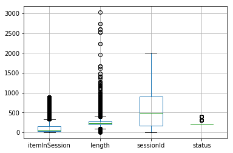

```python
numerical_vars_churned.boxplot();
```

```python
# How different are these user distributions for those who left the service from those of people who continue using it?
numerical_vars_not_churned = spark.sql('''
        SELECT userId, itemInSession, length, sessionId ,  status
        FROM user_log_table
        WHERE Churn == 0
        ''').toPandas()
```

```python
numerical_vars_not_churned
```

|  | userId | itemInSession | length | sessionId | status |
| --- | --- | --- | --- | --- | --- |
| 0 | 100010 | 34 | NaN | 187 | 307 |
| 1 | 100010 | 33 | 185.25995 | 187 | 200 |
| 2 | 100010 | 32 | 269.76608 | 187 | 200 |
| 3 | 100010 | 31 | 115.90485 | 187 | 200 |
| 4 | 100010 | 30 | NaN | 187 | 200 |
| 5 | 100010 | 29 | 319.42485 | 187 | 200 |
| 6 | 100010 | 28 | 302.57587 | 187 | 200 |
| 7 | 100010 | 27 | 305.05751 | 187 | 200 |
| 8 | 100010 | 26 | 207.64689 | 187 | 200 |
| 9 | 100010 | 25 | 264.93342 | 187 | 200 |
| 10 | 100010 | 24 | NaN | 187 | 307 |
| 11 | 100010 | 23 | 227.08200 | 187 | 200 |
| 12 | 100010 | 22 | 281.54730 | 187 | 200 |
| 13 | 100010 | 21 | 345.05098 | 187 | 200 |
| 14 | 100010 | 20 | 367.15057 | 187 | 200 |
| 15 | 100010 | 19 | 299.75465 | 187 | 200 |
| 16 | 100010 | 18 | 214.80444 | 187 | 200 |
| 17 | 100010 | 17 | NaN | 187 | 307 |
| 18 | 100010 | 16 | 258.16771 | 187 | 200 |
| 19 | 100010 | 15 | NaN | 187 | 307 |
| 20 | 100010 | 14 | 260.25751 | 187 | 200 |
| 21 | 100010 | 13 | 237.47873 | 187 | 200 |
| 22 | 100010 | 12 | 61.85751 | 187 | 200 |
| 23 | 100010 | 11 | 228.46649 | 187 | 200 |
| 24 | 100010 | 10 | NaN | 187 | 200 |
| 25 | 100010 | 9 | NaN | 187 | 200 |
| 26 | 100010 | 8 | 320.18240 | 187 | 200 |
| 27 | 100010 | 7 | 181.21098 | 187 | 200 |
| 28 | 100010 | 6 | 248.58077 | 187 | 200 |
| 29 | 100010 | 5 | 321.54077 | 187 | 200 |
| ... | ... | ... | ... | ... | ... |
| 233260 | 119 | 19 | 211.06893 | 633 | 200 |
| 233261 | 119 | 18 | NaN | 633 | 404 |
| 233262 | 119 | 17 | 250.82730 | 633 | 200 |
| 233263 | 119 | 16 | NaN | 633 | 200 |
| 233264 | 119 | 15 | 187.29751 | 633 | 200 |
| 233265 | 119 | 14 | 201.56036 | 633 | 200 |
| 233266 | 119 | 13 | NaN | 633 | 200 |
| 233267 | 119 | 12 | 209.55383 | 633 | 200 |
| 233268 | 119 | 11 | 189.98812 | 633 | 200 |
| 233269 | 119 | 10 | 297.87383 | 633 | 200 |
| 233270 | 119 | 9 | 266.47465 | 633 | 200 |
| 233271 | 119 | 8 | NaN | 633 | 200 |
| 233272 | 119 | 7 | 232.98567 | 633 | 200 |
| 233273 | 119 | 6 | NaN | 633 | 200 |
| 233274 | 119 | 5 | 167.57506 | 633 | 200 |
| 233275 | 119 | 4 | 518.81751 | 633 | 200 |
| 233276 | 119 | 3 | NaN | 633 | 200 |
| 233277 | 119 | 2 | NaN | 633 | 200 |
| 233278 | 119 | 1 | 425.01179 | 633 | 200 |
| 233279 | 119 | 0 | NaN | 633 | 200 |
| 233280 | 119 | 10 | NaN | 437 | 200 |
| 233281 | 119 | 9 | 262.47791 | 437 | 200 |
| 233282 | 119 | 8 | 264.93342 | 437 | 200 |
| 233283 | 119 | 7 | 215.06567 | 437 | 200 |
| 233284 | 119 | 6 | 288.57424 | 437 | 200 |
| 233285 | 119 | 5 | 189.62240 | 437 | 200 |
| 233286 | 119 | 4 | 294.84363 | 437 | 200 |
| 233287 | 119 | 3 | 290.48118 | 437 | 200 |
| 233288 | 119 | 2 | 147.04281 | 437 | 200 |
| 233289 | 119 | 1 | NaN | 437 | 200 |

233290 rows × 5 columns

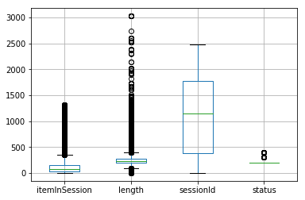

```python
numerical_vars_not_churned.boxplot();
```

```python
numerical_vars_churned.describe()
```

|  | itemInSession | length | sessionId | status |
| --- | --- | --- | --- | --- |
| count | 44864.000000 | 36394.000000 | 44864.000000 | 44864.000000 |
| mean | 109.232993 | 248.632796 | 613.316178 | 208.958029 |
| std | 122.721709 | 102.384977 | 512.056679 | 29.873011 |
| min | 0.000000 | 4.048530 | 1.000000 | 200.000000 |
| 25% | 26.000000 | 199.392200 | 171.000000 | 200.000000 |
| 50% | 66.000000 | 233.899950 | 496.000000 | 200.000000 |
| 75% | 147.000000 | 275.630567 | 904.000000 | 200.000000 |
| max | 889.000000 | 3024.665670 | 2003.000000 | 404.000000 |

```python
numerical_vars_not_churned.describe()
```

|  | itemInSession | length | sessionId | status |
| --- | --- | --- | --- | --- |
| count | 233290.000000 | 191714.000000 | 233290.000000 | 233290.000000 |
| mean | 115.988847 | 249.209135 | 1125.109816 | 209.131137 |
| std | 131.150670 | 98.625883 | 732.553850 | 30.204613 |
| min | 0.000000 | 0.783220 | 1.000000 | 200.000000 |
| 25% | 27.000000 | 199.940770 | 377.000000 | 200.000000 |
| 50% | 71.000000 | 234.657510 | 1150.000000 | 200.000000 |
| 75% | 159.000000 | 277.158730 | 1775.000000 | 200.000000 |
| max | 1321.000000 | 3024.665670 | 2474.000000 | 404.000000 |

```python
numerical_vars_not_churned.describe() - numerical_vars_churned.describe()
```

|  | itemInSession | length | sessionId | status |
| --- | --- | --- | --- | --- |
| count | 188426.000000 | 155320.000000 | 188426.000000 | 188426.000000 |
| mean | 6.755853 | 0.576340 | 511.793638 | 0.173109 |
| std | 8.428961 | -3.759094 | 220.497172 | 0.331602 |
| min | 0.000000 | -3.265310 | 0.000000 | 0.000000 |
| 25% | 1.000000 | 0.548570 | 206.000000 | 0.000000 |
| 50% | 5.000000 | 0.757560 | 654.000000 | 0.000000 |
| 75% | 12.000000 | 1.528163 | 871.000000 | 0.000000 |
| max | 432.000000 | 0.000000 | 471.000000 | 0.000000 |

Those who keep up the service usually interact with us more often. Continually customers have more sessions over time (`sessionId`) and listen to more tracks during sessions (`itemInSession`). On the length of the songs they perform (`length`) or in the status codes of their HTTP requests—e.g., `Bad Request 400 Error`—there is no significant variation between the two groups.

### Introducing a new variable `usrInteractions`

This new var `usrInteractions` shows the total number of interactions of a user.

```python
df_clean  = df_clean.withColumn("usrInteractions", count ("itemInSession").over(usrWindow))
```

```python
df_clean.select(["itemInSession", "timeStamp", "page", ("sessionId") , "usrInteractions"])\
           .where(df_clean.userId == "77")\
           .sort("ts").collect()
```

```
[Row(itemInSession=0, timeStamp='2018-10-01 21:02:30', page='Home', sessionId=173, usrInteractions=1229),
 Row(itemInSession=0, timeStamp='2018-10-02 06:29:28', page='Home', sessionId=315, usrInteractions=1229),
 Row(itemInSession=1, timeStamp='2018-10-02 06:30:48', page='NextSong', sessionId=315, usrInteractions=1229),
 Row(itemInSession=2, timeStamp='2018-10-02 06:42:23', page='NextSong', sessionId=315, usrInteractions=1229),
 Row(itemInSession=3, timeStamp='2018-10-02 06:46:19', page='NextSong', sessionId=315, usrInteractions=1229),
 Row(itemInSession=4, timeStamp='2018-10-02 06:46:42', page='NextSong', sessionId=315, usrInteractions=1229),
 Row(itemInSession=5, timeStamp='2018-10-02 06:47:36', page='Home', sessionId=315, usrInteractions=1229),
 Row(itemInSession=6, timeStamp='2018-10-02 06:51:02', page='NextSong', sessionId=315, usrInteractions=1229),
 Row(itemInSession=7, timeStamp='2018-10-02 06:54:31', page='NextSong', sessionId=315, usrInteractions=1229),
 Row(itemInSession=8, timeStamp='2018-10-02 06:54:32', page='Thumbs Up', sessionId=315, usrInteractions=1229),
 Row(itemInSession=9, timeStamp='2018-10-02 06:58:12', page='NextSong', sessionId=315, usrInteractions=1229),
 Row(itemInSession=10, timeStamp='2018-10-02 07:00:15', page='NextSong', sessionId=315, usrInteractions=1229),
 Row(itemInSession=11, timeStamp='2018-10-02 07:04:30', page='NextSong', sessionId=315, usrInteractions=1229),
 Row(itemInSession=12, timeStamp='2018-10-02 07:08:40', page='NextSong', sessionId=315, usrInteractions=1229),
 Row(itemInSession=13, timeStamp='2018-10-02 07:12:12', page='NextSong', sessionId=315, usrInteractions=1229),
 Row(itemInSession=14, timeStamp='2018-10-02 07:16:49', page='NextSong', sessionId=315, usrInteractions=1229),
 Row(itemInSession=15, timeStamp='2018-10-02 07:20:14', page='NextSong', sessionId=315, usrInteractions=1229),
 Row(itemInSession=16, timeStamp='2018-10-02 07:23:58', page='NextSong', sessionId=315, usrInteractions=1229),
 Row(itemInSession=17, timeStamp='2018-10-02 07:28:00', page='NextSong', sessionId=315, usrInteractions=1229),
 Row(itemInSession=18, timeStamp='2018-10-02 07:31:40', page='NextSong', sessionId=315, usrInteractions=1229),
 Row(itemInSession=19, timeStamp='2018-10-02 07:36:02', page='NextSong', sessionId=315, usrInteractions=1229),
 Row(itemInSession=20, timeStamp='2018-10-02 07:36:03', page='Thumbs Up', sessionId=315, usrInteractions=1229),
 Row(itemInSession=21, timeStamp='2018-10-02 07:40:56', page='NextSong', sessionId=315, usrInteractions=1229),
 Row(itemInSession=22, timeStamp='2018-10-02 07:44:43', page='NextSong', sessionId=315, usrInteractions=1229),
 Row(itemInSession=23, timeStamp='2018-10-02 07:48:48', page='NextSong', sessionId=315, usrInteractions=1229),
 Row(itemInSession=24, timeStamp='2018-10-02 07:52:41', page='NextSong', sessionId=315, usrInteractions=1229),
 Row(itemInSession=25, timeStamp='2018-10-02 07:57:35', page='NextSong', sessionId=315, usrInteractions=1229),
 Row(itemInSession=26, timeStamp='2018-10-02 08:01:34', page='NextSong', sessionId=315, usrInteractions=1229),
 Row(itemInSession=27, timeStamp='2018-10-02 08:06:38', page='NextSong', sessionId=315, usrInteractions=1229),
 Row(itemInSession=28, timeStamp='2018-10-02 08:11:36', page='NextSong', sessionId=315, usrInteractions=1229),
 Row(itemInSession=29, timeStamp='2018-10-02 08:16:13', page='NextSong', sessionId=315, usrInteractions=1229),
 Row(itemInSession=30, timeStamp='2018-10-02 08:20:04', page='NextSong', sessionId=315, usrInteractions=1229),
 Row(itemInSession=31, timeStamp='2018-10-02 08:25:12', page='NextSong', sessionId=315, usrInteractions=1229),
 Row(itemInSession=32, timeStamp='2018-10-02 08:27:58', page='NextSong', sessionId=315, usrInteractions=1229),
 Row(itemInSession=33, timeStamp='2018-10-02 08:31:35', page='NextSong', sessionId=315, usrInteractions=1229),
 Row(itemInSession=34, timeStamp='2018-10-02 08:36:09', page='NextSong', sessionId=315, usrInteractions=1229),
 Row(itemInSession=35, timeStamp='2018-10-02 08:39:10', page='NextSong', sessionId=315, usrInteractions=1229),
 Row(itemInSession=36, timeStamp='2018-10-02 08:43:36', page='NextSong', sessionId=315, usrInteractions=1229),
 Row(itemInSession=37, timeStamp='2018-10-02 08:47:20', page='NextSong', sessionId=315, usrInteractions=1229),
 Row(itemInSession=38, timeStamp='2018-10-02 08:49:53', page='NextSong', sessionId=315, usrInteractions=1229),
```

[output cut: 946 more lines]

```
 Row(itemInSession=60, timeStamp='2018-11-06 19:00:03', page='NextSong', sessionId=1256, usrInteractions=1229),
 Row(itemInSession=61, timeStamp='2018-11-06 19:02:05', page='NextSong', sessionId=1256, usrInteractions=1229),
 Row(itemInSession=62, timeStamp='2018-11-06 19:06:30', page='NextSong', sessionId=1256, usrInteractions=1229),
 Row(itemInSession=63, timeStamp='2018-11-06 19:11:37', page='NextSong', sessionId=1256, usrInteractions=1229),
 Row(itemInSession=64, timeStamp='2018-11-06 19:14:56', page='NextSong', sessionId=1256, usrInteractions=1229),
 Row(itemInSession=65, timeStamp='2018-11-06 19:14:57', page='Thumbs Up', sessionId=1256, usrInteractions=1229),
 Row(itemInSession=66, timeStamp='2018-11-06 19:17:04', page='Add to Playlist', sessionId=1256, usrInteractions=1229),
 Row(itemInSession=67, timeStamp='2018-11-06 19:20:03', page='NextSong', sessionId=1256, usrInteractions=1229),
 Row(itemInSession=68, timeStamp='2018-11-06 19:24:15', page='NextSong', sessionId=1256, usrInteractions=1229),
 Row(itemInSession=69, timeStamp='2018-11-06 19:28:10', page='NextSong', sessionId=1256, usrInteractions=1229),
 Row(itemInSession=70, timeStamp='2018-11-06 19:31:31', page='NextSong', sessionId=1256, usrInteractions=1229),
 Row(itemInSession=71, timeStamp='2018-11-06 19:34:50', page='NextSong', sessionId=1256, usrInteractions=1229),
 Row(itemInSession=0, timeStamp='2018-11-27 12:53:53', page='NextSong', sessionId=1672, usrInteractions=1229),
 Row(itemInSession=1, timeStamp='2018-11-27 12:53:59', page='Home', sessionId=1672, usrInteractions=1229),
 ...]
```

```python
df_clean.createOrReplaceTempView("user_log_table")
```

## `Gender [Female/Male]`

- The categorical variable `gender` takes any of two possible values, `F` or `M`.

```python
spark.sql('''
          SELECT Churn, gender, COUNT(DISTINCT userId) AS num_of_users
          FROM user_log_table
          GROUP BY Churn, gender
          ORDER BY Churn DESC, gender

          '''
         ).show()
```

```
+-----+------+------------+
|Churn|gender|num_of_users|
+-----+------+------------+
|    1|     F|          20|
|    1|     M|          32|
|    0|     F|          84|
|    0|     M|          89|
+-----+------+------------+
```

We will employ a statistical proportions test to assess whether females and males have an equal likelihood of cancelling the service (null hypothesis).

**Definition of p-value**

In null hypothesis significance testing, the p-value represents the likelihood of acquiring test results that are at least as extreme as those observed as dramatic as the outcomes obtained, assuming the null hypothesis is valid.

A diminutive p-value indicates that an exceptional observed outcome would be highly improbable under the null hypothesis.

```python
from statsmodels.stats.proportion import proportions_ztest

count = np.array([20, 32])
nobs  = np.array([(20+84), (32+89)])


stat, pval  = proportions_ztest(count, nobs, value=None, alternative='two-sided', prop_var=False)

print('{0:0.2f} test statistic for the z-test'.format(stat))
print('{0:0.2f} p-value for the z-test'.format(pval))
```

```
-1.28 test statistic for the z-test
0.20 p-value for the z-test
```

We cannot dismiss the null hypothesis that gender does not influence churn likelihood, as the p-value of 0.201 is excessively high. There is a 20 percent probability of acquiring the observed statistic or a more extreme value supporting the alternative hypothesis.

### **Location [`city` & `state`]**

The categorical variable `location` indicates the `cities` and `states` of users' residence in USA. Our primary focus is on state-specific locations, and we compile the user count accordingly.

```python
df_clean = df_clean.withColumn('city', split(df['location'], ",").getItem(0))\
        .withColumn('state', split(df_clean['location'], ",").getItem(1))
```

```python
df_clean.createOrReplaceTempView("user_log_table")
```

```python
df_clean
```

```
DataFrame[artist: string, auth: string, firstName: string, gender: string, itemInSession: bigint, lastName: string, length: double, level: string, location: string, method: string, page: string, registration: bigint, sessionId: bigint, song: string, status: bigint, ts: bigint, userAgent: string, use…
```

```python
loc_churned  = spark.sql('''
        SELECT state, COUNT(DISTINCT userId) AS user_churned
        FROM user_log_table
        WHERE Churn = 1
        GROUP BY state
        ORDER BY user_churned DESC
        '''
        ).toPandas()
```

```python
loc_churned   = loc_churned.set_index('state')
```

```python
loc_active  = spark.sql('''
        SELECT state, COUNT(DISTINCT userId) AS active_users
        FROM user_log_table
        WHERE Churn = 0
        GROUP BY state
        ORDER BY active_users DESC
        '''
        ).toPandas()
```

```python
loc_active = loc_active.set_index('state')
```

```python
loc_by_state = pd.concat([loc_churned.groupby('state').sum(), loc_active.groupby('state').sum()], \
                              axis=1, join="outer", sort=True)
```

```python
loc_by_state = loc_by_state.sort_values(by=['active_users', 'user_churned'], ascending=False)
```

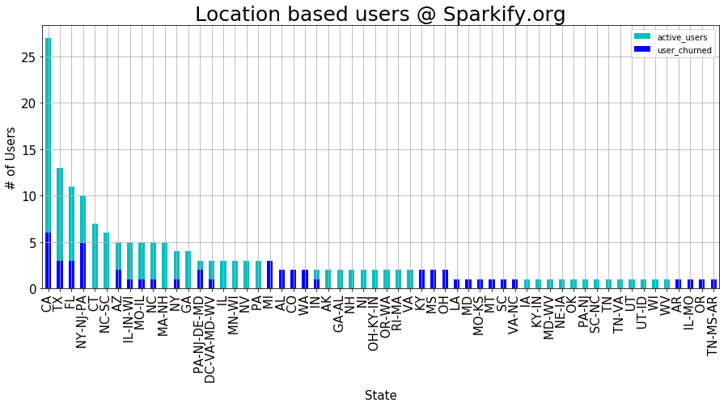

```python
plt.title('Location based users @ Sparkify.org', fontsize=25)

ax = loc_by_state['active_users'].plot(kind='bar', \
                                               color ='c', figsize=(15, 6), legend=True, fontsize=10)

ax = loc_by_state['user_churned'].plot(kind='bar', \
                                              color ='b', legend=True, fontsize=15)
ax.set_xlabel("State", fontsize=15)
ax.set_ylabel("# of Users", fontsize=15)
plt.grid(True)
plt.show()
```

The majority of Sparify.org users reside in states with substantial populations. In the limited dataset, Sparify's churn rate in California, Texas, and Florida is lower than the overall churn rate of 52 out of 225, or 23 percent. Nevertheless, Spotify's turnover rate in some less populous states remains elevated.

### **Artist**

The variable `artist` display the name of the artist singing the `song` played by the user.

```python
# How many artists are there in the data set?
spark.sql('''
        SELECT COUNT(DISTINCT Artist) AS no_of_artists
        FROM user_log_table
        '''
        ).show()
```

```
+-------------+
|no_of_artists|
+-------------+
|        17655|
+-------------+
```

```python
# How many songs were played from the most played artist?
artist_active = spark.sql('''
        SELECT Artist, COUNT(Artist) AS active_users
        FROM user_log_table
        WHERE Churn == 0
        GROUP BY Artist
        ORDER BY active_users DESC

        '''
        ).toPandas()
```

```python
artist_active = artist_active.set_index('Artist')
```

```python
artist_churn = spark.sql('''
        SELECT Artist, COUNT(Artist) AS user_churned
        FROM user_log_table
        WHERE Churn == 1
        GROUP BY Artist
        ORDER BY user_churned DESC

        '''
        ).toPandas()
```

```python
artist_churn = artist_churn.set_index('Artist')
```

```python
df_artist= pd.concat([artist_active.groupby('Artist').sum(), artist_churn.groupby('Artist').sum()], \
                              axis=1, join="outer", sort=True)
```

```python
df_artist = df_artist.sort_values(by=['active_users', 'user_churned'], ascending=False)
```

```python
df_artist
```

|  | active_users | user_churned |
| --- | --- | --- |
| Coldplay | 1552.0 | 261.0 |
| Kings Of Leon | 1542.0 | 299.0 |
| Florence + The Machine | 1048.0 | 188.0 |
| BjÃ¶rk | 962.0 | 171.0 |
| Dwight Yoakam | 952.0 | 183.0 |
| The Black Keys | 940.0 | 185.0 |
| Muse | 926.0 | 164.0 |
| Justin Bieber | 876.0 | 168.0 |
| Jack Johnson | 852.0 | 155.0 |
| Eminem | 805.0 | 148.0 |
| Alliance Ethnik | 735.0 | 141.0 |
| Radiohead | 728.0 | 156.0 |
| Train | 714.0 | 140.0 |
| OneRepublic | 703.0 | 125.0 |
| The Killers | 700.0 | 122.0 |
| Taylor Swift | 694.0 | 146.0 |
| Linkin Park | 680.0 | 107.0 |
| Evanescence | 656.0 | 125.0 |
| Harmonia | 603.0 | 126.0 |
| Guns N' Roses | 601.0 | 112.0 |
| Daft Punk | 595.0 | 118.0 |
| Metallica | 587.0 | 110.0 |
| John Mayer | 580.0 | 113.0 |
| Barry Tuckwell/Academy of St Martin-in-the-Fields/Sir Neville Marriner | 543.0 | 100.0 |
| Lily Allen | 526.0 | 92.0 |
| Kanye West | 504.0 | 111.0 |
| Nickelback | 503.0 | 94.0 |
| Foo Fighters | 500.0 | 97.0 |
| The All-American Rejects | 475.0 | 84.0 |
| Rise Against | 464.0 | 109.0 |
| ... | ... | ... |
| Victimas Del Doctor Cerebro | NaN | 1.0 |
| Victor DÃ©mÃ© | NaN | 1.0 |
| Vivien Goldman | NaN | 1.0 |
| WWE John Cena and Tha Trademarc | NaN | 1.0 |
| Wallis Bird | NaN | 1.0 |
| War Tapes | NaN | 1.0 |
| Watain | NaN | 1.0 |
| Wax | NaN | 1.0 |
| Wendy Rene | NaN | 1.0 |
| White Rose Movement | NaN | 1.0 |
| Wiley ft. Messy & Desparado | NaN | 1.0 |
| William Jackson | NaN | 1.0 |
| Windmills By The Ocean | NaN | 1.0 |
| With Blood Comes Cleansing | NaN | 1.0 |
| World / Inferno Friendship Society | NaN | 1.0 |
| Wyclef Jean featuring Buju Banton | NaN | 1.0 |
| Wyclef Jean featuring Melky | NaN | 1.0 |
| Wynton Kelly | NaN | 1.0 |
| Xenia Beliayeva | NaN | 1.0 |
| Yoskar Sarante | NaN | 1.0 |
| Young Jeezy_ DJ Drama | NaN | 1.0 |
| YoungBloodZ Featuring Shawty Putt | NaN | 1.0 |
| Youthful Praise | NaN | 1.0 |
| Youthmovies | NaN | 1.0 |
| Zac Efron / Nikki Blonsky / Elijah Kelley / Amanda Bynes | NaN | 1.0 |
| Zagar feat. Underground Divas | NaN | 1.0 |
| Zander VT | NaN | 1.0 |
| Zeraphine | NaN | 1.0 |
| doubleDrive | NaN | 1.0 |
| vanize | NaN | 1.0 |

17655 rows × 2 columns

```python
df_artist = df_artist.head(100)
```

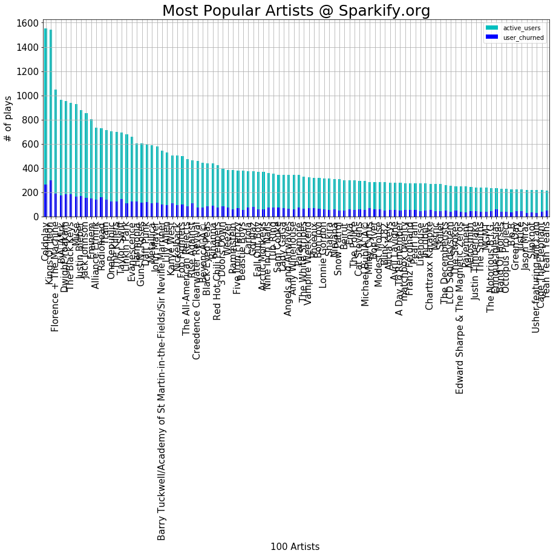

```python
plt.title('Most Popular Artists @ Sparkify.org', fontsize=25)

ax = df_artist['active_users'].plot(kind='bar', color ='c', figsize=(15, 6), legend=True, fontsize=15)
ax = df_artist['user_churned'].plot(kind='bar', color ='b', legend=True, fontsize=15)
ax.set_xlabel("100 Artists ", fontsize=15)
ax.set_ylabel("# of plays", fontsize=15)
plt.grid(True)
plt.show()
```

```python
df_clean.toPandas().to_csv('dfClean.csv')
```

# If paused start with importing `df_clean`

```python
from pyspark.sql import SparkSession

# Create Spark session if not already created
spark = SparkSession.builder.appName("ReadCSV").getOrCreate()

# Read CSV file
df_clean_file = spark.read.csv('dfClean.csv', header=True, inferSchema=True).drop('_c0')
df_clean_file
```

```
DataFrame[artist: string, auth: string, firstName: string, gender: string, itemInSession: int, lastName: string, length: double, level: string, location: string, method: string, page: string, registration: bigint, sessionId: int, song: string, status: int, ts: bigint, userAgent: string, userId: stri…
```

```python
df_clean = df_clean_file
```

```python
df_clean.createOrReplaceTempView("user_log_table")
```

## `Page`

```python
pages  = spark.sql('''
        SELECT page, Churn, COUNT(page) AS no_of_records
        FROM user_log_table
        GROUP BY Churn, page
        ORDER BY page DESC
        '''
        ).toPandas()
```

```python
pages_nochurn = pages[pages.Churn == 0]
pages_nochurn = pages_nochurn.rename(columns={"no_of_records": "active_users"})
pages_nochurn = pages_nochurn.drop(['Churn'], axis=1)
pages_nochurn = pages_nochurn.set_index('page')

pages_churn = pages[pages.Churn == 1]
pages_churn = pages_churn.rename(columns={"no_of_records": "users_churned"})
pages_churn = pages_churn.drop(['Churn'], axis=1)
pages_churn = pages_churn.set_index('page')

df_page = pd.concat([pages_nochurn, pages_churn], axis=1, join="inner")
```

```python
df_page = df_page.sort_values(by=['active_users', 'users_churned'], ascending=True)
```

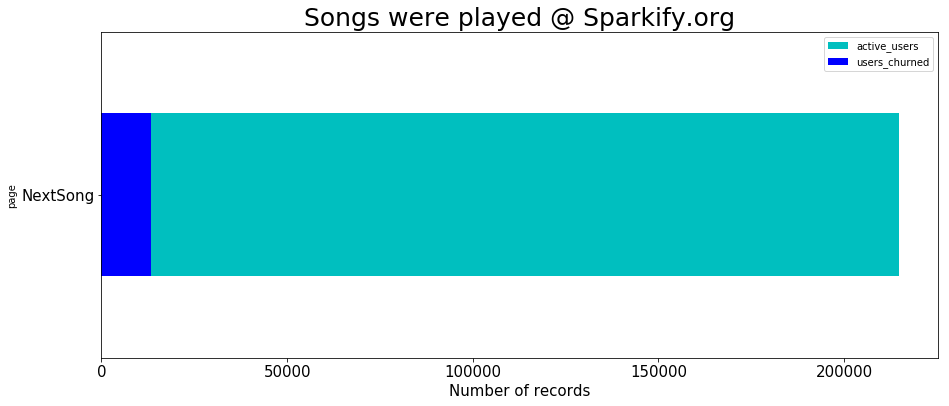

```python
plt.title('Songs were played @ Sparkify.org', fontsize=25)
plt.grid(True)
ax = df_page['active_users'].tail(1).plot(kind='barh', color ='c', figsize=(15, 6), legend=True, fontsize=15)

ax = df_page['users_churned'].tail(1).plot(kind='barh', \
                                              color ='b', legend=True, fontsize=15)
ax.set_xlabel("Number of records", fontsize=15)
plt.grid(False)
plt.show()
```

What is the average number of tracks played by churned users prior to subscription cancellation?

```python
is_confCancel = spark.sql('''
            SELECT userID, page, ts, CASE WHEN page = 'Cancellation Confirmation' THEN 1 ELSE 0 END AS is_home
            FROM user_log_table
            WHERE ((page = 'NextSong') OR (page = 'Cancellation Confirmation')) AND Churn == 1
            '''
            )

is_confCancel.createOrReplaceTempView("is_confCancel_table")
```

```python
is_confCancel
```

```
DataFrame[userID: string, page: string, ts: bigint, is_home: int]
```

```python
cumulative_sum = spark.sql('''
            SELECT * , SUM(is_home)
            OVER (PARTITION BY userID ORDER BY ts DESC ROWS BETWEEN UNBOUNDED PRECEDING AND CURRENT ROW) AS period
            FROM is_confCancel_table
            '''
            )

cumulative_sum.createOrReplaceTempView("period_table")
```

```python
spark.sql('''
          SELECT INT(ROUND (AVG(count_results),0)) AS average_no_of_songs
          FROM (SELECT COUNT(*) AS count_results FROM period_table \
          GROUP BY userID, period, page HAVING page = 'NextSong') AS counts
          '''
          ).show()
```

```
+-------------------+
|average_no_of_songs|
+-------------------+
|                790|
+-------------------+
```

### `Authentication`

Two Possible Vars

- Logged In
- Cancelled

```python
df_clean.dropDuplicates(["userId"]).groupby(["Churn", "auth"]).count().sort("Churn").show()
```

```
+-----+---------+-----+
|Churn|     auth|count|
+-----+---------+-----+
|    0|Logged In|   58|
|    1|Cancelled|   20|
+-----+---------+-----+
```

### `length`

- Stores the lenth of time a user listens to a song.

```python
spark.sql('''
          SELECT Churn, AVG(length) AS average_length, MIN(length) AS minimum_length,
                 MAX(length) AS maximum_length, SUM(length) AS total_length
          FROM user_log_table
          GROUP BY Churn
          ORDER BY Churn DESC

          '''
         ).show()
```

```
+-----+------------------+--------------+--------------+--------------------+
|Churn|    average_length|minimum_length|maximum_length|        total_length|
+-----+------------------+--------------+--------------+--------------------+
|    1|248.53451588524223|      11.49342|    3024.66567|  3339558.2899499997|
|    0|249.15365306282513|       0.78322|    3024.66567|5.3486063856649734E7|
+-----+------------------+--------------+--------------+--------------------+
```

### `level`

- free
- paid

```python
spark.sql('''
        SELECT Churn, level,COUNT(DISTINCT userId) AS No_of_Users
        FROM user_log_table
        GROUP BY Churn, level
        ORDER BY No_of_Users DESC
''').show()
```

```
+-----+-----+-----------+
|Churn|level|No_of_Users|
+-----+-----+-----------+
|    0| free|         53|
|    0| paid|         51|
|    1| free|         23|
|    1| paid|         18|
+-----+-----+-----------+
```

```python
df_page
```

| page | active_users | users_churned |
| --- | --- | --- |
| Cancel | 35 | 17 |
| Submit Downgrade | 60 | 3 |
| Submit Upgrade | 146 | 13 |
| Error | 239 | 13 |
| Save Settings | 290 | 20 |
| Upgrade | 455 | 44 |
| About | 469 | 26 |
| Help | 1375 | 79 |
| Settings | 1416 | 98 |
| Downgrade | 1911 | 144 |
| Thumbs Down | 2329 | 217 |
| Logout | 3006 | 220 |
| Roll Advert | 3547 | 386 |
| Add Friend | 4074 | 203 |
| Add to Playlist | 6153 | 373 |
| Home | 9448 | 634 |
| Thumbs Up | 11867 | 684 |
| NextSong | 214671 | 13437 |

```python
df_page = df_page.drop(index='NextSong').sort_values(by=['active_users', 'users_churned'], ascending=True)
df_page
```

| page | active_users | users_churned |
| --- | --- | --- |
| Cancel | 35 | 17 |
| Submit Downgrade | 60 | 3 |
| Submit Upgrade | 146 | 13 |
| Error | 239 | 13 |
| Save Settings | 290 | 20 |
| Upgrade | 455 | 44 |
| About | 469 | 26 |
| Help | 1375 | 79 |
| Settings | 1416 | 98 |
| Downgrade | 1911 | 144 |
| Thumbs Down | 2329 | 217 |
| Logout | 3006 | 220 |
| Roll Advert | 3547 | 386 |
| Add Friend | 4074 | 203 |
| Add to Playlist | 6153 | 373 |
| Home | 9448 | 634 |
| Thumbs Up | 11867 | 684 |

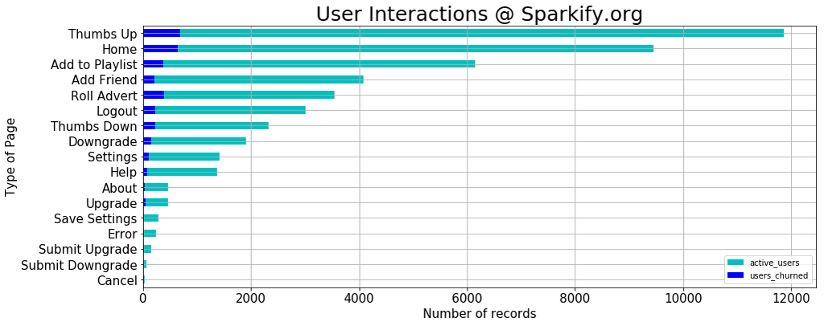

```python
plt.title('User Interactions @ Sparkify.org', fontsize=25)

ax = df_page['active_users'].plot(kind='barh', color ='c', figsize=(15, 6), fontsize=15)

ax = df_page['users_churned'].plot(kind='barh', color ='b', fontsize=15)
ax.set_ylabel("Type of Page", fontsize=15)
ax.set_xlabel("Number of records", fontsize=15)
plt.grid(True)
plt.legend(['active_users', 'users_churned'], loc='lower right')
plt.show()
```

```python
df_clean.createOrReplaceTempView("user_log_table")
```

```python
df_clean.printSchema()
```

```
root
 |-- artist: string (nullable = true)
 |-- auth: string (nullable = true)
 |-- firstName: string (nullable = true)
 |-- gender: string (nullable = true)
 |-- itemInSession: integer (nullable = true)
 |-- lastName: string (nullable = true)
 |-- length: double (nullable = true)
 |-- level: string (nullable = true)
 |-- location: string (nullable = true)
 |-- method: string (nullable = true)
 |-- page: string (nullable = true)
 |-- registration: long (nullable = true)
 |-- sessionId: integer (nullable = true)
 |-- song: string (nullable = true)
 |-- status: integer (nullable = true)
 |-- ts: long (nullable = true)
 |-- userAgent: string (nullable = true)
 |-- userId: string (nullable = true)
 |-- timeStamp: string (nullable = true)
 |-- registration_timeStamp: timestamp (nullable = true)
 |-- memberSince: string (nullable = true)
 |-- isChurn: integer (nullable = true)
 |-- Churn: integer (nullable = true)
 |-- downgrade_event: integer (nullable = true)
 |-- downFreq: integer (nullable = true)
 |-- usrInteractions: integer (nullable = true)
 |-- city: string (nullable = true)
 |-- state: string (nullable = true)
```

```python
df_statistics = spark.sql('''
      WITH page_counts AS(
      SELECT userId,
      MAX(Churn)                                                      AS Churn,
      COUNT(CASE WHEN page = 'Thumbs Up'        THEN 1 ELSE null END) AS thumbs_up,
      COUNT(CASE WHEN page = 'Home'             THEN 1 ELSE null END) AS home,
      COUNT(CASE WHEN page = 'Add to Playlist'  THEN 1 ELSE null END) AS playlist_count,
      COUNT(CASE WHEN page = 'Add Friend'       THEN 1 ELSE null END) AS friends,
      COUNT(CASE WHEN page = 'Roll Advert'      THEN 1 ELSE null END) AS advert,
      COUNT(CASE WHEN page = 'Logout'           THEN 1 ELSE null END) AS logout,
      COUNT(CASE WHEN page = 'Thumbs Down'      THEN 1 ELSE null END) AS thumbs_down,
      COUNT(CASE WHEN page = 'Downgrade'        THEN 1 ELSE null END) AS downgrade,
      COUNT(CASE WHEN page = 'Settings'         THEN 1 ELSE null END) AS settings,
      COUNT(CASE WHEN page = 'Help'             THEN 1 ELSE null END) AS help,
      COUNT(CASE WHEN page = 'About'            THEN 1 ELSE null END) AS about,
      COUNT(CASE WHEN page = 'Upgrade'          THEN 1 ELSE null END) AS upgrade,
      COUNT(CASE WHEN page = 'Save Settings'    THEN 1 ELSE null END) AS save_settings,
      COUNT(CASE WHEN page = 'Error'            THEN 1 ELSE null END) AS error,
      COUNT(CASE WHEN page = 'Submit Upgrade'   THEN 1 ELSE null END) AS submit_upgrade,
      COUNT(CASE WHEN page = 'Submit Downgrade' THEN 1 ELSE null END) AS submit_downgrade,
      COUNT(DISTINCT sessionId)                                       AS session_count,
      MAX (memberSince)                                        AS membership_days,
      SUM(length/(60*60))                                             AS usage_hours

      FROM user_log_table
      GROUP BY userId)
      SELECT Churn,
      ROUND(AVG(thumbs_up),1)           AS thumbs_up,
      ROUND(AVG(home),1)                AS home,
      ROUND(AVG(playlist_count),1)      AS playlist_count,
      ROUND(AVG(friends),1)             AS friends,
      ROUND(AVG(advert),1)              AS advert,
      ROUND(AVG(logout),1)              AS logout,
      ROUND(AVG(thumbs_down),1)         AS thumbs_down,
      ROUND(AVG(downgrade),1)           AS downgrade,
      ROUND(AVG(settings),1)            AS settings,
      ROUND(AVG(help),1)                AS help,
      ROUND(AVG(about),1)               AS about,
      ROUND(AVG(upgrade),1)             AS upgrade,
      ROUND(AVG(save_settings),1)       AS save_settings,
      ROUND(AVG(error),1)               AS error,
      ROUND(AVG(submit_upgrade),1)      AS submit_upgrade,
      ROUND(AVG(submit_downgrade),1)    AS submit_downgrade,
      ROUND(AVG(session_count),1)       AS session_count,
      ROUND(AVG(membership_days),1)     AS membership_days,
      ROUND(AVG(usage_hours),1)         AS usage_hours

      FROM page_counts
      GROUP BY Churn
      '''
      ).toPandas()
```

```python
df_statistics = df_statistics.set_index('Churn')
```

```python
df_statistics
```

| Churn | thumbs_up | home | playlist_count | friends | advert | logout | thumbs_down | downgrade | settings | help | about | upgrade | save_settings | error | submit_upgrade | submit_downgrade | session_count | membership_days | usage_hours |
| --- | --- | --- | --- | --- | --- | --- | --- | --- | --- | --- | --- | --- | --- | --- | --- | --- | --- | --- | --- |
| 1 | 360.0 | 303.3 | 190.4 | 125.1 | 118.2 | 97.0 | 78.7 | 62.3 | 45.2 | 42.4 | 13.8 | 14.7 | 9.6 | 7.4 | 4.6 | 1.9 | 90.6 | 44.2 | 466.1 |
| 0 | 67.0 | 47.2 | 33.3 | 21.7 | 18.5 | 15.1 | 10.9 | 9.4 | 7.3 | 7.4 | 2.8 | 2.5 | 1.3 | 1.2 | 0.8 | 0.3 | 15.4 | 75.9 | 78.0 |

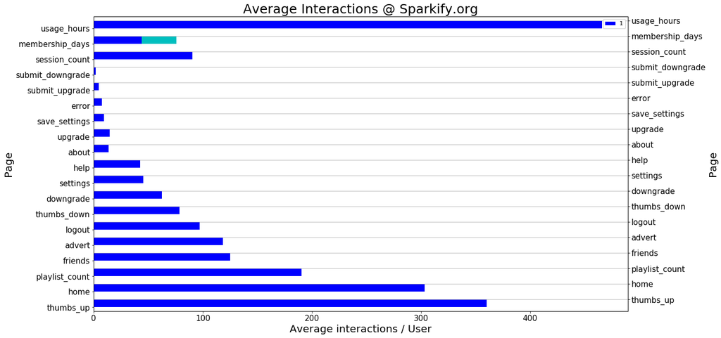

```python
plot_df = df_statistics[0:2].transpose()

fig = plt.figure() # Create matplotlib figure
plt.title('Average Interactions @ Sparkify.org', fontsize=25)
ax = fig.add_subplot(111) # Create matplotlib axes
ax2 = ax.twinx() # Create another axes that shares the same x-axis as ax.


plot_df[0].plot(kind='barh', color='c', ax=ax, position=0, legend=True, fontsize=15)
plot_df[1].plot(kind='barh', color='b', ax=ax2, position=1, legend=True, fontsize=15)

ax.set_xlabel('Average interactions / User', fontsize=20)
ax.set_ylabel('Page', fontsize=20)
ax2.set_ylabel('Page', fontsize=20)
fig.set_size_inches(18.5, 10.5)
plt.grid(True)
plt.show()
```

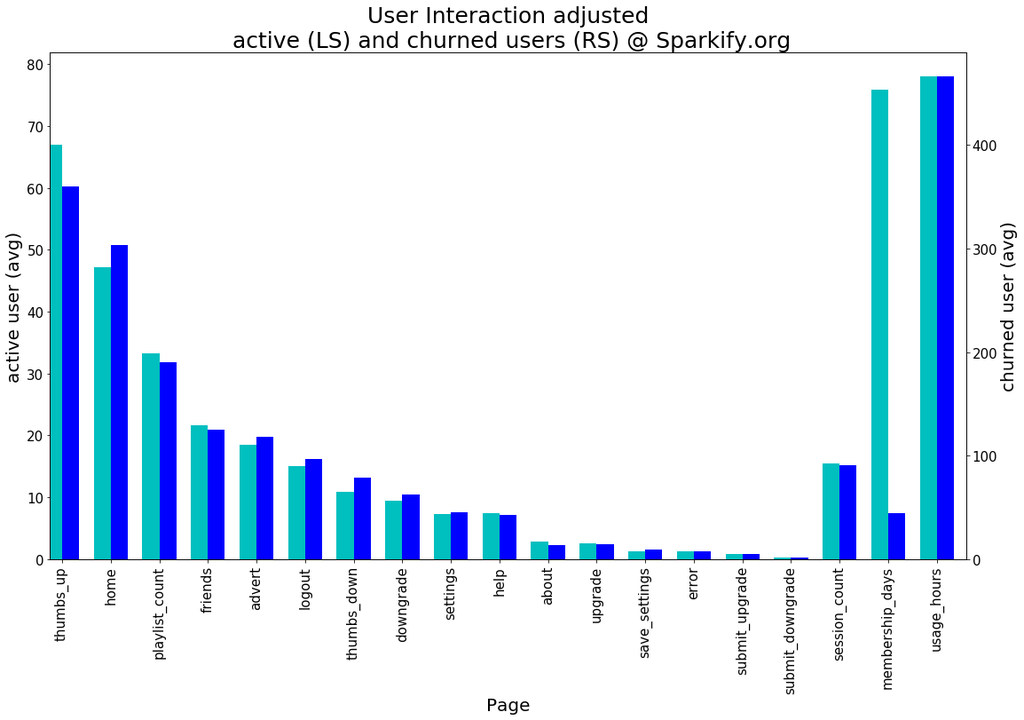

```python
fig = plt.figure()
plt.title('User Interaction adjusted\n active (LS) and churned users (RS) @ Sparkify.org', fontsize=25)
ax = fig.add_subplot(111)
ax2 = ax.twinx()

width = 0.35

plot_df[0].plot(kind='bar', color='c', ax=ax, width=width, position=1, legend=False, fontsize=15)
plot_df[1].plot(kind='bar', color='b', ax=ax2, width=width, position=0, legend=False, fontsize=15)

ax.set_xlabel('Page', fontsize=20)
ax.set_ylabel('active user (avg)', fontsize=20)
ax2.set_ylabel('churned user (avg)', fontsize=20)
fig.set_size_inches(18.5, 10.5)
plt.grid(False)
plt.show()
```

### `datetime`

- `hour`
- `day`
- `weekDay`
- `dateStamp`

```python
getHourOfDay  = udf(lambda x: datetime.datetime.fromtimestamp(x / 1000.0).hour)
getDayOfMonth = udf(lambda x: datetime.datetime.fromtimestamp(x / 1000.0).day)
getWeekday    = udf(lambda x: datetime.datetime.fromtimestamp(x / 1000.0).strftime('%w'))
getDate       = udf(lambda x: datetime.datetime.fromtimestamp(x / 1000.0).strftime('%m/%d/%Y'))
```

```python
df_clean.take(1)
```

```
[Row(artist=None, auth='Logged In', firstName='Darianna', gender='F', itemInSession=34, lastName='Carpenter', length=None, level='free', location='Bridgeport-Stamford-Norwalk, CT', method='PUT', page='Logout', registration=1538016340000, sessionId=187, song=None, status=307, ts=1542823952000, userAg…
```

```python
df_clean = df_clean.withColumn('hour', getHourOfDay(df_clean.ts))
df_clean = df_clean.withColumn('day', getDayOfMonth(df_clean.ts))
df_clean = df_clean.withColumn('weekDay', getWeekday(df_clean.ts))
df_clean = df_clean.withColumn('dateStamp', getDate(df_clean.ts))
```

```python
df_clean.take(1) # New cols are added
```

```
[Row(artist=None, auth='Logged In', firstName='Darianna', gender='F', itemInSession=34, lastName='Carpenter', length=None, level='free', location='Bridgeport-Stamford-Norwalk, CT', method='PUT', page='Logout', registration=1538016340000, sessionId=187, song=None, status=307, ts=1542823952000, userAg…
```

```python
df_clean.createOrReplaceTempView("user_log_table")
```

```python
df_dayOfWeek_active = spark.sql('''
          SELECT day AS dayOfMonth, COUNT(*) as active_users
          FROM user_log_table
          WHERE Churn == 0
          GROUP BY dayOfMonth
          ORDER BY cast(day as int) ASC

          '''
          ).toPandas()
```

```python
df_dayOfWeek_active  = df_dayOfWeek_active.set_index('dayOfMonth')
```

```python
df_dayOfWeek_churn = spark.sql('''
          SELECT day AS dayOfMonth, COUNT(*) as users_churned
          FROM user_log_table
          WHERE Churn == 1
          GROUP BY dayOfMonth
          ORDER BY cast(day as int) ASC

          '''
          ).toPandas()
```

```python
df_dayOfWeek_churn   = df_dayOfWeek_churn.set_index('dayOfMonth')
```

```python
df_dayOfWeek = pd.concat([df_dayOfWeek_active, df_dayOfWeek_churn], axis=1, join="outer")
```

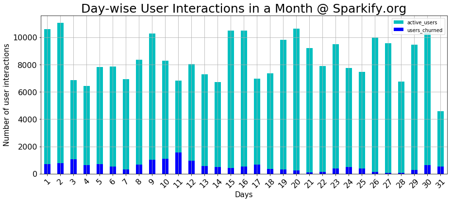

```python
plt.title('Day-wise User Interactions in a Month @ Sparkify.org', fontsize=25)

ax = df_dayOfWeek['active_users'].plot(kind='bar', \
                                                color ='c', figsize=(15, 6), legend=True, fontsize=25)

ax = df_dayOfWeek['users_churned'].plot(kind='bar', \
                                              color ='b', legend=True, fontsize=16)
ax.set_xlabel("Days", fontsize=15)
ax.set_ylabel("Number of user interactions", fontsize=15)
plt.xticks(rotation=45)
plt.grid(True)
plt.show()
```

```python
df_hourly_active = spark.sql('''
          SELECT hour, COUNT(*) as active_users
          FROM user_log_table
          WHERE page = "NextSong" AND Churn = 0
          GROUP BY hour
          ORDER BY cast(hour as int) ASC
          '''
          ).toPandas()
```

```python
df_hourly_active  = df_hourly_active.set_index('hour')
```

```python
df_hourly_churn= spark.sql('''
          SELECT hour, COUNT(*) as users_churned
          FROM user_log_table
          WHERE page = "NextSong" AND Churn = 1
          GROUP BY hour
          ORDER BY cast(hour as int) ASC
          '''
          ).toPandas()
```

```python
df_hourly_churn  = df_hourly_churn.set_index('hour')
```

```python
hour_of_day = pd.concat([df_hourly_active, df_hourly_churn], axis=1, join="inner")
```

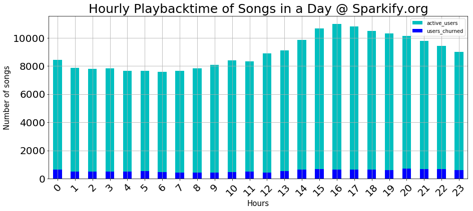

```python
plt.title('Hourly Playbacktime of Songs in a Day @ Sparkify.org', fontsize=25)

ax = hour_of_day['active_users'].plot(kind='bar', \
                                                color ='c', figsize=(15, 6), legend=True, fontsize=25)

ax = hour_of_day['users_churned'].plot(kind='bar', \
                                              color ='b', legend=True, fontsize=20)
ax.set_xlabel("Hours", fontsize=15)
plt.xticks(rotation=45)
ax.set_ylabel("Number of songs", fontsize=15)
plt.grid(True)
plt.show()
```

```python
df_weekday_active = spark.sql('''
          SELECT weekDay , COUNT(*) as active_user
          FROM user_log_table
          WHERE Churn == 0
          GROUP BY weekDay
          ORDER BY cast(weekDay as int) ASC

          '''
          ).toPandas()

df_weekday_active  = df_weekday_active.set_index('weekDay')
```

```python
df_weekday_churn = spark.sql('''
          SELECT weekDay , COUNT(*) as users_churned
          FROM user_log_table
          WHERE Churn == 1
          GROUP BY weekDay
          ORDER BY cast(weekDay as int) ASC

          '''
          ).toPandas()

df_weekday_churn   = df_weekday_churn.set_index('weekDay')
```

```python
df_weekday = pd.concat([df_weekday_active, df_weekday_churn], axis=1, join="outer")
```

```python
# Weekdays are represented as decimal numbers where Sunday: 0 and Saturday: 6.
dict = {'0':'Sunday','1':'Monday','2':'Tuesday','3':'Wednesday','4':'Thursday','5':'Friday','6':'Saturday'}
df_weekday.index = df_weekday.index.map(dict)
```

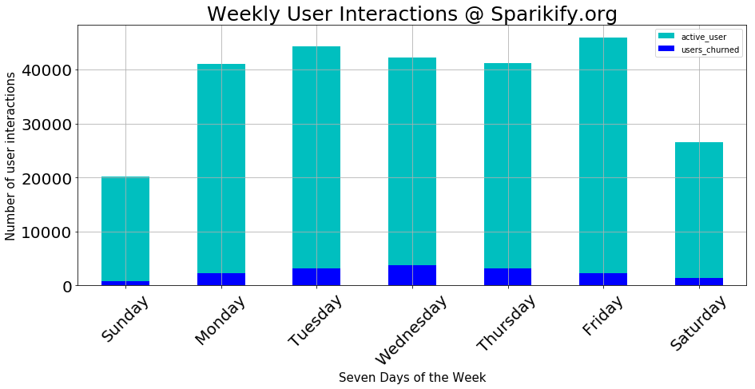

```python
plt.title('Weekly User Interactions @ Sparikify.org', fontsize=25)

ax = df_weekday['active_user'].plot(kind='bar', color ='c', figsize=(15, 6), legend=True, fontsize=20)
ax = df_weekday['users_churned'].plot(kind='bar', color ='b', legend=True, fontsize=20)
ax.set_xlabel("Seven Days of the Week", fontsize=15)
ax.set_ylabel("Number of user interactions", fontsize=15)
plt.xticks(rotation=45)
plt.grid(True)
plt.show()
```

```python
df_dateStamp_active = spark.sql('''
          SELECT dateStamp , COUNT(*) as active_user
          FROM user_log_table
          WHERE Churn == 0
          GROUP BY dateStamp
          ORDER BY cast(dateStamp as int) DESC

          '''
          ).toPandas()

df_dateStamp_active = df_dateStamp_active.set_index('dateStamp')
```

```python
df_dateStamp_churn = spark.sql('''
          SELECT dateStamp , COUNT(*) as users_churned
          FROM user_log_table
          WHERE Churn == 1
          GROUP BY dateStamp
          ORDER BY cast(dateStamp as int) DESC

          '''
          ).toPandas()

df_dateStamp_churn = df_dateStamp_churn.set_index('dateStamp')
```

```python
df_dateStamp = pd.concat([df_dateStamp_active, df_dateStamp_churn], axis=1, join="outer", sort=True)
```

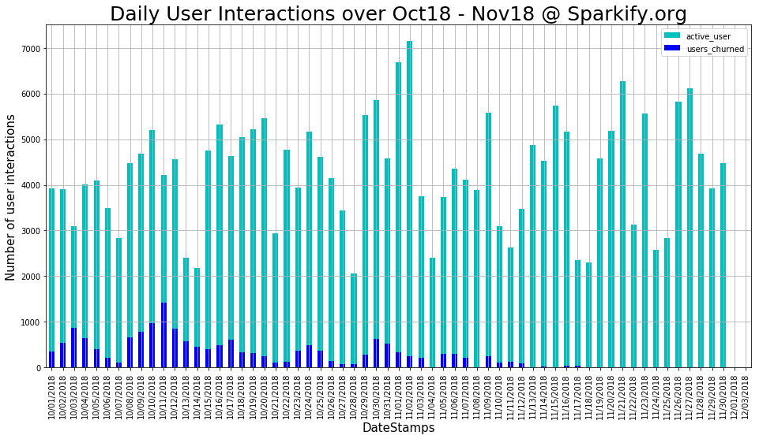

```python
plt.title('Daily User Interactions over Oct18 - Nov18 @ Sparkify.org', fontsize=25)

ax = df_dateStamp['active_user'].plot(kind='bar', color ='c', figsize=(16, 8), legend=True, fontsize=20)

ax = df_dateStamp['users_churned'].plot(kind='bar', color ='b', legend=True, fontsize=10)
ax.set_xlabel("DateStamps", fontsize=15)
ax.set_ylabel("Number of user interactions", fontsize=15)
plt.grid(True)
plt.show()
```

```python
df_clean.createOrReplaceTempView("user_log_table")
```

```python
df_clean.printSchema()
```

```
root
 |-- artist: string (nullable = true)
 |-- auth: string (nullable = true)
 |-- firstName: string (nullable = true)
 |-- gender: string (nullable = true)
 |-- itemInSession: integer (nullable = true)
 |-- lastName: string (nullable = true)
 |-- length: double (nullable = true)
 |-- level: string (nullable = true)
 |-- location: string (nullable = true)
 |-- method: string (nullable = true)
 |-- page: string (nullable = true)
 |-- registration: long (nullable = true)
 |-- sessionId: integer (nullable = true)
 |-- song: string (nullable = true)
 |-- status: integer (nullable = true)
 |-- ts: long (nullable = true)
 |-- userAgent: string (nullable = true)
 |-- userId: string (nullable = true)
 |-- timeStamp: string (nullable = true)
 |-- registration_timeStamp: timestamp (nullable = true)
 |-- memberSince: string (nullable = true)
 |-- isChurn: integer (nullable = true)
 |-- Churn: integer (nullable = true)
 |-- downgrade_event: integer (nullable = true)
 |-- downFreq: integer (nullable = true)
 |-- usrInteractions: integer (nullable = true)
 |-- city: string (nullable = true)
 |-- state: string (nullable = true)
 |-- hour: string (nullable = true)
 |-- day: string (nullable = true)
 |-- weekDay: string (nullable = true)
 |-- dateStamp: string (nullable = true)
```

### `userAgent`

The User-Agent request header is a unique string that allows servers and network peers to determine the program, operating system, vendor, and/or version of the requesting user agent.

- Mobile Device
- PC Desktop
- Tablet
- https://developer.mozilla.org/en-US/docs/Web/HTTP/Headers/User-Agent

```python
userAgent_count = spark.sql('''
        SELECT userAgent,COUNT(userId) AS num_of_records
        FROM user_log_table
        GROUP BY userAgent
        ORDER BY num_of_records DESC
''').toPandas()
```

```python
userAgent_count
```

|  | userAgent | num_of_records |
| --- | --- | --- |
| 0 | """Mozilla/5.0 (Windows NT 6.1; WOW64) AppleWe... | 59021 |
| 1 | """Mozilla/5.0 (Macintosh; Intel Mac OS X 10_9... | 44964 |
| 2 | """Mozilla/5.0 (Macintosh; Intel Mac OS X 10_9... | 19611 |
| 3 | Mozilla/5.0 (Windows NT 6.1; WOW64; rv:31.0) G... | 16700 |
| 4 | """Mozilla/5.0 (Windows NT 6.3; WOW64) AppleWe... | 12541 |
| 5 | Mozilla/5.0 (Macintosh; Intel Mac OS X 10.9; r... | 10300 |
| 6 | """Mozilla/5.0 (Windows NT 6.1) AppleWebKit/53... | 10055 |
| 7 | """Mozilla/5.0 (iPad; CPU OS 7_1_2 like Mac OS... | 8912 |
| 8 | Mozilla/5.0 (compatible; MSIE 9.0; Windows NT ... | 8624 |
| 9 | """Mozilla/5.0 (Macintosh; Intel Mac OS X 10_9... | 8094 |
| 10 | """Mozilla/5.0 (Windows NT 5.1) AppleWebKit/53... | 7406 |
| 11 | """Mozilla/5.0 (iPhone; CPU iPhone OS 7_1_2 li... | 6417 |
| 12 | Mozilla/5.0 (Windows NT 6.3; WOW64; rv:31.0) G... | 5989 |
| 13 | """Mozilla/5.0 (Macintosh; Intel Mac OS X 10_1... | 5716 |
| 14 | Mozilla/5.0 (Windows NT 6.1; WOW64; Trident/7.... | 4663 |
| 15 | """Mozilla/5.0 (X11; Linux x86_64) AppleWebKit... | 4481 |
| 16 | Mozilla/5.0 (Windows NT 6.1; WOW64; rv:32.0) G... | 3655 |
| 17 | """Mozilla/5.0 (Windows NT 6.2; WOW64) AppleWe... | 3278 |
| 18 | Mozilla/5.0 (Windows NT 6.1; WOW64; rv:30.0) G... | 3214 |
| 19 | """Mozilla/5.0 (Macintosh; Intel Mac OS X 10_9... | 2804 |
| 20 | """Mozilla/5.0 (iPhone; CPU iPhone OS 7_1 like... | 2799 |
| 21 | Mozilla/5.0 (X11; Linux x86_64; rv:31.0) Gecko... | 2544 |
| 22 | """Mozilla/5.0 (iPad; CPU OS 7_1_1 like Mac OS... | 2469 |
| 23 | Mozilla/5.0 (Macintosh; Intel Mac OS X 10.7; r... | 2442 |
| 24 | Mozilla/5.0 (Windows NT 6.0; rv:31.0) Gecko/20... | 2442 |
| 25 | Mozilla/5.0 (Windows NT 6.2; WOW64; rv:31.0) G... | 2149 |
| 26 | """Mozilla/5.0 (Macintosh; Intel Mac OS X 10_9... | 2067 |
| 27 | """Mozilla/5.0 (iPhone; CPU iPhone OS 7_1_1 li... | 1976 |
| 28 | Mozilla/5.0 (Macintosh; Intel Mac OS X 10.8; r... | 1950 |
| 29 | Mozilla/5.0 (X11; Ubuntu; Linux x86_64; rv:31.... | 1874 |
| 30 | """Mozilla/5.0 (Macintosh; Intel Mac OS X 10_1... | 1322 |
| 31 | Mozilla/5.0 (compatible; MSIE 9.0; Windows NT ... | 1245 |
| 32 | Mozilla/5.0 (Windows NT 6.1; WOW64; rv:24.0) G... | 1102 |
| 33 | """Mozilla/5.0 (Macintosh; Intel Mac OS X 10_9... | 1102 |
| 34 | Mozilla/5.0 (Windows NT 6.1; rv:31.0) Gecko/20... | 972 |
| 35 | Mozilla/5.0 (compatible; MSIE 10.0; Windows NT... | 815 |
| 36 | """Mozilla/5.0 (Macintosh; Intel Mac OS X 10_7... | 573 |
| 37 | """Mozilla/5.0 (Macintosh; Intel Mac OS X 10_9... | 512 |
| 38 | """Mozilla/5.0 (Macintosh; Intel Mac OS X 10_8... | 475 |
| 39 | """Mozilla/5.0 (Macintosh; Intel Mac OS X 10_7... | 379 |
| 40 | Mozilla/5.0 (Macintosh; Intel Mac OS X 10.6; r... | 251 |
| 41 | """Mozilla/5.0 (Macintosh; Intel Mac OS X 10_6... | 187 |
| 42 | Mozilla/5.0 (X11; Ubuntu; Linux i686; rv:31.0)... | 62 |

```python
userAgent_count.iloc[0,0]
```

```
'"""Mozilla/5.0 (Windows NT 6.1; WOW64) AppleWebKit/537.36 (KHTML'
```

```python
df_clean
```

```
DataFrame[artist: string, auth: string, firstName: string, gender: string, itemInSession: int, lastName: string, length: double, level: string, location: string, method: string, page: string, registration: bigint, sessionId: int, song: string, status: int, ts: bigint, userAgent: string, userId: stri…
```

#### Based on the above userAgent data

- `mobile-andro-ios`
- `windows-pc`
- `apple-mac`
- `linux-debian`

```python
is_mobile = udf(lambda x: 1 if 'Phone' in x else 0, IntegerType())
df_clean = df_clean.withColumn("mobile_android_ios", is_mobile(df_clean.userAgent))

is_tablet = udf(lambda x: 1 if 'iPad' in x else 0, IntegerType())
df_clean = df_clean.withColumn("tablet", is_tablet(df_clean.userAgent))

is_win = udf(lambda x: 1 if 'Windows' in x and not 'Phone' in x and not 'Linux' in x else 0, IntegerType())
df_clean = df_clean.withColumn("windows_pc", is_win(df_clean.userAgent))

is_linux = udf(lambda x: 1 if 'Ubuntu' in x or 'Linux' in x or 'Debian' in x and not 'Phone' in x else 0, IntegerType())
df_clean = df_clean.withColumn("linux_debian", is_linux(df_clean.userAgent))

is_mac = udf(lambda x: 1 if 'Mac' in x and not 'Phone' in x else 0, IntegerType())
df_clean = df_clean.withColumn("apple_mac", is_mac(df_clean.userAgent))
```

```python
df_clean
```

```
DataFrame[artist: string, auth: string, firstName: string, gender: string, itemInSession: int, lastName: string, length: double, level: string, location: string, method: string, page: string, registration: bigint, sessionId: int, song: string, status: int, ts: bigint, userAgent: string, userId: stri…
```

```python
df_clean.createOrReplaceTempView("user_log_table")
```

```python
# Deleting wrong column
# df_clean = df_clean.drop('mobile-andro-ios')
# df_clean
```

[output not shown]

```python
# Deleting wrong column
# df_clean = df_clean.drop('windows-pc')
# df_clean
```

[output not shown]

```python
# Deleting wrong column
# df_clean = df_clean.drop('mobile_andro_ios')
# df_clean
```

[output not shown]

```python
df_clean
```

```
DataFrame[artist: string, auth: string, firstName: string, gender: string, itemInSession: int, lastName: string, length: double, level: string, location: string, method: string, page: string, registration: bigint, sessionId: int, song: string, status: int, ts: bigint, userAgent: string, userId: stri…
```

```python
df_clean
```

```
DataFrame[artist: string, auth: string, firstName: string, gender: string, itemInSession: int, lastName: string, length: double, level: string, location: string, method: string, page: string, registration: bigint, sessionId: int, song: string, status: int, ts: bigint, userAgent: string, userId: stri…
```

```python
df_clean.createOrReplaceTempView("user_log_table")
```

```python
df_clean.printSchema()
```

```
root
 |-- artist: string (nullable = true)
 |-- auth: string (nullable = true)
 |-- firstName: string (nullable = true)
 |-- gender: string (nullable = true)
 |-- itemInSession: integer (nullable = true)
 |-- lastName: string (nullable = true)
 |-- length: double (nullable = true)
 |-- level: string (nullable = true)
 |-- location: string (nullable = true)
 |-- method: string (nullable = true)
 |-- page: string (nullable = true)
 |-- registration: long (nullable = true)
 |-- sessionId: integer (nullable = true)
 |-- song: string (nullable = true)
 |-- status: integer (nullable = true)
 |-- ts: long (nullable = true)
 |-- userAgent: string (nullable = true)
 |-- userId: string (nullable = true)
 |-- timeStamp: string (nullable = true)
 |-- registration_timeStamp: timestamp (nullable = true)
 |-- memberSince: string (nullable = true)
 |-- isChurn: integer (nullable = true)
 |-- Churn: integer (nullable = true)
 |-- downgrade_event: integer (nullable = true)
 |-- downFreq: integer (nullable = true)
 |-- usrInteractions: integer (nullable = true)
 |-- city: string (nullable = true)
 |-- state: string (nullable = true)
 |-- hour: string (nullable = true)
 |-- day: string (nullable = true)
 |-- weekDay: string (nullable = true)
 |-- dateStamp: string (nullable = true)
 |-- mobile_android_ios: integer (nullable = true)
 |-- tablet: integer (nullable = true)
 |-- windows_pc: integer (nullable = true)
 |-- linux_debian: integer (nullable = true)
 |-- apple_mac: integer (nullable = true)
```

```python
df_mobiles = spark.sql('''
          SELECT COUNT(DISTINCT userId) AS mobile, Churn
          FROM user_log_table
          WHERE mobile_android_ios == 1
          GROUP BY Churn
          '''
          ).toPandas()

df_mobiles.set_index('Churn', inplace = True)
```

```python
df_mobiles
```

| Churn | mobile |
| --- | --- |
| 1 | 1 |
| 0 | 3 |

```python
df_tablet = spark.sql('''
          SELECT COUNT(DISTINCT userId) AS tablet, Churn
          FROM user_log_table
          WHERE tablet == 1
          GROUP BY Churn
          '''
          ).toPandas()

df_tablet.set_index('Churn', inplace = True)
```

```python
df_tablet
```

| Churn | tablet |
| --- | --- |
| 0 | 2 |

```python
df_window = spark.sql('''
          SELECT COUNT(DISTINCT userId) AS Windows, Churn
          FROM user_log_table
          WHERE windows_pc == 1
          GROUP BY Churn

          '''
          ).toPandas()

df_window.set_index('Churn', inplace = True)
```

```python
df_window
```

| Churn | Windows |
| --- | --- |
| 1 | 14 |
| 0 | 38 |

```python
df_linuxx = spark.sql('''
          SELECT COUNT(DISTINCT userId) AS Linux, Churn
          FROM user_log_table
          WHERE linux_debian == 1
          GROUP BY Churn

          '''
          ).toPandas()

df_linuxx.set_index('Churn', inplace = True)
```

```python
df_linuxx
```

| Churn | Linux |
| --- | --- |
| 1 | 5 |
| 0 | 4 |

```python
df_macOS = spark.sql('''
          SELECT COUNT(DISTINCT userId) AS Apple, Churn
          FROM user_log_table
          WHERE apple_mac == 1
          GROUP BY Churn

          '''
          ).toPandas()

df_macOS.set_index('Churn', inplace = True)
```

```python
df_macOS
```

| Churn | Apple |
| --- | --- |
| 1 | 9 |
| 0 | 24 |

```python
df_os = pd.concat([df_mobiles, df_window, df_linuxx, df_macOS], axis=1, join="inner")
```

```python
df_os
```

| Churn | mobile | Windows | Linux | Apple |
| --- | --- | --- | --- | --- |
| 1 | 1 | 14 | 5 | 9 |
| 0 | 3 | 38 | 4 | 24 |

```python
map_dict_churn    = {0:'Active Users',1:'Churned Users'}
df_os.index = df_os.index.map(map_dict_churn)
```

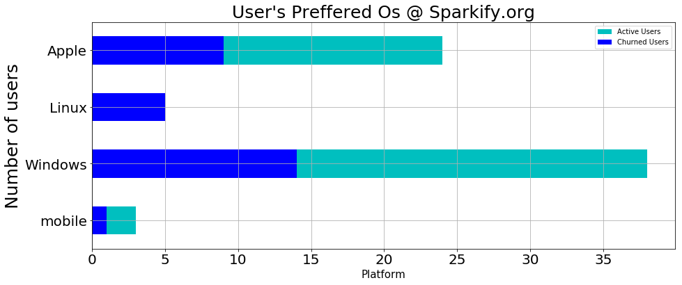

```python
plt.title('User\'s Preffered Os @ Sparkify.org', fontsize=25)
ax = df_os.iloc[1].plot(kind='barh', color ='c', figsize=(15, 6), legend=True, fontsize=25)
ax = df_os.iloc[0].plot(kind='barh', color ='b', legend=True, fontsize=20)
ax.set_xlabel("Platform", fontsize=15)
ax.set_ylabel("Number of users", fontsize=25)
plt.grid(True)
plt.show()
```

```python
df_clean
```

```
DataFrame[artist: string, auth: string, firstName: string, gender: string, itemInSession: int, lastName: string, length: double, level: string, location: string, method: string, page: string, registration: bigint, sessionId: int, song: string, status: int, ts: bigint, userAgent: string, userId: stri…
```

```python
df_clean.createOrReplaceTempView("user_log_table")
```

```python
# df_clean = df_clean.withColumn("hour", df_clean["hour"].cast(IntegerType()))
# df_clean = df_clean.withColumn("day", df_clean["day"].cast(IntegerType()))
# df_clean = df_clean.withColumn('weekDay', df_clean["weekDay"].cast(IntegerType()))
# df_clean = df_clean.withColumn("userId", df_clean["userId"].cast(IntegerType()))
df_clean = df_clean.withColumn("memberSince", df_clean["memberSince"].cast(IntegerType()))
```

```python
df_clean
```

[output not shown]

```python
df_clean.createOrReplaceTempView("user_log_table")
```

```python
df_clean.take(1)
```

```
[Row(artist=None, auth='Logged In', firstName='Darianna', gender='F', itemInSession=34, lastName='Carpenter', length=None, level='free', location='Bridgeport-Stamford-Norwalk, CT', method='PUT', page='Logout', registration=1538016340000, sessionId=187, song=None, status=307, ts=1542823952000, userAg…
```

```python
df_clean.toPandas().to_csv('dfCleanFINAL.csv')
```

[output not shown]

# Feature Engineering

Once you've familiarized yourself with the data, build out the features you find promising to train your model on. To work with the full dataset, you can follow the following steps.

- Write a script to extract the necessary features from the smaller subset of data
- Ensure that your script is scalable, using the best practices discussed in Lesson 3
- Try your script on the full data set, debugging your script if necessary

If you are working in the classroom workspace, you can just extract features based on the small subset of data contained here. Be sure to transfer over this work to the larger dataset when you work on your Spark cluster.

```python
featuresThatMatters = spark.sql(
      '''
      SELECT userId,
      MAX(Churn)                                                      AS label,
      COUNT(CASE WHEN page = 'Error'            THEN 1 ELSE null END) AS error_count,
      COUNT(CASE WHEN page = 'Add Friend'       THEN 1 ELSE null END) AS friends_count,
      COUNT(CASE when page = 'Roll Advert'      THEN 1 ELSE null END) AS advert_count,
      COUNT(CASE WHEN page = 'Add to Playlist'  THEN 1 ELSE null END) AS playlist_count,
      COUNT(CASE WHEN page = 'Thumbs Up'        THEN 1 ELSE null END) AS thumbs_up,
      COUNT(CASE WHEN page = 'Thumbs Down'      THEN 1 ELSE null END) AS thumbs_down,
      COUNT(CASE WHEN page = 'Downgrade'        THEN 1 ELSE null END) AS downgrade,
      COUNT(CASE WHEN page = 'Upgrade'          THEN 1 ELSE null END) AS upgrade,
      COUNT(CASE WHEN page = 'Submit Upgrade'   THEN 1 ELSE null END) AS submit_upgrade,
      COUNT(CASE WHEN page = 'Submit Downgrade' THEN 1 ELSE null END) AS submit_downgrade,

      INT  (Case WHEN FIRST (level) ='free' THEN True ELSE False END) AS FIRST_level_free,
      INT  (Case WHEN FIRST (level) ='paid' THEN True ELSE False END) AS FIRST_level_paid,
      INT  (Case WHEN LAST (level)  ='free' THEN True ELSE False END) AS LAST_level_free,
      INT  (Case WHEN LAST (level)  ='paid' THEN True ELSE False END) AS LAST_level_paid,


      SUM(downgrade_event)                                            AS phase,
      MAX(mobile_android_ios)                                         AS mobile,
      MAX(apple_mac)                                                  AS Apple_Mac,
      MAX(linux_debian)                                               AS Linux,
      MAX(windows_pc)                                                 AS Windows,
      AVG(hour)                                                       AS hour,
      AVG(day)                                                        AS day,
      AVG(weekDay)                                                    AS weekday,

      INT(MAX(CASE WHEN gender = 'F' THEN True ELSE False END))         AS female,
      INT(MAX(CASE WHEN state  = ' CA'       THEN True ELSE False END)) AS CA,
      INT(MAX(CASE WHEN state  = ' TX'       THEN True ELSE False END)) AS TX,
      INT(MAX(CASE WHEN state  = ' FL'       THEN True ELSE False END)) AS FL,
      INT(MAX(CASE WHEN state  = ' NY-NJ-PA' THEN True ELSE False END)) AS NY_NJ_PA,

      MAX (memberSince)                                          AS membership_days,
      COUNT(DISTINCT sessionId)                                         AS session_count,
      MAX(usrInteractions)                                              AS items_count,
      COUNT(CASE WHEN page = 'NextSong'         THEN 1 ELSE null END)   AS song_count,
      SUM(length/(60*60))                                               AS usage_hours

      FROM user_log_table
      GROUP BY userId
      '''
      )
```

```python
featuresThatMatters.createOrReplaceTempView('featuresThatMatters');
```

```python
featuresThatMatters = featuresThatMatters.na.drop()
```

```python
df_features = featuresThatMatters.toPandas()
df_features
```

|  | userId | label | error_count | friends_count | advert_count | playlist_count | thumbs_up | thumbs_down | downgrade | upgrade | ... | female | CA | TX | FL | NY_NJ_PA | membership_days | session_count | items_count | song_count | usage_hours |
| --- | --- | --- | --- | --- | --- | --- | --- | --- | --- | --- | --- | --- | --- | --- | --- | --- | --- | --- | --- | --- | --- |
| 0 | 148 | 0 | 0 | 7 | 32 | 5 | 28 | 3 | 0 | 3 | ... | 0 | 0 | 0 | 1 | 0 | 70 | 12 | 518 | 398 | 27.165795 |
| 1 | 65 | 0 | 0 | 53 | 8 | 68 | 111 | 17 | 20 | 3 | ... | 0 | 0 | 0 | 0 | 0 | 71 | 23 | 2544 | 2113 | 147.043863 |
| 2 | 100003 | 1 | 0 | 0 | 9 | 2 | 3 | 0 | 0 | 0 | ... | 1 | 0 | 0 | 1 | 0 | 22 | 2 | 78 | 51 | 3.418450 |
| 3 | 200021 | 1 | 1 | 19 | 11 | 30 | 55 | 35 | 26 | 3 | ... | 1 | 0 | 0 | 0 | 0 | 70 | 17 | 1502 | 1227 | 83.532820 |
| 4 | 300011 | 0 | 2 | 93 | 21 | 146 | 437 | 41 | 32 | 9 | ... | 1 | 0 | 0 | 0 | 1 | 61 | 76 | 5732 | 4619 | 319.344783 |
| 5 | 101 | 1 | 3 | 29 | 8 | 61 | 86 | 16 | 22 | 1 | ... | 0 | 0 | 0 | 0 | 0 | 53 | 10 | 2149 | 1797 | 124.295560 |
| 6 | 115 | 0 | 3 | 39 | 11 | 42 | 92 | 24 | 21 | 1 | ... | 1 | 1 | 0 | 0 | 0 | 74 | 10 | 2076 | 1737 | 119.846559 |
| 7 | 28 | 1 | 1 | 20 | 26 | 50 | 79 | 22 | 15 | 3 | ... | 1 | 0 | 0 | 0 | 0 | 44 | 21 | 1781 | 1457 | 101.344622 |
| 8 | 26 | 0 | 0 | 6 | 22 | 8 | 12 | 1 | 0 | 1 | ... | 0 | 1 | 0 | 0 | 0 | 77 | 8 | 337 | 255 | 18.121154 |
| 9 | 12 | 1 | 2 | 13 | 21 | 19 | 42 | 9 | 5 | 7 | ... | 1 | 1 | 0 | 0 | 0 | 73 | 9 | 1064 | 867 | 59.616812 |
| 10 | 91 | 0 | 3 | 42 | 5 | 64 | 124 | 24 | 22 | 1 | ... | 0 | 0 | 0 | 0 | 0 | 116 | 9 | 3014 | 2580 | 177.718467 |
| 11 | 22 | 0 | 0 | 3 | 4 | 0 | 3 | 0 | 0 | 0 | ... | 1 | 0 | 0 | 0 | 0 | 61 | 2 | 40 | 28 | 2.056617 |
| 12 | 122 | 1 | 0 | 1 | 2 | 1 | 3 | 1 | 0 | 2 | ... | 1 | 0 | 0 | 0 | 0 | 52 | 4 | 62 | 41 | 2.633921 |
| 13 | 93 | 0 | 0 | 13 | 43 | 17 | 35 | 4 | 3 | 3 | ... | 0 | 0 | 0 | 0 | 0 | 71 | 12 | 815 | 640 | 43.836661 |
| 14 | 300002 | 0 | 1 | 28 | 4 | 57 | 140 | 11 | 8 | 3 | ... | 1 | 1 | 0 | 0 | 0 | 124 | 18 | 1961 | 1610 | 111.696646 |
| 15 | 300024 | 0 | 0 | 2 | 0 | 2 | 6 | 0 | 0 | 0 | ... | 1 | 0 | 0 | 0 | 0 | 38 | 1 | 102 | 88 | 6.305179 |
| 16 | 47 | 0 | 0 | 0 | 15 | 3 | 10 | 2 | 0 | 0 | ... | 0 | 0 | 0 | 0 | 0 | 131 | 9 | 251 | 202 | 13.604996 |
| 17 | 100024 | 1 | 0 | 0 | 3 | 0 | 5 | 0 | 0 | 0 | ... | 0 | 0 | 0 | 0 | 1 | 27 | 1 | 36 | 22 | 1.433481 |
| 18 | 300014 | 0 | 1 | 3 | 0 | 10 | 27 | 8 | 3 | 1 | ... | 0 | 1 | 0 | 0 | 0 | 100 | 7 | 361 | 280 | 19.767011 |
| 19 | 100008 | 0 | 0 | 17 | 20 | 30 | 37 | 6 | 10 | 4 | ... | 1 | 1 | 0 | 0 | 0 | 68 | 6 | 940 | 772 | 53.165777 |
| 20 | 52 | 0 | 0 | 40 | 29 | 33 | 54 | 9 | 10 | 3 | ... | 1 | 0 | 0 | 0 | 0 | 102 | 15 | 1363 | 1086 | 74.285113 |
| 21 | 86 | 0 | 1 | 18 | 9 | 20 | 34 | 8 | 6 | 1 | ... | 0 | 0 | 0 | 1 | 0 | 135 | 10 | 818 | 650 | 44.426846 |
| 22 | 40 | 0 | 0 | 23 | 23 | 39 | 66 | 11 | 2 | 1 | ... | 1 | 0 | 1 | 0 | 0 | 78 | 17 | 1322 | 1078 | 72.162593 |
| 23 | 54 | 1 | 1 | 33 | 47 | 72 | 163 | 29 | 39 | 1 | ... | 1 | 0 | 0 | 0 | 0 | 110 | 37 | 3437 | 2841 | 197.595811 |
| 24 | 100011 | 1 | 0 | 0 | 2 | 2 | 0 | 1 | 0 | 0 | ... | 0 | 0 | 0 | 0 | 0 | 5 | 1 | 23 | 11 | 0.789361 |
| 25 | 19 | 0 | 0 | 4 | 0 | 8 | 5 | 2 | 2 | 0 | ... | 1 | 0 | 0 | 0 | 0 | 21 | 1 | 259 | 216 | 15.133593 |
| 26 | 41 | 0 | 1 | 36 | 1 | 61 | 76 | 10 | 23 | 0 | ... | 1 | 0 | 0 | 0 | 0 | 110 | 12 | 2220 | 1894 | 131.638914 |
| 27 | 200010 | 0 | 1 | 8 | 17 | 5 | 14 | 7 | 0 | 3 | ... | 1 | 0 | 0 | 0 | 0 | 38 | 6 | 317 | 237 | 16.882394 |
| 28 | 112 | 0 | 0 | 7 | 21 | 7 | 9 | 3 | 0 | 2 | ... | 0 | 0 | 0 | 0 | 0 | 87 | 10 | 292 | 215 | 14.739652 |
| 29 | 88 | 0 | 1 | 28 | 23 | 58 | 122 | 20 | 18 | 1 | ... | 1 | 0 | 0 | 0 | 0 | 76 | 26 | 2465 | 2045 | 142.839405 |
| ... | ... | ... | ... | ... | ... | ... | ... | ... | ... | ... | ... | ... | ... | ... | ... | ... | ... | ... | ... | ... | ... |
| 32 | 4 | 0 | 4 | 46 | 4 | 59 | 95 | 26 | 21 | 4 | ... | 0 | 0 | 0 | 0 | 0 | 62 | 22 | 2442 | 2048 | 140.594456 |
| 33 | 59 | 0 | 4 | 16 | 11 | 14 | 30 | 9 | 9 | 3 | ... | 0 | 0 | 0 | 0 | 0 | 64 | 7 | 872 | 724 | 50.120776 |
| 34 | 100 | 0 | 3 | 49 | 25 | 61 | 148 | 27 | 30 | 1 | ... | 0 | 0 | 1 | 0 | 0 | 64 | 35 | 3214 | 2682 | 186.910516 |
| 35 | 100002 | 0 | 0 | 1 | 3 | 5 | 5 | 0 | 2 | 0 | ... | 1 | 1 | 0 | 0 | 0 | 160 | 4 | 218 | 195 | 13.766644 |
| 36 | 7 | 0 | 1 | 1 | 16 | 5 | 7 | 1 | 0 | 2 | ... | 0 | 0 | 0 | 0 | 0 | 72 | 7 | 201 | 150 | 10.565024 |
| 37 | 200020 | 1 | 0 | 10 | 69 | 32 | 56 | 36 | 6 | 6 | ... | 0 | 0 | 0 | 1 | 0 | 75 | 36 | 1498 | 1169 | 80.544266 |
| 38 | 84 | 0 | 0 | 0 | 10 | 2 | 4 | 0 | 0 | 0 | ... | 1 | 0 | 0 | 0 | 0 | 52 | 3 | 97 | 73 | 5.030979 |
| 39 | 300003 | 0 | 0 | 0 | 2 | 1 | 2 | 0 | 0 | 0 | ... | 0 | 0 | 0 | 0 | 0 | 99 | 1 | 35 | 27 | 1.824410 |
| 40 | 300025 | 0 | 2 | 17 | 2 | 42 | 139 | 13 | 7 | 2 | ... | 0 | 1 | 0 | 0 | 0 | 76 | 16 | 1603 | 1297 | 88.420945 |
| 41 | 300016 | 0 | 1 | 11 | 2 | 26 | 56 | 4 | 5 | 1 | ... | 0 | 0 | 0 | 0 | 0 | 100 | 13 | 735 | 583 | 40.232387 |
| 42 | 200024 | 1 | 1 | 9 | 27 | 15 | 19 | 13 | 4 | 5 | ... | 0 | 0 | 0 | 0 | 0 | 28 | 8 | 552 | 417 | 28.742152 |
| 43 | 73 | 1 | 1 | 11 | 1 | 11 | 14 | 7 | 1 | 1 | ... | 1 | 0 | 0 | 0 | 0 | 49 | 6 | 457 | 377 | 26.177875 |
| 44 | 62 | 0 | 4 | 34 | 1 | 39 | 77 | 21 | 9 | 0 | ... | 0 | 0 | 1 | 0 | 0 | 134 | 8 | 1883 | 1591 | 109.760579 |
| 45 | 121 | 1 | 0 | 20 | 28 | 20 | 28 | 8 | 4 | 3 | ... | 0 | 1 | 0 | 0 | 0 | 131 | 13 | 916 | 726 | 49.744496 |
| 46 | 95 | 0 | 5 | 32 | 50 | 46 | 91 | 25 | 15 | 5 | ... | 1 | 0 | 0 | 0 | 0 | 62 | 33 | 2091 | 1694 | 118.648763 |
| 47 | 21 | 0 | 1 | 8 | 0 | 9 | 27 | 2 | 6 | 0 | ... | 0 | 0 | 0 | 0 | 0 | 68 | 4 | 589 | 499 | 33.570876 |
| 48 | 60 | 0 | 2 | 27 | 3 | 58 | 84 | 9 | 21 | 1 | ... | 0 | 0 | 0 | 0 | 0 | 71 | 18 | 1950 | 1644 | 114.533750 |
| 49 | 100022 | 1 | 1 | 11 | 115 | 14 | 45 | 20 | 0 | 7 | ... | 1 | 0 | 1 | 0 | 0 | 47 | 20 | 964 | 681 | 46.836740 |
| 50 | 109 | 0 | 0 | 12 | 7 | 16 | 23 | 5 | 12 | 3 | ... | 1 | 0 | 0 | 0 | 0 | 87 | 12 | 861 | 717 | 49.711373 |
| 51 | 300005 | 0 | 1 | 8 | 2 | 9 | 35 | 4 | 0 | 1 | ... | 1 | 0 | 0 | 0 | 0 | 157 | 6 | 394 | 312 | 21.395683 |
| 52 | 105 | 1 | 2 | 13 | 2 | 12 | 45 | 6 | 10 | 1 | ... | 0 | 0 | 0 | 0 | 0 | 29 | 5 | 918 | 764 | 53.985406 |
| 53 | 11 | 0 | 1 | 6 | 39 | 20 | 40 | 9 | 5 | 9 | ... | 1 | 0 | 0 | 0 | 0 | 124 | 16 | 848 | 647 | 44.352768 |
| 54 | 33 | 0 | 1 | 31 | 1 | 33 | 79 | 9 | 16 | 0 | ... | 0 | 0 | 0 | 0 | 0 | 162 | 12 | 1529 | 1257 | 86.308293 |
| 55 | 71 | 0 | 1 | 9 | 6 | 5 | 14 | 4 | 3 | 3 | ... | 0 | 0 | 0 | 1 | 0 | 52 | 4 | 329 | 264 | 18.191531 |
| 56 | 147 | 0 | 0 | 15 | 11 | 12 | 28 | 3 | 6 | 2 | ... | 0 | 0 | 0 | 0 | 0 | 68 | 10 | 672 | 547 | 37.881473 |
| 57 | 14 | 0 | 2 | 19 | 1 | 34 | 54 | 12 | 12 | 0 | ... | 0 | 0 | 0 | 0 | 0 | 132 | 11 | 1432 | 1230 | 84.660736 |
| 58 | 100004 | 0 | 2 | 19 | 86 | 23 | 35 | 11 | 10 | 8 | ... | 1 | 0 | 0 | 0 | 0 | 172 | 21 | 1245 | 942 | 64.300108 |
| 59 | 30 | 0 | 1 | 25 | 72 | 47 | 62 | 17 | 6 | 14 | ... | 0 | 1 | 0 | 0 | 0 | 63 | 32 | 1775 | 1417 | 99.946735 |
| 60 | 66 | 0 | 0 | 24 | 35 | 38 | 52 | 8 | 9 | 3 | ... | 1 | 1 | 0 | 0 | 0 | 125 | 21 | 1288 | 1045 | 72.368478 |
| 61 | 100019 | 1 | 0 | 2 | 11 | 2 | 1 | 1 | 0 | 0 | ... | 0 | 0 | 0 | 0 | 0 | 31 | 2 | 89 | 62 | 4.329186 |

62 rows × 34 columns

```python
df_features.describe()
```

|  | userId | label | error_count | friends_count | advert_count | playlist_count | thumbs_up | thumbs_down | downgrade | upgrade | ... | female | CA | TX | FL | NY_NJ_PA | membership_days | session_count | items_count | song_count | usage_hours |
| --- | --- | --- | --- | --- | --- | --- | --- | --- | --- | --- | --- | --- | --- | --- | --- | --- | --- | --- | --- | --- | --- |
| count | 62.000000 | 62.000000 | 62.000000 | 62.000000 | 62.000000 | 62.000000 | 62.000000 | 62.000000 | 62.000000 | 62.000000 | ... | 62.000000 | 62.000000 | 62.000000 | 62.000000 | 62.000000 | 62.000000 | 62.000000 | 62.000000 | 62.000000 | 62.000000 |
| mean | 64564.935484 | 0.274194 | 1.016129 | 17.500000 | 17.774194 | 26.935484 | 53.661290 | 10.467742 | 8.516129 | 2.419355 | ... | 0.483871 | 0.177419 | 0.064516 | 0.080645 | 0.032258 | 78.516129 | 13.048387 | 1145.048387 | 935.661290 | 64.672831 |
| std | 107249.803208 | 0.449749 | 1.234636 | 16.871501 | 22.392489 | 26.173363 | 64.653666 | 10.043704 | 9.399585 | 2.743388 | ... | 0.503819 | 0.385142 | 0.247676 | 0.274512 | 0.178127 | 38.981602 | 12.269417 | 1054.964477 | 873.323648 | 60.520979 |
| min | 4.000000 | 0.000000 | 0.000000 | 0.000000 | 0.000000 | 0.000000 | 0.000000 | 0.000000 | 0.000000 | 0.000000 | ... | 0.000000 | 0.000000 | 0.000000 | 0.000000 | 0.000000 | 5.000000 | 1.000000 | 23.000000 | 11.000000 | 0.789361 |
| 25% | 48.250000 | 0.000000 | 0.000000 | 6.000000 | 2.250000 | 7.250000 | 14.000000 | 2.250000 | 0.000000 | 0.250000 | ... | 0.000000 | 0.000000 | 0.000000 | 0.000000 | 0.000000 | 52.250000 | 6.000000 | 320.000000 | 248.250000 | 17.416127 |
| 50% | 97.500000 | 0.000000 | 1.000000 | 13.000000 | 10.500000 | 19.500000 | 36.000000 | 8.000000 | 6.000000 | 1.500000 | ... | 0.000000 | 0.000000 | 0.000000 | 0.000000 | 0.000000 | 71.000000 | 10.000000 | 894.000000 | 720.500000 | 49.727934 |
| 75% | 100010.250000 | 1.000000 | 1.000000 | 26.500000 | 23.000000 | 41.250000 | 76.750000 | 15.250000 | 12.000000 | 3.000000 | ... | 1.000000 | 0.000000 | 0.000000 | 0.000000 | 0.000000 | 101.500000 | 17.000000 | 1732.000000 | 1387.000000 | 97.065287 |
| max | 300025.000000 | 1.000000 | 5.000000 | 93.000000 | 115.000000 | 146.000000 | 437.000000 | 41.000000 | 39.000000 | 14.000000 | ... | 1.000000 | 1.000000 | 1.000000 | 1.000000 | 1.000000 | 172.000000 | 76.000000 | 5732.000000 | 4619.000000 | 319.344783 |

8 rows × 34 columns

# Modeling

Split the full dataset into train, test, and validation sets. Test out several of the machine learning methods you learned. Evaluate the accuracy of the various models, tuning parameters as necessary. Determine your winning model based on test accuracy and report results on the validation set. Since the churned users are a fairly small subset, I suggest using F1 score as the metric to optimize.

```python
from pyspark.ml import Pipeline
from pyspark.ml.regression import LinearRegression
from pyspark.ml.tuning import CrossValidator, ParamGridBuilder
from pyspark.ml.evaluation import MulticlassClassificationEvaluator
from pyspark.ml.feature import CountVectorizer, IDF, PCA, RegexTokenizer, VectorAssembler, Normalizer, StandardScaler
from pyspark.ml.classification import LogisticRegression, RandomForestClassifier, GBTClassifier, LinearSVC, NaiveBayes
```

## Splitting features into `train` & `test`

Let's split our data into training (70%) and test (30%) data

```python
train, test = featuresThatMatters.randomSplit([0.7, 0.3], seed=77)
```

```python
train
```

```
DataFrame[userId: int, label: int, error_count: bigint, friends_count: bigint, advert_count: bigint, playlist_count: bigint, thumbs_up: bigint, thumbs_down: bigint, downgrade: bigint, upgrade: bigint, submit_upgrade: bigint, submit_downgrade: bigint, FIRST_level_free: int, FIRST_level_paid: int, LAS…
```

```python
train.count()
```

```
51
```

```python
test
```

```
DataFrame[userId: int, label: int, error_count: bigint, friends_count: bigint, advert_count: bigint, playlist_count: bigint, thumbs_up: bigint, thumbs_down: bigint, downgrade: bigint, upgrade: bigint, submit_upgrade: bigint, submit_downgrade: bigint, FIRST_level_free: int, FIRST_level_paid: int, LAS…
```

```python
test.count()
```

```
11
```

## Assembling Feature Vector

- **Creating a vector from the combined columns of all of the features**
- Here, we use [VectorAssembler](https://spark.apache.org/docs/latest/api/python/reference/api/pyspark.ml.feature.VectorAssembler.html) is a transformer that converts a list of columns into one vector column. It is useful for integrating raw features and features generated by various feature transformers into a single feature vector for training machine learning models such as logistic regression and decision trees.
- VectorAssembler accepts the following column types:
  - numeric
  - boolean
  - vector
- Source: https://spark.apache.org/docs/latest/api/python/reference/api/pyspark.ml.feature.VectorAssembler.html

```python
assembler = VectorAssembler(inputCols=["userId",
                                       "error_count",
                                       "friends_count",
                                       "advert_count",
                                       "playlist_count",
                                       "thumbs_up",
                                       "thumbs_down",
                                       "downgrade",
                                       "upgrade",
                                       "submit_upgrade",
                                       "submit_downgrade",
                                       "FIRST_level_paid",
                                       "LAST_level_paid",
                                       "phase",
                                       "mobile",
                                       "Apple_Mac",
                                       "Linux",
                                       "Windows",
                                       "hour",
                                       "day",
                                       "weekday",
                                       "female",
                                       "CA",
                                       "TX",
                                       "FL",
                                       "NY_NJ_PA",
                                       "membership_days",
                                       "session_count",
                                       "items_count",
                                       "song_count",
                                       "usage_hours"],
                            outputCol="inFeatures")
```

## Vector Normalization

Normalize a vector to have unit norm using the given p-norm.

- Source: https://spark.apache.org/docs/latest/api/python/reference/api/pyspark.ml.feature.Normalizer.html

```python
scaler = Normalizer(inputCol="inFeatures", outputCol="features")
```

## Spark ML Pipelines

- Source: https://spark.apache.org/docs/latest/ml-classification-regression.html

```python
PIPELINES = ['RFC', 'GBTC', 'LSVM', 'LR']
F1_SCORE = []
ACCURACY = []
```

```python
df_pipeline = pd.DataFrame(columns=['RFC', 'GBTC', 'LSVM', 'LR'],
                  index=['F1_Score', 'Accuracy'])

df_pipeline
```

|  | RFC | GBTC | LSVM | LR |
| --- | --- | --- | --- | --- |
| F1_Score | NaN | NaN | NaN | NaN |
| Accuracy | NaN | NaN | NaN | NaN |

### Random Forest Classifier

```python
# Random Forest classifier
rfc           = RandomForestClassifier()
pipeline_rfc  = Pipeline(stages=[assembler, scaler, rfc])
```

```python
paramgrid_rfc = ParamGridBuilder()\
.build()

evaluator=MulticlassClassificationEvaluator(metricName="f1")

crossval= CrossValidator(estimator=pipeline_rfc,
                         estimatorParamMaps=paramgrid_rfc,
                         evaluator=evaluator,
                         numFolds=5)
```

```python
start = time.time()

cvModel_rfc = crossval.fit(train)

end = time.time()
print(f'Total time : {end-start} seconds')
```

```
Total time : 693.8746218681335 seconds
```

```python
results_rfc = cvModel_rfc.transform(test)
results_rfc
```

```
DataFrame[userId: int, label: int, error_count: bigint, friends_count: bigint, advert_count: bigint, playlist_count: bigint, thumbs_up: bigint, thumbs_down: bigint, downgrade: bigint, upgrade: bigint, submit_upgrade: bigint, submit_downgrade: bigint, FIRST_level_free: int, FIRST_level_paid: int, LAS…
```

```python
rfc_TP = (results_rfc.filter(results_rfc.label == results_rfc.prediction).count())
rfc_totalNoPredictions = (results_rfc.count())

print('Corrent predictions : ',rfc_TP)
print('Total Predictions: ',rfc_totalNoPredictions)
print('Accuracy: ',rfc_TP/rfc_totalNoPredictions)
```

```
Corrent predictions :  9
Total Predictions:  11
Accuracy:  0.8181818181818182
```

```python
# F1 Score
evaluator.evaluate(cvModel_rfc.transform(test))
```

```
0.8181818181818182
```

```python
df_pipeline.loc['Accuracy'][0] = rfc_TP/rfc_totalNoPredictions
df_pipeline.loc['F1_Score'][0] = evaluator.evaluate(cvModel_rfc.transform(test))
df_pipeline
```

|  | RFC | GBTC | LSVM | LR |
| --- | --- | --- | --- | --- |
| F1_Score | 0.818182 | NaN | NaN | NaN |
| Accuracy | 0.818182 | NaN | NaN | NaN |

### Gradient-Boosted Tree Classifier

```python
# Gradient-boosted Tree classifier
gbtc = GBTClassifier()
pipeline_gbtc = Pipeline(stages=[assembler, scaler, gbtc])
```

```python
paramgrid_gbtc =ParamGridBuilder()\
.build()

evaluator=MulticlassClassificationEvaluator(metricName="f1")

crossval= CrossValidator(estimator=pipeline_gbtc,
                         estimatorParamMaps=paramgrid_gbtc,
                         evaluator=evaluator,
                         numFolds=5)
```

```python
start = time.time()

cvModel_gbtc = crossval.fit(train)

end = time.time()
print(f'Total time : {end-start} seconds')
```

```
Total time : 1947.8351159095764 seconds
```

```python
results_gbtc = cvModel_gbtc.transform(test)
```

```python
gbtc_TP = (results_gbtc.filter(results_gbtc.label == results_gbtc.prediction).count())
gbtc_totalNoPredictions = (results_gbtc.count())
```

```python
print('Corrent predictions : ',gbtc_TP)
print('Total Predictions: ',gbtc_totalNoPredictions)
print('Accuracy: ',gbtc_TP/gbtc_totalNoPredictions)
```

```
Corrent predictions :  6
Total Predictions:  11
Accuracy:  0.5454545454545454
```

```python
# F1 Score
evaluator.evaluate(cvModel_gbtc.transform(test))
```

```
0.5974025974025975
```

```python
df_pipeline.loc['Accuracy'][1] = gbtc_TP/gbtc_totalNoPredictions
df_pipeline.loc['F1_Score'][1] = evaluator.evaluate(cvModel_gbtc.transform(test))
df_pipeline
```

|  | RFC | GBTC | LSVM | LR |
| --- | --- | --- | --- | --- |
| F1_Score | 0.818182 | 0.597403 | NaN | NaN |
| Accuracy | 0.818182 | 0.545455 | NaN | NaN |

### Logistic Regression

```python
lr =  LogisticRegression(maxIter=10, regParam=0.0, elasticNetParam=0)
pipeline_lr = Pipeline(stages=[assembler, scaler, lr ])
```

```python
paramgrid =ParamGridBuilder()\
.addGrid(lr.regParam, [0.0, 0,1])\
.addGrid(lr.maxIter, [10])\
.build()


evaluator=MulticlassClassificationEvaluator(metricName="f1")

crossval= CrossValidator(estimator=pipeline_lr,
                         estimatorParamMaps=paramgrid,
                         evaluator = evaluator ,
                         numFolds=5)
```

```python
start = time.time()

# Fit the logistic regression cross validation model
cvModel_lr = crossval.fit(train)

end = time.time()
print(f'Total time : {end-start} seconds')
```

```
Total time : 811.7578961849213 seconds
```

```python
cvModel_lr.avgMetrics
```

```
[0.6115462315462314, 0.6115462315462314, 0.6266581784228843]
```

```python
results_lr = cvModel_lr.transform(test)
```

```python
lr_TP = (results_lr.filter(results_lr.label == results_lr.prediction).count())
lr_totalNoPredictions = (results_lr.count())
```

```python
print('Corrent predictions : ',lr_TP)
print('Total Predictions: ',lr_totalNoPredictions)
print('Accuracy: ',lr_TP/lr_totalNoPredictions)
```

```
Corrent predictions :  9
Total Predictions:  11
Accuracy:  0.8181818181818182
```

```python
evaluator.evaluate(cvModel_lr.transform(test))
```

```
0.7363636363636363
```

```python
df_pipeline.loc['Accuracy'][3] = lr_TP/gbtc_totalNoPredictions
df_pipeline.loc['F1_Score'][3] = evaluator.evaluate(cvModel_lr.transform(test))
df_pipeline
```

|  | RFC | GBTC | LSVM | LR |
| --- | --- | --- | --- | --- |
| F1_Score | 0.818182 | 0.597403 | NaN | 0.736364 |
| Accuracy | 0.818182 | 0.545455 | NaN | 0.818182 |

### Linear Support Vector Machine (SVM)

```python
lsvm = LinearSVC()
pipeline_lsvm = Pipeline(stages=[assembler, scaler, lsvm])
```

```python
paramgrid_lsvm =ParamGridBuilder()\
.build()

evaluator=MulticlassClassificationEvaluator(metricName="f1")

crossval= CrossValidator(estimator=pipeline_lsvm,
                         estimatorParamMaps=paramgrid_lsvm,
                         evaluator=evaluator,
                         numFolds=5)
```

```python
start = time.time()

cvModel_lsvm=crossval.fit(train)

end = time.time()
print(f'Total time : {end-start} seconds')
```

```
Total time : 4523.459923744202 seconds
```

```python
results_lsvm = cvModel_lsvm.transform(test)
```

```python
lsvm_TP = (results_lsvm.filter(results_lsvm.label == results_lsvm.prediction).count())
lsvm_totalNoPredictions = (results_lsvm.count())
```

```python
print('Corrent predictions : ',lsvm_TP)
print('Total Predictions: ',lsvm_totalNoPredictions)
print('Accuracy: ',lsvm_TP/lsvm_totalNoPredictions)
```

```
Corrent predictions :  6
Total Predictions:  11
Accuracy:  0.5454545454545454
```

```python
evaluator.evaluate(cvModel_lsvm.transform(test))
```

```
0.5775401069518717
```

```python
df_pipeline.loc['Accuracy'][2] = lsvm_TP/gbtc_totalNoPredictions
df_pipeline.loc['F1_Score'][2] = evaluator.evaluate(cvModel_lsvm.transform(test))
df_pipeline
```

|  | RFC | GBTC | LSVM | LR |
| --- | --- | --- | --- | --- |
| F1_Score | 0.818182 | 0.597403 | 0.57754 | 0.736364 |
| Accuracy | 0.818182 | 0.545455 | 0.545455 | 0.818182 |

## Visualization

```python
df_pipeline.columns
```

```
Index(['RFC', 'GBTC', 'LSVM', 'LR'], dtype='object')
```

```python
df_metric = pd.DataFrame({'F1_Score': [0.818182, 0.597403, 0.57754, 0.736364],
                 'Accuracy': [0.818182, 0.545455, 0.545455, 0.818182]},
                  index=list(df_pipeline.columns))
```

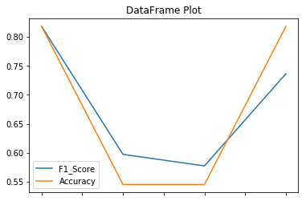

```python
plot = df_metric.plot(title="DataFrame Plot")
```

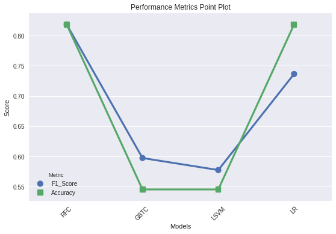

```python
df_pipeline = pd.DataFrame({
    'F1_Score': [0.818182, 0.597403, 0.57754, 0.736364],
    'Accuracy': [0.818182, 0.545455, 0.545455, 0.818182]
}, index=['RFC', 'GBTC', 'LSVM', 'LR'])

fig = plt.figure(figsize=(15, 10))

plt.subplot(2, 2, 3)
df_melted = df_pipeline.reset_index().melt(id_vars=['index'], var_name='Metric', value_name='Score')
sns.pointplot(data=df_melted, x='index', y='Score', hue='Metric', markers=['o', 's'])
plt.title('Performance Metrics Point Plot')
plt.xlabel('Models')
plt.ylabel('Score')
plt.xticks(rotation=45)
plt.tight_layout()
plt.show()
```

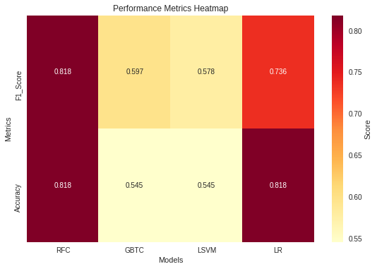

```python
fig = plt.figure(figsize=(15, 10))

plt.subplot(2, 2, 2)
sns.heatmap(df_pipeline.T, annot=True, cmap='YlOrRd', fmt='.3f', cbar_kws={'label': 'Score'})
plt.title('Performance Metrics Heatmap')
plt.xlabel('Models')
plt.ylabel('Metrics')
plt.tight_layout()
plt.show()
```

[figure not shown]

```python
df_metric = pd.DataFrame({
    'F1_Score': [0.818182, 0.597403, 0.57754, 0.736364],
    'Accuracy': [0.818182, 0.545455, 0.545455, 0.818182]
}, index=['RFC', 'GBTC', 'LSVM', 'LR'])

# Set style and figure size
plt.style.use('seaborn')
fig, (ax1, ax2) = plt.subplots(1, 2, figsize=(15, 6))

# Bar Plot
df_metric.plot(kind='bar', ax=ax1, width=0.8)
ax1.set_title('Model Performance Comparison (Bar Plot)')
ax1.set_xlabel('Models')
ax1.set_ylabel('Score')
ax1.legend(title='Metrics')
ax1.grid(True, alpha=0.5)
ax1.set_xticklabels(df_metric.index, rotation=45)

plt.tight_layout()
plt.show()
```

# Conclusion

Based on the `df_pipeline` and visuals the winning models for churn prediction are

- Logistic Regression Model
- Random Classifier Model (*check)

# Final Steps

Clean up your code, adding comments and renaming variables to make the code easier to read and maintain. Refer to the Spark Project Overview page and Data Scientist Capstone Project Rubric to make sure you are including all components of the capstone project and meet all expectations. Remember, this includes thorough documentation in a README file in a Github repository, as well as a web app or blog post.

# Refrences

1. https://spark.apache.org/docs/latest/sql-getting-started.html
2. https://docs.databricks.com/en/udf/python.html
3. https://www.dataquest.io/blog/tutorial-lambda-functions-in-python/
4. https://spark.apache.org/sql/
5. https://peterschuld.medium.com/sparkify-project-45d8941fa995
6. https://docs.python.org/3/library/datetime.html#strftime-strptime-behavior
7. https://stackoverflow.com/questions/48738354/having-troubles-joining-3-dataframes-pyspark
8. https://github.com/PeterSchuld/Sparkify
9. https://stackoverflow.com/questions/59886143/spark-dataframe-how-to-keep-only-latest-record-for-each-group-based-on-id-and
10. https://stackoverflow.com/questions/46956026/how-to-convert-column-with-string-type-to-int-form-in-pyspark-data-frame
11. https://medium.com/swlh/logistic-regression-with-pyspark-60295d41221
12. https://towardsdatascience.com/machine-learning-with-pyspark-and-mllib-solving-a-binary-classification-problem-96396065d2aa
13. https://spark.apache.org/docs/latest/ml-classification-regression.html#logistic-regression
14. https://stackoverflow.com/questions/60772315/how-to-evaluate-a-classifier-with-apache-spark-2-4-5-and-pyspark-python
15. https://spark.apache.org/docs/2.2.0/ml-classification-regression.html
16. https://scikit-learn.org/stable/modules/generated/sklearn.preprocessing.StandardScaler.html
17. https://stackoverflow.com/questions/32565829/simple-way-to-measure-cell-execution-time-in-ipython-notebook
18. https://www.silect.is/blog/random-forest-models-in-spark-ml/
19. https://stackoverflow.com/questions/75440/how-do-i-get-the-string-with-name-of-a-class